# Honors Thesis

Dhanesha Mirpuri

May 2022

```r
library("tidyverse")
library("AER")
library("lmtest")
library("sandwich")
library("ggplot2")
library("stargazer")
```

```r
data = read.table("/Users/dhaneshamirpuri/Documents/maindata6.csv", header = TRUE, fill = TRUE, sep = ',')
```

cleaning the dataset: - changing everything necessary to numerics - replacing N/A’s with 0’s

```r
data$etrincometaxespretaxincome[is.na(data$etrincometaxespretaxincome)] = 0
data$etrincometaxespretaxincome[data$etrincometaxespretaxincome == "#DIV/0!"] = 0
data$etrincometaxespretaxincome[is.na(data$etrincometaxespretaxincome)] = 0
data$etrincometaxespretaxincome = as.numeric(data$etrincometaxespretaxincome)
data$spending_on_tax = as.numeric(data$spending_on_tax)
data$totalassets = as.numeric(data$totalassets)
data$numberofemployees = as.numeric(data$numberofemployees)
data$totaldebt = as.numeric(data$totaldebt)
data$totalinventory = as.numeric(data$totalinventory)
data$pretaxincome = as.numeric(data$pretaxincome)
data$incometaxes = as.numeric(data$incometaxes)
data$propertyplantandequitment = as.numeric(data$propertyplantandequitment)
data$rateofassets = as.numeric(data$rateofassets)
data$researchanddevelopmentexpenses = as.numeric(data$researchanddevelopmentexpenses)
data$leverageratiooftotaldebttototala = as.numeric(data$leverageratiooftotaldebttototala)
data$capitalintensityratioofpropertyp = as.numeric(data$capitalintensityratioofpropertyp)
data$inventoryintensityratioofinvento = as.numeric(data$inventoryintensityratioofinvento)
data$totspending = as.numeric(data$totspending)
data
```

| gvkey | ticker | year | firmname | sector | industry | v6 | cusip | totalassets | totaldebt | numberofemployees | totalinventory | pretaxincome | propertyplantandequitment | incometaxes | researchanddevelopmentexpenses | etrincometaxespretaxincome | leverageratiooftotaldebttototala | capitalintensityratioofpropertyp | inventoryintensityratioofinvento | firm | bvdid | primary_naics | totspending | numissue | numtax | taxratio | spending_on_tax | anylob | rateofassets |
| --- | --- | --- | --- | --- | --- | --- | --- | --- | --- | --- | --- | --- | --- | --- | --- | --- | --- | --- | --- | --- | --- | --- | --- | --- | --- | --- | --- | --- | --- |
| 1045 | AAL | 2016 | American Airlines Group Inc | Transports | Airlines & Air Services | AAL | 02376R102 | 51274.000 | 24344.000 | 122.300 | 1094.000 | 4299.000 | 31159.000 | 1623.000 | 0.000 | 0.377529658 | 2.133635e-02 | 0.607695908 | 2.133635e-02 | AMERICAN AIRLINES | US131502798 | 481111 | 11100000 | 127 | 0 | 0.0944882 | 1045039.000 | 1 | 0.083843663 |
| 1045 | AAL | 2017 | American Airlines Group Inc | Transports | Airlines & Air Services | AAL | 02376R102 | 51396.000 | 25065.000 | 126.600 | 1359.000 | 3084.000 | 34156.000 | 1165.000 | NA | 0.377756161 | 2.644175e-02 | 0.664565336 | 2.644175e-02 | AMERICAN AIRLINES | US131502798 | 481111 | 10700000 | 138 | 0 | 0.1666667 | 1790333.000 | 1 | 0.060004670 |
| 1045 | AAL | 2018 | American Airlines Group Inc | Transports | Airlines & Air Services | AAL | 02376R102 | 60580.000 | 34029.000 | 128.900 | 1522.000 | 1884.000 | 43249.000 | 472.000 | NA | 0.250530786 | 2.512380e-02 | 0.713915484 | 2.512380e-02 | AMERICAN AIRLINES | US131502798 | 481111 | 8929000 | 95 | 0 | 0.1368421 | 1221863.000 | 1 | 0.031099373 |
| 1045 | AAL | 2019 | American Airlines Group Inc | Transports | Airlines & Air Services | AAL | 02376R102 | 59995.000 | 33444.000 | 133.700 | 1851.000 | 2256.000 | 43732.000 | 570.000 | NA | 0.252659575 | 3.085257e-02 | NA | 3.085257e-02 | AMERICAN AIRLINES | US131502798 | 481111 | 8682000 | 97 | 0 | 0.0515464 | 447525.800 | 1 | 0.037603134 |
| 1075 | PNW | 2000 | Pinnacle West Capital Corp | Utilities and Telecommunications | Utilities - Electric | PNW | 723484101 | 7149.151 | 0.000 | 7.200 | 91.371 | 526.184 | 5133.193 | 223.852 | 0.000 | 0.425425327 | 1.278068e-02 | 0.718014349 | 1.278068e-02 | PINNACLE WEST CAPITAL CORPORATION | US860512431 | 2211 | 1000000 | 21 | 0 | 0.1428571 | 142857.200 | 1 | 0.074000000 |
| 1075 | PNW | 2001 | Pinnacle West Capital Corp | Utilities and Telecommunications | Utilities - Electric | PNW | 723484101 | 7981.748 | NA | 7.600 | 108.238 | 540.902 | 5907.315 | 213.535 | NA | 0.394775763 | 1.356069e-02 | 0.740102920 | 1.356069e-02 | PINNACLE WEST CAPITAL CORPORATION | US860512431 | 2211 | 740000 | 20 | 0 | 0.1 | 74000.000 | 1 | 0.068000000 |
| 1075 | PNW | 2002 | Pinnacle West Capital Corp | Utilities and Telecommunications | Utilities - Electric | PNW | 723484101 | 8425.806 | NA | 7.200 | 119.837 | 353.253 | 6369.583 | 138.100 | NA | 0.390937940 | 1.422262e-02 | 0.755961270 | 1.422262e-02 | PINNACLE WEST CAPITAL CORPORATION | US860512431 | 2211 | 1400000 | 38 | 0 | 0.0789474 | 110526.300 | 1 | 0.042000000 |
| 1075 | PNW | 2003 | Pinnacle West Capital Corp | Utilities and Telecommunications | Utilities - Electric | PNW | 723484101 | 9536.378 | NA | 7.200 | 124.466 | 336.136 | 7371.556 | 105.560 | NA | 0.314039555 | 1.305171e-02 | 0.772993269 | 1.305171e-02 | PINNACLE WEST CAPITAL CORPORATION | US860512431 | 2211 | 1600000 | 27 | 0 | 0.0740741 | 118518.500 | 1 | 0.035000000 |
| 1075 | PNW | 2004 | Pinnacle West Capital Corp | Utilities and Telecommunications | Utilities - Electric | PNW | 723484101 | 9896.747 | NA | 7.200 | 121.845 | 364.075 | 7430.001 | 128.857 | NA | 0.353929822 | 1.231162e-02 | 0.750751838 | 1.231162e-02 | PINNACLE WEST CAPITAL CORPORATION | US860512431 | 2211 | 1880000 | 25 | 0 | 0.08 | 150400.000 | 1 | 0.037000000 |
| 1075 | PNW | 2005 | Pinnacle West Capital Corp | Utilities and Telecommunications | Utilities - Electric | PNW | 723484101 | 11322.640 | NA | 7.300 | 133.394 | 350.055 | 7486.167 | 126.892 | NA | 0.362491609 | 1.178117e-02 | 0.661167687 | 1.178117e-02 | PINNACLE WEST CAPITAL CORPORATION | US860512431 | 2211 | 1960000 | 24 | 1 | 0.0833333 | 163333.300 | 1 | 0.030916376 |

[output cut: 990 more lines]

```r
NA
```

changing names of variables to make it easier

#why didnt this work - i have to repeat for every data set??

```r
etr = data$etrincometaxespretaxincome
taxlob = data$spending_on_tax
lob = data$totspending
assets = data$totalassets
emp = data$numberofemployees
debt = data$totaldebt
invt = data$totalassets
pretax = data$pretaxincome
inctax = data$incometaxes
ppe = data$propertyplantandequitment
roa = data$rateofassets
rd = data$researchanddevelopmentexpenses
levrat = data$leverageratiooftotaldebttototala
caprat = data$capitalintensityratioofpropertyp
invrat = data$inventoryintensityratioofinvento
```

after using histograms to check for outliers, dropping values that are less than -1 and greater than 1 for etr

```r
data2 = filter(data, etr <= 1 & etr >= -1)
data2
```

| gvkey | ticker | year | firmname | sector | industry | v6 | cusip | totalassets | totaldebt | numberofemployees | totalinventory | pretaxincome | propertyplantandequitment | incometaxes | researchanddevelopmentexpenses | etrincometaxespretaxincome | leverageratiooftotaldebttototala | capitalintensityratioofpropertyp | inventoryintensityratioofinvento | firm | bvdid | primary_naics | totspending | numissue | numtax | taxratio | spending_on_tax | anylob | rateofassets |
| --- | --- | --- | --- | --- | --- | --- | --- | --- | --- | --- | --- | --- | --- | --- | --- | --- | --- | --- | --- | --- | --- | --- | --- | --- | --- | --- | --- | --- | --- |
| 1045 | AAL | 2016 | American Airlines Group Inc | Transports | Airlines & Air Services | AAL | 02376R102 | 51274.000 | 24344.000 | 122.300 | 1094.000 | 4299.000 | 31159.000 | 1623.000 | 0.000 | 0.377529658 | 2.133635e-02 | 0.607695908 | 2.133635e-02 | AMERICAN AIRLINES | US131502798 | 481111 | 11100000 | 127 | 0 | 0.0944882 | 1045039.000 | 1 | 0.083843663 |
| 1045 | AAL | 2017 | American Airlines Group Inc | Transports | Airlines & Air Services | AAL | 02376R102 | 51396.000 | 25065.000 | 126.600 | 1359.000 | 3084.000 | 34156.000 | 1165.000 | NA | 0.377756161 | 2.644175e-02 | 0.664565336 | 2.644175e-02 | AMERICAN AIRLINES | US131502798 | 481111 | 10700000 | 138 | 0 | 0.1666667 | 1790333.000 | 1 | 0.060004670 |
| 1045 | AAL | 2018 | American Airlines Group Inc | Transports | Airlines & Air Services | AAL | 02376R102 | 60580.000 | 34029.000 | 128.900 | 1522.000 | 1884.000 | 43249.000 | 472.000 | NA | 0.250530786 | 2.512380e-02 | 0.713915484 | 2.512380e-02 | AMERICAN AIRLINES | US131502798 | 481111 | 8929000 | 95 | 0 | 0.1368421 | 1221863.000 | 1 | 0.031099373 |
| 1045 | AAL | 2019 | American Airlines Group Inc | Transports | Airlines & Air Services | AAL | 02376R102 | 59995.000 | 33444.000 | 133.700 | 1851.000 | 2256.000 | 43732.000 | 570.000 | NA | 0.252659575 | 3.085257e-02 | NA | 3.085257e-02 | AMERICAN AIRLINES | US131502798 | 481111 | 8682000 | 97 | 0 | 0.0515464 | 447525.800 | 1 | 0.037603134 |
| 1075 | PNW | 2000 | Pinnacle West Capital Corp | Utilities and Telecommunications | Utilities - Electric | PNW | 723484101 | 7149.151 | 0.000 | 7.200 | 91.371 | 526.184 | 5133.193 | 223.852 | 0.000 | 0.425425327 | 1.278068e-02 | 0.718014349 | 1.278068e-02 | PINNACLE WEST CAPITAL CORPORATION | US860512431 | 2211 | 1000000 | 21 | 0 | 0.1428571 | 142857.200 | 1 | 0.074000000 |
| 1075 | PNW | 2001 | Pinnacle West Capital Corp | Utilities and Telecommunications | Utilities - Electric | PNW | 723484101 | 7981.748 | NA | 7.600 | 108.238 | 540.902 | 5907.315 | 213.535 | NA | 0.394775763 | 1.356069e-02 | 0.740102920 | 1.356069e-02 | PINNACLE WEST CAPITAL CORPORATION | US860512431 | 2211 | 740000 | 20 | 0 | 0.1 | 74000.000 | 1 | 0.068000000 |
| 1075 | PNW | 2002 | Pinnacle West Capital Corp | Utilities and Telecommunications | Utilities - Electric | PNW | 723484101 | 8425.806 | NA | 7.200 | 119.837 | 353.253 | 6369.583 | 138.100 | NA | 0.390937940 | 1.422262e-02 | 0.755961270 | 1.422262e-02 | PINNACLE WEST CAPITAL CORPORATION | US860512431 | 2211 | 1400000 | 38 | 0 | 0.0789474 | 110526.300 | 1 | 0.042000000 |
| 1075 | PNW | 2003 | Pinnacle West Capital Corp | Utilities and Telecommunications | Utilities - Electric | PNW | 723484101 | 9536.378 | NA | 7.200 | 124.466 | 336.136 | 7371.556 | 105.560 | NA | 0.314039555 | 1.305171e-02 | 0.772993269 | 1.305171e-02 | PINNACLE WEST CAPITAL CORPORATION | US860512431 | 2211 | 1600000 | 27 | 0 | 0.0740741 | 118518.500 | 1 | 0.035000000 |
| 1075 | PNW | 2004 | Pinnacle West Capital Corp | Utilities and Telecommunications | Utilities - Electric | PNW | 723484101 | 9896.747 | NA | 7.200 | 121.845 | 364.075 | 7430.001 | 128.857 | NA | 0.353929822 | 1.231162e-02 | 0.750751838 | 1.231162e-02 | PINNACLE WEST CAPITAL CORPORATION | US860512431 | 2211 | 1880000 | 25 | 0 | 0.08 | 150400.000 | 1 | 0.037000000 |
| 1075 | PNW | 2005 | Pinnacle West Capital Corp | Utilities and Telecommunications | Utilities - Electric | PNW | 723484101 | 11322.640 | NA | 7.300 | 133.394 | 350.055 | 7486.167 | 126.892 | NA | 0.362491609 | 1.178117e-02 | 0.661167687 | 1.178117e-02 | PINNACLE WEST CAPITAL CORPORATION | US860512431 | 2211 | 1960000 | 24 | 1 | 0.0833333 | 163333.300 | 1 | 0.030916376 |

[output cut: 990 more lines]

```r
etr2 = data2$etr*100
etrhist = hist(etr2, main = "Effective Tax Rate", xlab = "Effective Tax Rate (%)", breaks = 20, na.rm = TRUE)
```

[output not shown]

testing if its skewed distribution

```r
median(data2$totspending, na.rm = TRUE)
```

```
[1] 501500
```

```r
mean(data2$totspending, na.rm = TRUE)
```

```
[1] 2347904
```

```r
sqrt(var(data2$totspending, na.rm = TRUE))
```

```
[1] 9271470
```

Histograms to see distributions

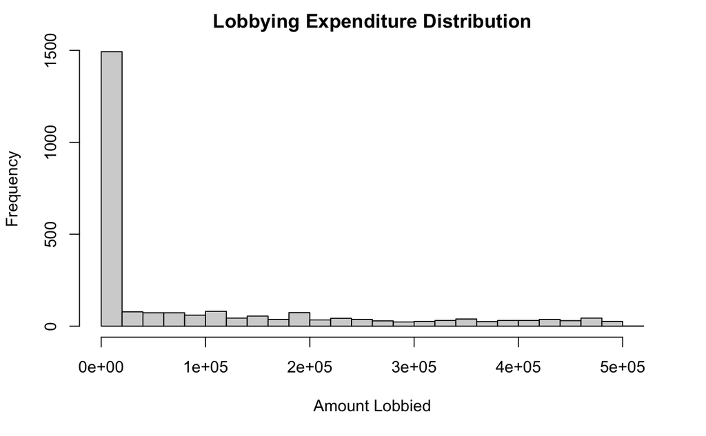

```r
dT1 = filter(data2, totspending <= 501500)
dT2 = filter(data2, totspending > 501500)
totlobbying1 = hist(dT1$totspending, main = "Lobbying Expenditure Distribution", xlab = "Amount Lobbied", breaks = 20, na.rm = TRUE)
```

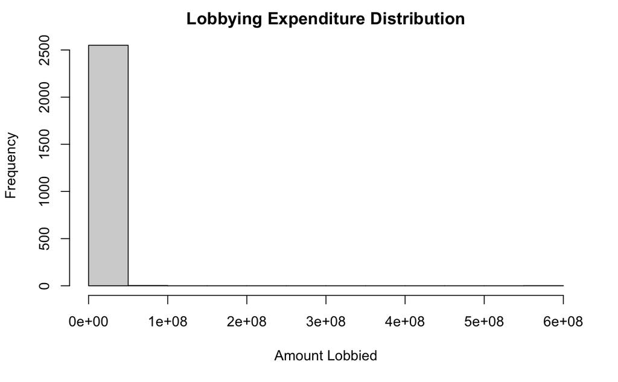

```r
totlobbying2 = hist(dT2$totspending, main = "Lobbying Expenditure Distribution", xlab = "Amount Lobbied", breaks = 20, na.rm = TRUE)
```

```r
dT1 = filter(data2, totspending >=1 & totspending <= 100000)
dT2 = filter(data2, totspending >= 10001 & totspending <= 30000)
dT3 = filter(data2, totspending >= 30001 & totspending <= 50000)
dT4 = filter(data2, totspending >= 50001 & totspending <= 70000)
dT5 = filter(data2, totspending >= 70001 & totspending <= 1000000)
dT6 = filter(data2, totspending >= 1000001 & totspending <= 25000000)
dT7 = filter(data2, totspending >= 25000001 & totspending <= 300000000)
dT8 = filter(data2, totspending >= 300000000)
dT_no_1 = filter(data2, totspending >=1 & totspending <= 2500000)

d_with_zero = filter(data2, totspending <2500000)
d_without_zero = filter(data2, totspending >=1 & totspending <= 2500000)
```

Histograms

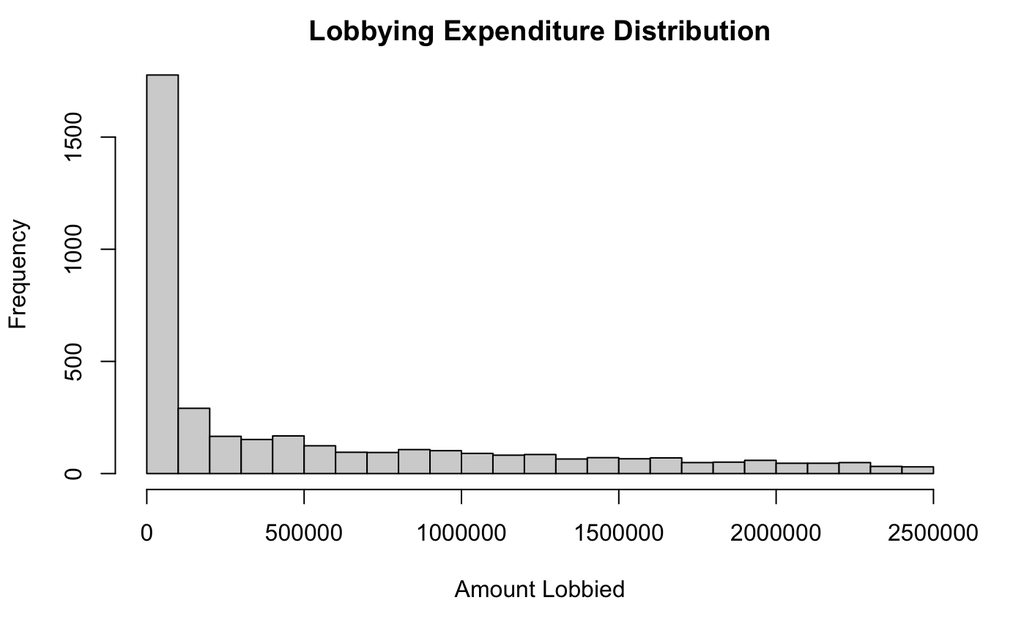

```r
totlobbying = hist(d_with_zero$totspending, main = "Lobbying Expenditure Distribution", xlab = "Amount Lobbied", frequency = TRUE, breaks = 20, na.rm = TRUE)
```

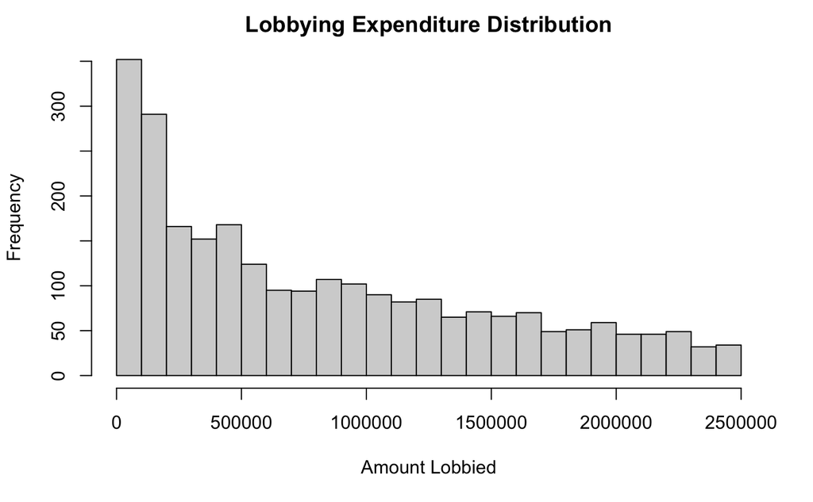

```r
totlobbying2 = hist(d_without_zero$totspending, main = "Lobbying Expenditure Distribution", xlab = "Amount Lobbied", frequency = TRUE, breaks = 20, na.rm = TRUE)
```

```r
d_with_zero$year = as.numeric(d_with_zero$year)
d_without_zero$year = as.numeric(d_without_zero$year)
```

Filtering data by years (entire dataset)

```r
d2000 = filter(d_with_zero, year == 2000)
d2001 = filter(d_with_zero, year == 2001)
d2002 = filter(d_with_zero, year == 2002)
d2003 = filter(d_with_zero, year == 2003)
d2004 = filter(d_with_zero, year == 2004)
d2005 = filter(d_with_zero, year == 2005)
d2006 = filter(d_with_zero, year == 2006)
d2007 = filter(d_with_zero, year == 2007)
d2008 = filter(d_with_zero, year == 2008)
d2009 = filter(d_with_zero, year == 2009)
d2010 = filter(d_with_zero, year == 2010)
d2011 = filter(d_with_zero, year == 2011)
d2012 = filter(d_with_zero, year == 2012)
d2013 = filter(d_with_zero, year == 2013)
d2014 = filter(d_with_zero, year == 2014)
d2015 = filter(d_with_zero, year == 2015)
d2016 = filter(d_with_zero, year == 2016)
d2017 = filter(d_with_zero, year == 2017)
d2018 = filter(d_with_zero, year == 2018)
d2019 = filter(d_with_zero, year == 2019)

avglist = list(
  mean(d2000$totspending, na.rm= TRUE),
  mean(d2001$totspending, na.rm= TRUE),
  mean(d2002$totspending, na.rm= TRUE),
  mean(d2003$totspending, na.rm= TRUE),
  mean(d2004$totspending, na.rm= TRUE),
  mean(d2005$totspending, na.rm= TRUE),
  mean(d2006$totspending, na.rm= TRUE),
  mean(d2007$totspending, na.rm= TRUE),
  mean(d2008$totspending, na.rm= TRUE),
  mean(d2008$totspending, na.rm= TRUE),
  mean(d2010$totspending, na.rm= TRUE),
  mean(d2011$totspending, na.rm= TRUE),
  mean(d2012$totspending, na.rm= TRUE),
  mean(d2013$totspending, na.rm= TRUE),
  mean(d2014$totspending, na.rm= TRUE),
  mean(d2015$totspending, na.rm= TRUE),
  mean(d2016$totspending, na.rm= TRUE),
  mean(d2017$totspending, na.rm= TRUE),
  mean(d2018$totspending, na.rm= TRUE),
  mean(d2019$totspending, na.rm= TRUE))

avglist = as.numeric(avglist)
avglist
```

```
 [1] 370478.1 369154.5 393274.1 451576.0 475414.9 501718.9
 [7] 498648.7 557017.7 521722.5 521722.5 594606.5 559692.3
[13] 622849.1 592259.3 582703.8 568602.1 546937.6 560540.8
[19] 563954.8 811714.0
```

Descriptive statistics

```r
stargazer(d, type = "text", title="Descriptive statistics", digits=1, out="table1.txt")
```

```
Descriptive statistics
=======================================================================================
Statistic                          N      Mean      St. Dev.      Min          Max
---------------------------------------------------------------------------------------
totalassets                      5,112  58,621.0    181,647.7     20.6     2,622,532.0
totaldebt                        4,596  11,315.5    43,028.0      0.0       722,513.0
numberofemployees                5,082    117.1      3,285.4      0.0       220,000.0
totalinventory                   5,015   3,854.7    23,886.1      0.0       393,925.0
pretaxincome                     5,116   2,499.3     6,132.5   -108,761.0   78,726.0
propertyplantandequitment        4,991   8,265.1    19,495.5      0.0       252,668.0
incometaxes                      5,115    728.0      1,967.8   -21,515.0    31,051.0
researchanddevelopmentexpenses   2,950    853.2      1,918.1      0.0       28,837.0
etrincometaxespretaxincome       5,116     0.3         0.2        -1.0         1.0
leverageratiooftotaldebttototala 5,112     0.1         0.1        0.0          0.8
capitalintensityratioofpropertyp 4,882     0.2         0.2        0.0          0.9
inventoryintensityratioofinvento 5,102     0.1         0.1        0.0          0.8
totspending                      5,109 2,347,904.0 9,271,470.0    0.0     580,135,101.0
spending_on_tax                  5,113  290,765.5   652,311.4     0.0     10,800,000.0
rateofassets                     5,112     6.4        313.3       -3.0      21,257.6
---------------------------------------------------------------------------------------
```

```r
stargazer(d_with_zero, type = "text", title="Descriptive statistics", digits=1, out="table1.txt")
```

```
Descriptive statistics
================================================================================
Statistic                          N     Mean    St. Dev.     Min        Max
--------------------------------------------------------------------------------
year                             3,958  2,009.3     5.5      2,000      2,019
totalassets                      3,966 27,770.0  57,661.6    20.6     847,585.0
totaldebt                        3,513  4,232.0   7,932.6     0.0     131,198.0
numberofemployees                3,942   40.1      73.7       0.0      1,500.0
totalinventory                   3,886  1,354.1   4,922.1     0.0     173,388.0
pretaxincome                     3,967  1,254.6   2,306.6  -28,226.0  34,946.0
propertyplantandequitment        3,875  4,778.5   9,977.0     0.0     166,706.0
incometaxes                      3,967   368.3     772.8   -21,515.0  10,532.0
researchanddevelopmentexpenses   2,283   341.2     884.6      0.0     28,837.0
etrincometaxespretaxincome       3,967    0.3       0.2      -1.0        1.0
leverageratiooftotaldebttototala 3,966    0.1       0.1       0.0        0.8
capitalintensityratioofpropertyp 3,792    0.2       0.2       0.0        0.9
inventoryintensityratioofinvento 3,957    0.1       0.1       0.0        0.8
totspending                      3,967 524,649.7 676,368.4    0.0    2,490,000.0
spending_on_tax                  3,967 79,601.1  144,566.8    0.0    1,186,842.0
rateofassets                     3,966    0.1       0.1      -3.0        1.0
--------------------------------------------------------------------------------
```

```r
stargazer(d_without_zero, type = "text", title="Descriptive statistics", digits=1, out="table1.txt")
```

```
Descriptive statistics
================================================================================
Statistic                          N     Mean    St. Dev.     Min        Max
--------------------------------------------------------------------------------
year                             2,546  2,009.3     5.4      2,000      2,019
totalassets                      2,546 31,115.7  58,854.3    202.6    847,585.0
totaldebt                        2,220  4,201.2   6,453.1     0.0     131,198.0
numberofemployees                2,539   40.9      80.9       0.0      1,500.0
totalinventory                   2,488  1,474.6   5,922.3     0.0     173,388.0
pretaxincome                     2,546  1,262.2   1,981.3  -28,226.0  18,540.0
propertyplantandequitment        2,514  5,050.4   7,747.5     0.0     58,530.0
incometaxes                      2,546   388.3     598.0   -5,469.0    5,118.0
researchanddevelopmentexpenses   1,397   356.2     589.2      0.0      5,755.0
etrincometaxespretaxincome       2,546    0.3       0.2      -1.0        1.0
leverageratiooftotaldebttototala 2,546    0.1       0.1       0.0        0.7
capitalintensityratioofpropertyp 2,447    0.3       0.2       0.0        0.9
inventoryintensityratioofinvento 2,541    0.1       0.1       0.0        0.7
totspending                      2,546 821,400.4 690,521.3 10,000.0  2,500,000.0
spending_on_tax                  2,546 124,880.1 165,444.6    0.0    1,186,842.0
rateofassets                     2,546    0.1       0.1      -3.0        1.0
--------------------------------------------------------------------------------
```

Running individual regressions on etr and each variable to get some idea of correlation/relationship (Kind of tells me which variables I need to log transform from the original dataset)

```r
etrreg1 = lm(etr ~ lob, d)
summary(etrreg1)
```

```
Call:
lm(formula = etr ~ lob, data = d)

Residuals:
   Min     1Q Median     3Q    Max
  -152    -99    -98    -93 481012

Coefficients:
              Estimate Std. Error t value Pr(>|t|)
(Intercept)  9.928e+01  9.446e+01   1.051    0.293
lob         -2.580e-06  1.000e-05  -0.258    0.796

Residual standard error: 6637 on 5254 degrees of freedom
  (356 observations deleted due to missingness)
Multiple R-squared:  1.267e-05, Adjusted R-squared:  -0.0001777
F-statistic: 0.06659 on 1 and 5254 DF,  p-value: 0.7964
```

```r
etrreg2 = lm(etr ~ taxlob, d)
summary(etrreg2)
```

```
Call:
lm(formula = etr ~ taxlob, data = d)

Residuals:
   Min     1Q Median     3Q    Max
  -410     -8      2      4  35390

Coefficients:
              Estimate Std. Error t value Pr(>|t|)
(Intercept) -3.746e+00  6.753e+00  -0.555    0.579
taxlob       3.842e-05  8.410e-07  45.683   <2e-16 ***
---
Signif. codes:  0 ‘***’ 0.001 ‘**’ 0.01 ‘*’ 0.05 ‘.’ 0.1 ‘ ’ 1

Residual standard error: 489.2 on 5258 degrees of freedom
  (352 observations deleted due to missingness)
Multiple R-squared:  0.2841,    Adjusted R-squared:  0.284
F-statistic:  2087 on 1 and 5258 DF,  p-value: < 2.2e-16
```

```r
etrreg3 = lm(etr ~ assets, d)
summary(etrreg3)
```

```
Call:
lm(formula = etr ~ assets, data = d)

Residuals:
   Min     1Q Median     3Q    Max
  -150   -107   -106   -102 481002

Coefficients:
              Estimate Std. Error t value Pr(>|t|)
(Intercept)  1.087e+02  9.630e+01   1.129    0.259
assets      -1.702e-04  4.996e-04  -0.341    0.733

Residual standard error: 6653 on 5257 degrees of freedom
  (353 observations deleted due to missingness)
Multiple R-squared:  2.207e-05, Adjusted R-squared:  -0.0001681
F-statistic: 0.116 on 1 and 5257 DF,  p-value: 0.7334
```

```r
etrreg4 = lm(etr ~ emp, d)
summary(etrreg4)
```

```
Call:
lm(formula = etr ~ emp, data = d)

Residuals:
   Min     1Q Median     3Q    Max
  -155    -99    -99    -99 481012

Coefficients:
             Estimate Std. Error t value Pr(>|t|)
(Intercept) 9.933e+01  9.226e+01   1.077 0.281684
emp         3.852e-05  1.150e-05   3.350 0.000815 ***
---
Signif. codes:  0 ‘***’ 0.001 ‘**’ 0.01 ‘*’ 0.05 ‘.’ 0.1 ‘ ’ 1

Residual standard error: 6671 on 5228 degrees of freedom
  (382 observations deleted due to missingness)
Multiple R-squared:  0.002142,  Adjusted R-squared:  0.001951
F-statistic: 11.22 on 1 and 5228 DF,  p-value: 0.0008146
```

```r
etrreg5 = lm(etr ~ roa, d)
summary(etrreg5)
```

```
Call:
lm(formula = etr ~ roa, data = d)

Residuals:
    Min      1Q  Median      3Q     Max
-7725.6     0.9     1.0     1.1 11154.3

Coefficients:
             Estimate Std. Error t value Pr(>|t|)
(Intercept) -0.764430   2.794011  -0.274    0.784
roa          0.363463   0.004006  90.725   <2e-16 ***
---
Signif. codes:  0 ‘***’ 0.001 ‘**’ 0.01 ‘*’ 0.05 ‘.’ 0.1 ‘ ’ 1

Residual standard error: 202.5 on 5257 degrees of freedom
  (353 observations deleted due to missingness)
Multiple R-squared:  0.6102,    Adjusted R-squared:  0.6102
F-statistic:  8231 on 1 and 5257 DF,  p-value: < 2.2e-16
```

```r
etrreg6 = lm(etr ~ rd, d)
summary(etrreg6)
```

```
Call:
lm(formula = etr ~ rd, data = d)

Residuals:
   Min     1Q Median     3Q    Max
-16959    -26    -26    -26  47529

Coefficients:
             Estimate Std. Error t value Pr(>|t|)
(Intercept) 2.608e+01  1.919e+01   1.359    0.174
rd          2.995e-05  1.253e-06  23.899   <2e-16 ***
---
Signif. codes:  0 ‘***’ 0.001 ‘**’ 0.01 ‘*’ 0.05 ‘.’ 0.1 ‘ ’ 1

Residual standard error: 1060 on 3050 degrees of freedom
  (2560 observations deleted due to missingness)
Multiple R-squared:  0.1577,    Adjusted R-squared:  0.1574
F-statistic: 571.1 on 1 and 3050 DF,  p-value: < 2.2e-16
```

```r
etrreg7 = lm(etr ~ levrat, d)
summary(etrreg7)
```

```
Call:
lm(formula = etr ~ levrat, data = d)

Residuals:
   Min     1Q Median     3Q    Max
 -1725    -19    -19    -19  47456

Coefficients:
             Estimate Std. Error t value Pr(>|t|)
(Intercept) 1.898e+01  1.141e+01   1.664   0.0962 .
levrat      3.946e-01  6.783e-04 581.806   <2e-16 ***
---
Signif. codes:  0 ‘***’ 0.001 ‘**’ 0.01 ‘*’ 0.05 ‘.’ 0.1 ‘ ’ 1

Residual standard error: 827.6 on 5261 degrees of freedom
  (349 observations deleted due to missingness)
Multiple R-squared:  0.9847,    Adjusted R-squared:  0.9847
F-statistic: 3.385e+05 on 1 and 5261 DF,  p-value: < 2.2e-16
```

```r
etrreg8 = lm(etr ~ caprat, d)
summary(etrreg8)
```

```
Call:
lm(formula = etr ~ caprat, data = d)

Residuals:
   Min     1Q Median     3Q    Max
-10283   -115   -113   -112 480899

Coefficients:
            Estimate Std. Error t value Pr(>|t|)
(Intercept)  111.967     96.577   1.159  0.24636
caprat         8.360      3.214   2.601  0.00932 **
---
Signif. codes:  0 ‘***’ 0.001 ‘**’ 0.01 ‘*’ 0.05 ‘.’ 0.1 ‘ ’ 1

Residual standard error: 6843 on 5022 degrees of freedom
  (588 observations deleted due to missingness)
Multiple R-squared:  0.001345,  Adjusted R-squared:  0.001146
F-statistic: 6.765 on 1 and 5022 DF,  p-value: 0.009325
```

```r
etrreg9 = lm(etr ~ invrat, d)
summary(etrreg9)
```

```
Call:
lm(formula = etr ~ invrat, data = d)

Residuals:
   Min     1Q Median     3Q    Max
  -520   -103   -103   -102 481009

Coefficients:
            Estimate Std. Error t value Pr(>|t|)
(Intercept) 102.4775    91.9767   1.114    0.265
invrat        5.9832     0.8311   7.199 6.94e-13 ***
---
Signif. codes:  0 ‘***’ 0.001 ‘**’ 0.01 ‘*’ 0.05 ‘.’ 0.1 ‘ ’ 1

Residual standard error: 6664 on 5249 degrees of freedom
  (361 observations deleted due to missingness)
Multiple R-squared:  0.009776,  Adjusted R-squared:  0.009587
F-statistic: 51.82 on 1 and 5249 DF,  p-value: 6.937e-13
```

```r
etrreg10 = lm(etr ~log1p(lob),d )
```

Normal Regressions with total lobbying (both log and not logged) with both datasets Deciding to log the positive data/lobbying variables

log1p()

```r
tot1 = lm(etr ~ lob, d_with_zero)
summary(tot1)
```

```
Call:
lm(formula = etr ~ lob, data = d_with_zero)

Residuals:
   Min     1Q Median     3Q    Max
  -152    -99    -98    -93 481012

Coefficients:
              Estimate Std. Error t value Pr(>|t|)
(Intercept)  9.928e+01  9.446e+01   1.051    0.293
lob         -2.580e-06  1.000e-05  -0.258    0.796

Residual standard error: 6637 on 5254 degrees of freedom
  (356 observations deleted due to missingness)
Multiple R-squared:  1.267e-05, Adjusted R-squared:  -0.0001777
F-statistic: 0.06659 on 1 and 5254 DF,  p-value: 0.7964
```

```r
coeftest(tot1,df=Inf,vcov=vcovHC(tot1,type = "HC1"))
```

```
z test of coefficients:

               Estimate  Std. Error z value Pr(>|z|)
(Intercept)  9.9285e+01  9.7541e+01  1.0179   0.3087
lob         -2.5804e-06  3.1328e-06 -0.8237   0.4101
```

```r
tot2 = lm(etr ~ lob, d_without_zero)
summary(tot2)
```

```
Call:
lm(formula = etr ~ lob, data = d_without_zero)

Residuals:
   Min     1Q Median     3Q    Max
  -152    -99    -98    -93 481012

Coefficients:
              Estimate Std. Error t value Pr(>|t|)
(Intercept)  9.928e+01  9.446e+01   1.051    0.293
lob         -2.580e-06  1.000e-05  -0.258    0.796

Residual standard error: 6637 on 5254 degrees of freedom
  (356 observations deleted due to missingness)
Multiple R-squared:  1.267e-05, Adjusted R-squared:  -0.0001777
F-statistic: 0.06659 on 1 and 5254 DF,  p-value: 0.7964
```

```r
coeftest(tot2,df=Inf,vcov=vcovHC(tot2,type = "HC1"))
```

```
z test of coefficients:

               Estimate  Std. Error z value Pr(>|z|)
(Intercept)  9.9285e+01  9.7541e+01  1.0179   0.3087
lob         -2.5804e-06  3.1328e-06 -0.8237   0.4101
```

```r
tot3 = lm(etr ~ log1p(lob), d)
summary(tot3)
```

```
Call:
lm(formula = etr ~ log1p(lob), data = d)

Residuals:
   Min     1Q Median     3Q    Max
  -362   -320    -22     11 480792

Coefficients:
            Estimate Std. Error t value Pr(>|t|)
(Intercept)   320.59     170.23   1.883   0.0597 .
log1p(lob)    -22.73      14.35  -1.584   0.1133
---
Signif. codes:  0 ‘***’ 0.001 ‘**’ 0.01 ‘*’ 0.05 ‘.’ 0.1 ‘ ’ 1

Residual standard error: 6636 on 5254 degrees of freedom
  (356 observations deleted due to missingness)
Multiple R-squared:  0.0004771, Adjusted R-squared:  0.0002869
F-statistic: 2.508 on 1 and 5254 DF,  p-value: 0.1133
```

```r
coeftest(tot3,df=Inf,vcov=vcovHC(tot3,type = "HC1"))
```

```
z test of coefficients:

            Estimate Std. Error z value Pr(>|z|)
(Intercept)  320.588    315.216  1.0170   0.3091
log1p(lob)   -22.728     22.366 -1.0162   0.3095
```

```r
tot4 = lm(etr ~ lob + assets , d_with_zero)
summary(tot4)
```

```
Call:
lm(formula = etr ~ lob + assets, data = d_with_zero)

Residuals:
   Min     1Q Median     3Q    Max
  -146   -103   -101    -93 481006

Coefficients:
              Estimate Std. Error t value Pr(>|t|)
(Intercept)  1.050e+02  9.800e+01   1.072    0.284
lob         -2.092e-06  1.013e-05  -0.207    0.836
assets      -1.417e-04  5.050e-04  -0.281    0.779

Residual standard error: 6639 on 5250 degrees of freedom
  (359 observations deleted due to missingness)
Multiple R-squared:  2.729e-05, Adjusted R-squared:  -0.0003537
F-statistic: 0.07163 on 2 and 5250 DF,  p-value: 0.9309
```

```r
coeftest(tot4,df=Inf,vcov=vcovHC(tot4,type = "HC1"))
```

```
z test of coefficients:

               Estimate  Std. Error z value Pr(>|z|)
(Intercept)  1.0504e+02  1.0482e+02  1.0021   0.3163
lob         -2.0921e-06  2.5735e-06 -0.8129   0.4163
assets      -1.4169e-04  1.4282e-04 -0.9921   0.3212
```

```r
tot5 = lm(etr ~ lob + assets , d_without_zero)
summary(tot5)
```

```
Call:
lm(formula = etr ~ lob + assets, data = d_without_zero)

Residuals:
   Min     1Q Median     3Q    Max
  -146   -103   -101    -93 481006

Coefficients:
              Estimate Std. Error t value Pr(>|t|)
(Intercept)  1.050e+02  9.800e+01   1.072    0.284
lob         -2.092e-06  1.013e-05  -0.207    0.836
assets      -1.417e-04  5.050e-04  -0.281    0.779

Residual standard error: 6639 on 5250 degrees of freedom
  (359 observations deleted due to missingness)
Multiple R-squared:  2.729e-05, Adjusted R-squared:  -0.0003537
F-statistic: 0.07163 on 2 and 5250 DF,  p-value: 0.9309
```

```r
coeftest(tot5,df=Inf,vcov=vcovHC(tot5,type = "HC1"))
```

```
z test of coefficients:

               Estimate  Std. Error z value Pr(>|z|)
(Intercept)  1.0504e+02  1.0482e+02  1.0021   0.3163
lob         -2.0921e-06  2.5735e-06 -0.8129   0.4163
assets      -1.4169e-04  1.4282e-04 -0.9921   0.3212
```

```r
tot6 = lm(etr ~ log1p(lob) + assets, d)
summary(tot6)
```

```
Call:
lm(formula = etr ~ log1p(lob) + assets, data = d)

Residuals:
   Min     1Q Median     3Q    Max
  -358   -315    -23     10 480796

Coefficients:
              Estimate Std. Error t value Pr(>|t|)
(Intercept)  3.162e+02  1.705e+02   1.855   0.0637 .
log1p(lob)  -2.231e+01  1.461e+01  -1.528   0.1266
assets      -1.842e-05  5.068e-04  -0.036   0.9710
---
Signif. codes:  0 ‘***’ 0.001 ‘**’ 0.01 ‘*’ 0.05 ‘.’ 0.1 ‘ ’ 1

Residual standard error: 6638 on 5250 degrees of freedom
  (359 observations deleted due to missingness)
Multiple R-squared:  0.0004635, Adjusted R-squared:  8.275e-05
F-statistic: 1.217 on 2 and 5250 DF,  p-value: 0.2961
```

```r
coeftest(tot6,df=Inf,vcov=vcovHC(tot6,type = "HC1"))
```

```
z test of coefficients:

               Estimate  Std. Error z value Pr(>|z|)
(Intercept)  3.1622e+02  3.1596e+02  1.0008   0.3169
log1p(lob)  -2.2313e+01  2.2315e+01 -0.9999   0.3174
assets      -1.8422e-05  1.9501e-05 -0.9447   0.3448
```

```r
tot7 = lm(etr ~ lob + assets + emp , d_with_zero)
summary(tot7)
```

```
Call:
lm(formula = etr ~ lob + assets + emp, data = d_with_zero)

Residuals:
   Min     1Q Median     3Q    Max
  -159   -112   -105    -92 480994

Coefficients:
              Estimate Std. Error t value Pr(>|t|)
(Intercept)  1.168e+02  1.037e+02   1.126    0.260
lob         -1.715e-06  1.024e-05  -0.168    0.867
assets      -1.108e-04  5.192e-04  -0.213    0.831
emp         -2.427e-01  7.010e-01  -0.346    0.729

Residual standard error: 6661 on 5215 degrees of freedom
  (393 observations deleted due to missingness)
Multiple R-squared:  5.033e-05, Adjusted R-squared:  -0.0005249
F-statistic: 0.0875 on 3 and 5215 DF,  p-value: 0.9669
```

```r
coeftest(tot7,df=Inf,vcov=vcovHC(tot7,type = "HC1"))
```

```
z test of coefficients:

               Estimate  Std. Error z value Pr(>|z|)
(Intercept)  1.1681e+02  1.1660e+02  1.0018   0.3164
lob         -1.7146e-06  2.1144e-06 -0.8109   0.4174
assets      -1.1078e-04  1.1185e-04 -0.9904   0.3220
emp         -2.4270e-01  2.4595e-01 -0.9868   0.3237
```

```r
tot8 = lm(etr ~ lob + assets +emp, d_without_zero)
summary(tot8)
```

```
Call:
lm(formula = etr ~ lob + assets + emp, data = d_without_zero)

Residuals:
   Min     1Q Median     3Q    Max
  -159   -112   -105    -92 480994

Coefficients:
              Estimate Std. Error t value Pr(>|t|)
(Intercept)  1.168e+02  1.037e+02   1.126    0.260
lob         -1.715e-06  1.024e-05  -0.168    0.867
assets      -1.108e-04  5.192e-04  -0.213    0.831
emp         -2.427e-01  7.010e-01  -0.346    0.729

Residual standard error: 6661 on 5215 degrees of freedom
  (393 observations deleted due to missingness)
Multiple R-squared:  5.033e-05, Adjusted R-squared:  -0.0005249
F-statistic: 0.0875 on 3 and 5215 DF,  p-value: 0.9669
```

```r
coeftest(tot8,df=Inf,vcov=vcovHC(tot8,type = "HC1"))
```

```
z test of coefficients:

               Estimate  Std. Error z value Pr(>|z|)
(Intercept)  1.1681e+02  1.1660e+02  1.0018   0.3164
lob         -1.7146e-06  2.1144e-06 -0.8109   0.4174
assets      -1.1078e-04  1.1185e-04 -0.9904   0.3220
emp         -2.4270e-01  2.4595e-01 -0.9868   0.3237
```

```r
tot9 = lm(etr ~ log1p(lob) + assets + log1p(emp), d)
summary(tot9)
```

```
Call:
lm(formula = etr ~ log1p(lob) + assets + log1p(emp), data = d)

Residuals:
   Min     1Q Median     3Q    Max
  -773   -250    -92     75 480392

Coefficients:
              Estimate Std. Error t value Pr(>|t|)
(Intercept)  7.728e+02  2.772e+02   2.788  0.00532 **
log1p(lob)  -1.679e+01  1.497e+01  -1.122  0.26211
assets       2.275e-04  5.261e-04   0.432  0.66543
log1p(emp)  -1.619e+02  7.770e+01  -2.083  0.03729 *
---
Signif. codes:  0 ‘***’ 0.001 ‘**’ 0.01 ‘*’ 0.05 ‘.’ 0.1 ‘ ’ 1

Residual standard error: 6657 on 5215 degrees of freedom
  (393 observations deleted due to missingness)
Multiple R-squared:  0.001301,  Adjusted R-squared:  0.0007268
F-statistic: 2.265 on 3 and 5215 DF,  p-value: 0.07885
```

```r
coeftest(tot9,df=Inf,vcov=vcovHC(tot9,type = "HC1"))
```

```
z test of coefficients:

               Estimate  Std. Error z value Pr(>|z|)
(Intercept)  7.7280e+02  7.7202e+02  1.0010   0.3168
log1p(lob)  -1.6794e+01  1.6790e+01 -1.0003   0.3172
assets       2.2750e-04  2.2776e-04  0.9989   0.3179
log1p(emp)  -1.6186e+02  1.6177e+02 -1.0005   0.3171
```

```r
tot10 = lm(etr ~ lob + assets + emp + roa , d_with_zero)
summary(tot10)
```

```
Call:
lm(formula = etr ~ lob + assets + emp + roa, data = d_with_zero)

Residuals:
    Min      1Q  Median      3Q     Max
-55.659  -0.058   0.033   0.091  35.822

Coefficients:
              Estimate Std. Error t value Pr(>|t|)
(Intercept)  2.630e-01  2.585e-02  10.175   <2e-16 ***
lob          1.570e-09  5.363e-09   0.293    0.770
assets      -4.058e-08  1.292e-07  -0.314    0.754
emp          1.081e-04  1.725e-04   0.627    0.531
roa         -5.552e-05  1.642e-04  -0.338    0.735
---
Signif. codes:  0 ‘***’ 0.001 ‘**’ 0.01 ‘*’ 0.05 ‘.’ 0.1 ‘ ’ 1

Residual standard error: 1.606 on 5213 degrees of freedom
  (394 observations deleted due to missingness)
Multiple R-squared:  0.000121,  Adjusted R-squared:  -0.0006462
F-statistic: 0.1577 on 4 and 5213 DF,  p-value: 0.9596
```

```r
coeftest(tot10,df=Inf,vcov=vcovHC(tot10,type = "HC1"))
```

```
z test of coefficients:

               Estimate  Std. Error z value Pr(>|z|)
(Intercept)  2.6304e-01  2.6065e-02 10.0919  < 2e-16 ***
lob          1.5701e-09  3.2255e-09  0.4868  0.62642
assets      -4.0577e-08  7.3410e-08 -0.5527  0.58044
emp          1.0811e-04  5.4543e-05  1.9821  0.04747 *
roa         -5.5521e-05  8.7469e-05 -0.6347  0.52560
---
Signif. codes:  0 ‘***’ 0.001 ‘**’ 0.01 ‘*’ 0.05 ‘.’ 0.1 ‘ ’ 1
```

```r
tot11 = lm(etr ~ lob + assets + emp + roa, d_without_zero)
summary(tot11)
```

```
Call:
lm(formula = etr ~ lob + assets + emp + roa, data = d_without_zero)

Residuals:
    Min      1Q  Median      3Q     Max
-55.659  -0.058   0.033   0.091  35.822

Coefficients:
              Estimate Std. Error t value Pr(>|t|)
(Intercept)  2.630e-01  2.585e-02  10.175   <2e-16 ***
lob          1.570e-09  5.363e-09   0.293    0.770
assets      -4.058e-08  1.292e-07  -0.314    0.754
emp          1.081e-04  1.725e-04   0.627    0.531
roa         -5.552e-05  1.642e-04  -0.338    0.735
---
Signif. codes:  0 ‘***’ 0.001 ‘**’ 0.01 ‘*’ 0.05 ‘.’ 0.1 ‘ ’ 1

Residual standard error: 1.606 on 5213 degrees of freedom
  (394 observations deleted due to missingness)
Multiple R-squared:  0.000121,  Adjusted R-squared:  -0.0006462
F-statistic: 0.1577 on 4 and 5213 DF,  p-value: 0.9596
```

```r
coeftest(tot11,df=Inf,vcov=vcovHC(tot11,type = "HC1"))
```

```
z test of coefficients:

               Estimate  Std. Error z value Pr(>|z|)
(Intercept)  2.6304e-01  2.6065e-02 10.0919  < 2e-16 ***
lob          1.5701e-09  3.2255e-09  0.4868  0.62642
assets      -4.0577e-08  7.3410e-08 -0.5527  0.58044
emp          1.0811e-04  5.4543e-05  1.9821  0.04747 *
roa         -5.5521e-05  8.7469e-05 -0.6347  0.52560
---
Signif. codes:  0 ‘***’ 0.001 ‘**’ 0.01 ‘*’ 0.05 ‘.’ 0.1 ‘ ’ 1
```

```r
tot12 = lm(etr ~ log1p(lob) + assets + log1p(emp) + log1p(roa), d)
summary(tot12)
```

```
Call:
lm(formula = etr ~ log1p(lob) + assets + log1p(emp) + log1p(roa),
    data = d)

Residuals:
    Min      1Q  Median      3Q     Max
-55.619  -0.070   0.025   0.090  35.812

Coefficients:
              Estimate Std. Error t value Pr(>|t|)
(Intercept)  1.401e-01  6.713e-02   2.088   0.0369 *
log1p(lob)   1.455e-03  3.614e-03   0.403   0.6872
assets      -7.899e-08  1.273e-07  -0.620   0.5351
log1p(emp)   3.538e-02  1.886e-02   1.876   0.0608 .
log1p(roa)   6.974e-02  1.157e-01   0.603   0.5469
---
Signif. codes:  0 ‘***’ 0.001 ‘**’ 0.01 ‘*’ 0.05 ‘.’ 0.1 ‘ ’ 1

Residual standard error: 1.606 on 5209 degrees of freedom
  (398 observations deleted due to missingness)
Multiple R-squared:  0.0009089, Adjusted R-squared:  0.0001417
F-statistic: 1.185 on 4 and 5209 DF,  p-value: 0.3153
```

```r
coeftest(tot12,df=Inf,vcov=vcovHC(tot12,type = "HC1"))
```

```
z test of coefficients:

               Estimate  Std. Error z value Pr(>|z|)
(Intercept)  1.4014e-01  6.2540e-02  2.2408  0.02504 *
log1p(lob)   1.4554e-03  3.8129e-03  0.3817  0.70268
assets      -7.8992e-08  7.5465e-08 -1.0467  0.29522
log1p(emp)   3.5380e-02  1.6435e-02  2.1528  0.03134 *
log1p(roa)   6.9735e-02  6.9600e-02  1.0019  0.31637
---
Signif. codes:  0 ‘***’ 0.001 ‘**’ 0.01 ‘*’ 0.05 ‘.’ 0.1 ‘ ’ 1
```

```r
tot13 = lm(etr ~ lob + assets + emp + roa + rd, d_with_zero)
summary(tot13)
```

```
Call:
lm(formula = etr ~ lob + assets + emp + roa + rd, data = d_with_zero)

Residuals:
    Min      1Q  Median      3Q     Max
-30.382  -0.082   0.012   0.082  35.825

Coefficients:
              Estimate Std. Error t value Pr(>|t|)
(Intercept)  2.605e-01  3.113e-02   8.369   <2e-16 ***
lob          5.347e-09  6.504e-09   0.822    0.411
assets      -2.268e-07  2.887e-07  -0.786    0.432
emp          1.026e-04  1.643e-04   0.625    0.532
roa         -1.583e-04  1.898e-04  -0.834    0.404
rd          -6.726e-06  1.548e-05  -0.435    0.664
---
Signif. codes:  0 ‘***’ 0.001 ‘**’ 0.01 ‘*’ 0.05 ‘.’ 0.1 ‘ ’ 1

Residual standard error: 1.451 on 3023 degrees of freedom
  (2583 observations deleted due to missingness)
Multiple R-squared:  0.0004569, Adjusted R-squared:  -0.001196
F-statistic: 0.2764 on 5 and 3023 DF,  p-value: 0.9262
```

```r
coeftest(tot13,df=Inf,vcov=vcovHC(tot13,type = "HC1"))
```

```
z test of coefficients:

               Estimate  Std. Error z value  Pr(>|z|)
(Intercept)  2.6050e-01  3.2449e-02  8.0279 9.913e-16 ***
lob          5.3474e-09  3.6498e-09  1.4651   0.14289
assets      -2.2682e-07  1.5667e-07 -1.4478   0.14768
emp          1.0264e-04  4.1816e-05  2.4546   0.01411 *
roa         -1.5827e-04  9.9116e-05 -1.5968   0.11031
rd          -6.7264e-06  5.6131e-06 -1.1983   0.23079
---
Signif. codes:  0 ‘***’ 0.001 ‘**’ 0.01 ‘*’ 0.05 ‘.’ 0.1 ‘ ’ 1
```

```r
tot14 = lm(etr ~ lob + assets + emp + roa +rd, d_without_zero)
summary(tot14)
```

```
Call:
lm(formula = etr ~ lob + assets + emp + roa + rd, data = d_without_zero)

Residuals:
    Min      1Q  Median      3Q     Max
-30.382  -0.082   0.012   0.082  35.825

Coefficients:
              Estimate Std. Error t value Pr(>|t|)
(Intercept)  2.605e-01  3.113e-02   8.369   <2e-16 ***
lob          5.347e-09  6.504e-09   0.822    0.411
assets      -2.268e-07  2.887e-07  -0.786    0.432
emp          1.026e-04  1.643e-04   0.625    0.532
roa         -1.583e-04  1.898e-04  -0.834    0.404
rd          -6.726e-06  1.548e-05  -0.435    0.664
---
Signif. codes:  0 ‘***’ 0.001 ‘**’ 0.01 ‘*’ 0.05 ‘.’ 0.1 ‘ ’ 1

Residual standard error: 1.451 on 3023 degrees of freedom
  (2583 observations deleted due to missingness)
Multiple R-squared:  0.0004569, Adjusted R-squared:  -0.001196
F-statistic: 0.2764 on 5 and 3023 DF,  p-value: 0.9262
```

```r
coeftest(tot14,df=Inf,vcov=vcovHC(tot14,type = "HC1"))
```

```
z test of coefficients:

               Estimate  Std. Error z value  Pr(>|z|)
(Intercept)  2.6050e-01  3.2449e-02  8.0279 9.913e-16 ***
lob          5.3474e-09  3.6498e-09  1.4651   0.14289
assets      -2.2682e-07  1.5667e-07 -1.4478   0.14768
emp          1.0264e-04  4.1816e-05  2.4546   0.01411 *
roa         -1.5827e-04  9.9116e-05 -1.5968   0.11031
rd          -6.7264e-06  5.6131e-06 -1.1983   0.23079
---
Signif. codes:  0 ‘***’ 0.001 ‘**’ 0.01 ‘*’ 0.05 ‘.’ 0.1 ‘ ’ 1
```

```r
tot15 = lm(etr ~ log1p(lob) + assets + log1p(emp) + log1p(roa) + log1p(rd), d)
summary(tot15)
```

```
Call:
lm(formula = etr ~ log1p(lob) + assets + log1p(emp) + log1p(roa) +
    log1p(rd), data = d)

Residuals:
    Min      1Q  Median      3Q     Max
-30.337  -0.091   0.005   0.077  35.817

Coefficients:
              Estimate Std. Error t value Pr(>|t|)
(Intercept)  1.036e-01  8.699e-02   1.191   0.2336
log1p(lob)   7.704e-04  4.460e-03   0.173   0.8629
assets      -2.727e-07  2.634e-07  -1.036   0.3005
log1p(emp)   4.541e-02  2.300e-02   1.974   0.0485 *
log1p(roa)   4.083e-02  1.156e-01   0.353   0.7240
log1p(rd)    1.435e-03  9.621e-03   0.149   0.8815
---
Signif. codes:  0 ‘***’ 0.001 ‘**’ 0.01 ‘*’ 0.05 ‘.’ 0.1 ‘ ’ 1

Residual standard error: 1.45 on 3022 degrees of freedom
  (2584 observations deleted due to missingness)
Multiple R-squared:  0.001598,  Adjusted R-squared:  -5.423e-05
F-statistic: 0.9672 on 5 and 3022 DF,  p-value: 0.4364
```

```r
coeftest(tot15,df=Inf,vcov=vcovHC(tot15,type = "HC1"))
```

```
z test of coefficients:

               Estimate  Std. Error z value Pr(>|z|)
(Intercept)  1.0365e-01  7.6236e-02  1.3596  0.17397
log1p(lob)   7.7042e-04  3.9332e-03  0.1959  0.84471
assets      -2.7273e-07  1.5591e-07 -1.7493  0.08024 .
log1p(emp)   4.5409e-02  1.5479e-02  2.9336  0.00335 **
log1p(roa)   4.0827e-02  6.6209e-02  0.6166  0.53747
log1p(rd)    1.4348e-03  7.4126e-03  0.1936  0.84652
---
Signif. codes:  0 ‘***’ 0.001 ‘**’ 0.01 ‘*’ 0.05 ‘.’ 0.1 ‘ ’ 1
```

```r
tot16 = lm(etr ~ lob + assets + emp + roa + rd + levrat, d_with_zero)
summary(tot16)
```

```
Call:
lm(formula = etr ~ lob + assets + emp + roa + rd + levrat, data = d_with_zero)

Residuals:
    Min      1Q  Median      3Q     Max
-30.330  -0.089   0.001   0.076  35.794

Coefficients:
              Estimate Std. Error t value Pr(>|t|)
(Intercept)  1.924e-01  4.253e-02   4.525 6.27e-06 ***
lob          5.496e-09  6.500e-09   0.846    0.398
assets      -1.542e-07  2.901e-07  -0.531    0.595
emp          3.043e-05  1.670e-04   0.182    0.855
roa         -1.769e-04  1.898e-04  -0.932    0.351
rd          -8.432e-07  1.567e-05  -0.054    0.957
levrat       6.276e-01  2.674e-01   2.347    0.019 *
---
Signif. codes:  0 ‘***’ 0.001 ‘**’ 0.01 ‘*’ 0.05 ‘.’ 0.1 ‘ ’ 1

Residual standard error: 1.45 on 3022 degrees of freedom
  (2583 observations deleted due to missingness)
Multiple R-squared:  0.002276,  Adjusted R-squared:  0.000295
F-statistic: 1.149 on 6 and 3022 DF,  p-value: 0.3311
```

```r
coeftest(tot16,df=Inf,vcov=vcovHC(tot16,type = "HC1"))
```

```
z test of coefficients:

               Estimate  Std. Error z value  Pr(>|z|)
(Intercept)  1.9243e-01  3.8214e-02  5.0356 4.764e-07 ***
lob          5.4961e-09  3.6409e-09  1.5096 0.1311560
assets      -1.5417e-07  1.4528e-07 -1.0612 0.2886152
emp          3.0434e-05  3.6054e-05  0.8441 0.3985931
roa         -1.7687e-04  9.9525e-05 -1.7771 0.0755504 .
rd          -8.4318e-07  5.6217e-06 -0.1500 0.8807758
levrat       6.2764e-01  1.8122e-01  3.4635 0.0005333 ***
---
Signif. codes:  0 ‘***’ 0.001 ‘**’ 0.01 ‘*’ 0.05 ‘.’ 0.1 ‘ ’ 1
```

```r
tot17 = lm(etr ~ lob + assets + emp + roa +rd + levrat, d_without_zero)
summary(tot17)
```

```
Call:
lm(formula = etr ~ lob + assets + emp + roa + rd + levrat, data = d_without_zero)

Residuals:
    Min      1Q  Median      3Q     Max
-30.330  -0.089   0.001   0.076  35.794

Coefficients:
              Estimate Std. Error t value Pr(>|t|)
(Intercept)  1.924e-01  4.253e-02   4.525 6.27e-06 ***
lob          5.496e-09  6.500e-09   0.846    0.398
assets      -1.542e-07  2.901e-07  -0.531    0.595
emp          3.043e-05  1.670e-04   0.182    0.855
roa         -1.769e-04  1.898e-04  -0.932    0.351
rd          -8.432e-07  1.567e-05  -0.054    0.957
levrat       6.276e-01  2.674e-01   2.347    0.019 *
---
Signif. codes:  0 ‘***’ 0.001 ‘**’ 0.01 ‘*’ 0.05 ‘.’ 0.1 ‘ ’ 1

Residual standard error: 1.45 on 3022 degrees of freedom
  (2583 observations deleted due to missingness)
Multiple R-squared:  0.002276,  Adjusted R-squared:  0.000295
F-statistic: 1.149 on 6 and 3022 DF,  p-value: 0.3311
```

```r
coeftest(tot17,df=Inf,vcov=vcovHC(tot17,type = "HC1"))
```

```
z test of coefficients:

               Estimate  Std. Error z value  Pr(>|z|)
(Intercept)  1.9243e-01  3.8214e-02  5.0356 4.764e-07 ***
lob          5.4961e-09  3.6409e-09  1.5096 0.1311560
assets      -1.5417e-07  1.4528e-07 -1.0612 0.2886152
emp          3.0434e-05  3.6054e-05  0.8441 0.3985931
roa         -1.7687e-04  9.9525e-05 -1.7771 0.0755504 .
rd          -8.4318e-07  5.6217e-06 -0.1500 0.8807758
levrat       6.2764e-01  1.8122e-01  3.4635 0.0005333 ***
---
Signif. codes:  0 ‘***’ 0.001 ‘**’ 0.01 ‘*’ 0.05 ‘.’ 0.1 ‘ ’ 1
```

```r
tot18 = lm(etr ~ log1p(lob) + assets + log1p(emp) + log1p(roa) + log1p(rd) + log1p(levrat), d)
summary(tot18)
```

```
Call:
lm(formula = etr ~ log1p(lob) + assets + log1p(emp) + log1p(roa) +
    log1p(rd) + log1p(levrat), data = d)

Residuals:
    Min      1Q  Median      3Q     Max
-30.279  -0.087  -0.010   0.077  35.775

Coefficients:
                Estimate Std. Error t value Pr(>|t|)
(Intercept)    5.854e-02  8.946e-02   0.654   0.5129
log1p(lob)     2.633e-03  4.541e-03   0.580   0.5620
assets        -1.564e-07  2.688e-07  -0.582   0.5607
log1p(emp)     2.564e-02  2.477e-02   1.035   0.3007
log1p(roa)     1.097e-02  1.164e-01   0.094   0.9249
log1p(rd)      6.643e-03  9.918e-03   0.670   0.5031
log1p(levrat)  7.373e-01  3.446e-01   2.140   0.0325 *
---
Signif. codes:  0 ‘***’ 0.001 ‘**’ 0.01 ‘*’ 0.05 ‘.’ 0.1 ‘ ’ 1

Residual standard error: 1.449 on 3021 degrees of freedom
  (2584 observations deleted due to missingness)
Multiple R-squared:  0.003108,  Adjusted R-squared:  0.001128
F-statistic:  1.57 on 6 and 3021 DF,  p-value: 0.1518
```

```r
coeftest(tot18,df=Inf,vcov=vcovHC(tot18,type = "HC1"))
```

```
z test of coefficients:

                 Estimate  Std. Error z value Pr(>|z|)
(Intercept)    5.8544e-02  8.5611e-02  0.6838 0.494076
log1p(lob)     2.6335e-03  4.3131e-03  0.6106 0.541478
assets        -1.5639e-07  1.3182e-07 -1.1864 0.235446
log1p(emp)     2.5643e-02  1.4024e-02  1.8285 0.067470 .
log1p(roa)     1.0971e-02  6.8057e-02  0.1612 0.871931
log1p(rd)      6.6426e-03  7.9229e-03  0.8384 0.401799
log1p(levrat)  7.3734e-01  2.7397e-01  2.6913 0.007118 **
---
Signif. codes:  0 ‘***’ 0.001 ‘**’ 0.01 ‘*’ 0.05 ‘.’ 0.1 ‘ ’ 1
```

```r
tot19 = lm(etr ~ lob + assets + emp + roa + rd + levrat + caprat , d_with_zero)
summary(tot19)
```

```
Call:
lm(formula = etr ~ lob + assets + emp + roa + rd + levrat + caprat,
    data = d_with_zero)

Residuals:
    Min      1Q  Median      3Q     Max
-20.299  -0.086  -0.011   0.055  35.781

Coefficients:
              Estimate Std. Error t value Pr(>|t|)
(Intercept)  1.995e-01  4.965e-02   4.019 6.01e-05 ***
lob          3.053e-09  6.148e-09   0.497   0.6196
assets      -1.165e-07  2.721e-07  -0.428   0.6684
emp          5.841e-06  1.646e-04   0.035   0.9717
roa         -1.064e-04  1.792e-04  -0.593   0.5529
rd          -5.274e-06  1.583e-05  -0.333   0.7391
levrat       4.842e-01  2.558e-01   1.893   0.0585 .
caprat       1.508e-01  1.431e-01   1.054   0.2921
---
Signif. codes:  0 ‘***’ 0.001 ‘**’ 0.01 ‘*’ 0.05 ‘.’ 0.1 ‘ ’ 1

Residual standard error: 1.349 on 2886 degrees of freedom
  (2718 observations deleted due to missingness)
Multiple R-squared:  0.002363,  Adjusted R-squared:  -5.633e-05
F-statistic: 0.9767 on 7 and 2886 DF,  p-value: 0.4463
```

```r
coeftest(tot19,df=Inf,vcov=vcovHC(tot19,type = "HC1"))
```

```
z test of coefficients:

               Estimate  Std. Error z value  Pr(>|z|)
(Intercept)  1.9953e-01  3.5300e-02  5.6524 1.582e-08 ***
lob          3.0526e-09  3.2626e-09  0.9356  0.349454
assets      -1.1655e-07  1.3194e-07 -0.8833  0.377056
emp          5.8412e-06  4.2488e-05  0.1375  0.890655
roa         -1.0635e-04  8.8740e-05 -1.1985  0.230725
rd          -5.2744e-06  3.9367e-06 -1.3398  0.180305
levrat       4.8421e-01  1.6006e-01  3.0251  0.002485 **
caprat       1.5079e-01  1.0897e-01  1.3838  0.166423
---
Signif. codes:  0 ‘***’ 0.001 ‘**’ 0.01 ‘*’ 0.05 ‘.’ 0.1 ‘ ’ 1
```

```r
tot20 = lm(etr ~ lob + assets + emp + roa +rd + levrat + caprat, d_without_zero)
summary(tot20)
```

```
Call:
lm(formula = etr ~ lob + assets + emp + roa + rd + levrat + caprat,
    data = d_without_zero)

Residuals:
    Min      1Q  Median      3Q     Max
-20.299  -0.086  -0.011   0.055  35.781

Coefficients:
              Estimate Std. Error t value Pr(>|t|)
(Intercept)  1.995e-01  4.965e-02   4.019 6.01e-05 ***
lob          3.053e-09  6.148e-09   0.497   0.6196
assets      -1.165e-07  2.721e-07  -0.428   0.6684
emp          5.841e-06  1.646e-04   0.035   0.9717
roa         -1.064e-04  1.792e-04  -0.593   0.5529
rd          -5.274e-06  1.583e-05  -0.333   0.7391
levrat       4.842e-01  2.558e-01   1.893   0.0585 .
caprat       1.508e-01  1.431e-01   1.054   0.2921
---
Signif. codes:  0 ‘***’ 0.001 ‘**’ 0.01 ‘*’ 0.05 ‘.’ 0.1 ‘ ’ 1

Residual standard error: 1.349 on 2886 degrees of freedom
  (2718 observations deleted due to missingness)
Multiple R-squared:  0.002363,  Adjusted R-squared:  -5.633e-05
F-statistic: 0.9767 on 7 and 2886 DF,  p-value: 0.4463
```

```r
coeftest(tot20,df=Inf,vcov=vcovHC(tot20,type = "HC1"))
```

```
z test of coefficients:

               Estimate  Std. Error z value  Pr(>|z|)
(Intercept)  1.9953e-01  3.5300e-02  5.6524 1.582e-08 ***
lob          3.0526e-09  3.2626e-09  0.9356  0.349454
assets      -1.1655e-07  1.3194e-07 -0.8833  0.377056
emp          5.8412e-06  4.2488e-05  0.1375  0.890655
roa         -1.0635e-04  8.8740e-05 -1.1985  0.230725
rd          -5.2744e-06  3.9367e-06 -1.3398  0.180305
levrat       4.8421e-01  1.6006e-01  3.0251  0.002485 **
caprat       1.5079e-01  1.0897e-01  1.3838  0.166423
---
Signif. codes:  0 ‘***’ 0.001 ‘**’ 0.01 ‘*’ 0.05 ‘.’ 0.1 ‘ ’ 1
```

```r
tot21 = lm(etr ~ log1p(lob) + assets + log1p(emp) + log1p(roa) + log1p(rd) + log1p(levrat) +log1p(caprat), d)
summary(tot21)
```

```
Call:
lm(formula = etr ~ log1p(lob) + assets + log1p(emp) + log1p(roa) +
    log1p(rd) + log1p(levrat) + log1p(caprat), data = d)

Residuals:
    Min      1Q  Median      3Q     Max
-20.274  -0.091  -0.020   0.058  35.777

Coefficients:
                Estimate Std. Error t value Pr(>|t|)
(Intercept)    8.446e-02  9.057e-02   0.932   0.3512
log1p(lob)    -4.786e-04  4.357e-03  -0.110   0.9125
assets        -1.373e-07  2.541e-07  -0.540   0.5891
log1p(emp)     1.907e-02  2.417e-02   0.789   0.4302
log1p(roa)     6.889e-03  1.086e-01   0.063   0.9494
log1p(rd)      9.025e-03  1.001e-02   0.902   0.3672
log1p(levrat)  5.636e-01  3.277e-01   1.720   0.0856 .
log1p(caprat)  2.547e-01  1.978e-01   1.288   0.1980
---
Signif. codes:  0 ‘***’ 0.001 ‘**’ 0.01 ‘*’ 0.05 ‘.’ 0.1 ‘ ’ 1

Residual standard error: 1.348 on 2885 degrees of freedom
  (2719 observations deleted due to missingness)
Multiple R-squared:  0.003135,  Adjusted R-squared:  0.0007161
F-statistic: 1.296 on 7 and 2885 DF,  p-value: 0.2479
```

```r
coeftest(tot21,df=Inf,vcov=vcovHC(tot21,type = "HC1"))
```

```
z test of coefficients:

                 Estimate  Std. Error z value Pr(>|z|)
(Intercept)    8.4456e-02  7.4326e-02  1.1363  0.25583
log1p(lob)    -4.7857e-04  3.7140e-03 -0.1289  0.89747
assets        -1.3730e-07  1.3422e-07 -1.0230  0.30630
log1p(emp)     1.9067e-02  1.5310e-02  1.2454  0.21300
log1p(roa)     6.8886e-03  5.9993e-02  0.1148  0.90858
log1p(rd)      9.0245e-03  8.9050e-03  1.0134  0.31086
log1p(levrat)  5.6358e-01  2.4224e-01  2.3265  0.01999 *
log1p(caprat)  2.5468e-01  1.5722e-01  1.6199  0.10525
---
Signif. codes:  0 ‘***’ 0.001 ‘**’ 0.01 ‘*’ 0.05 ‘.’ 0.1 ‘ ’ 1
```

```r
tot22 = lm(etr ~ lob + assets + emp + roa + rd + levrat + caprat + invrat , d_with_zero)
summary(tot22)
```

```
Call:
lm(formula = etr ~ lob + assets + emp + roa + rd + levrat + caprat +
    invrat, data = d_with_zero)

Residuals:
    Min      1Q  Median      3Q     Max
-20.288  -0.088  -0.014   0.052  35.793

Coefficients: (1 not defined because of singularities)
              Estimate Std. Error t value Pr(>|t|)
(Intercept)  1.910e-01  5.266e-02   3.627 0.000291 ***
lob          3.044e-09  6.174e-09   0.493 0.622036
assets      -1.073e-07  2.731e-07  -0.393 0.694509
emp          3.772e-06  1.648e-04   0.023 0.981739
roa          1.215e-01  2.371e-01   0.512 0.608385
rd          -6.231e-06  1.613e-05  -0.386 0.699284
levrat       4.588e-01  2.600e-01   1.764 0.077761 .
caprat       1.519e-01  1.434e-01   1.059 0.289612
invrat              NA         NA      NA       NA
---
Signif. codes:  0 ‘***’ 0.001 ‘**’ 0.01 ‘*’ 0.05 ‘.’ 0.1 ‘ ’ 1

Residual standard error: 1.35 on 2879 degrees of freedom
  (2725 observations deleted due to missingness)
Multiple R-squared:  0.002436,  Adjusted R-squared:  1.1e-05
F-statistic: 1.005 on 7 and 2879 DF,  p-value: 0.4258
```

```r
coeftest(tot22,df=Inf,vcov=vcovHC(tot22,type = "HC1"))
```

```
z test of coefficients:

               Estimate  Std. Error z value  Pr(>|z|)
(Intercept)  1.9101e-01  4.5472e-02  4.2006 2.662e-05 ***
lob          3.0440e-09  3.2708e-09  0.9306  0.352035
assets      -1.0727e-07  1.3643e-07 -0.7863  0.431688
emp          3.7724e-06  4.0741e-05  0.0926  0.926226
roa          1.2151e-01  2.3180e-01  0.5242  0.600129
rd          -6.2315e-06  3.6691e-06 -1.6984  0.089441 .
levrat       4.5882e-01  1.7788e-01  2.5794  0.009897 **
caprat       1.5190e-01  1.1003e-01  1.3805  0.167440
---
Signif. codes:  0 ‘***’ 0.001 ‘**’ 0.01 ‘*’ 0.05 ‘.’ 0.1 ‘ ’ 1
```

```r
tot23 = lm(etr ~ lob + assets + emp + roa +rd + levrat + caprat +invrat, d_without_zero)
summary(tot23)
```

```
Call:
lm(formula = etr ~ lob + assets + emp + roa + rd + levrat + caprat +
    invrat, data = d_without_zero)

Residuals:
    Min      1Q  Median      3Q     Max
-20.288  -0.088  -0.014   0.052  35.793

Coefficients: (1 not defined because of singularities)
              Estimate Std. Error t value Pr(>|t|)
(Intercept)  1.910e-01  5.266e-02   3.627 0.000291 ***
lob          3.044e-09  6.174e-09   0.493 0.622036
assets      -1.073e-07  2.731e-07  -0.393 0.694509
emp          3.772e-06  1.648e-04   0.023 0.981739
roa          1.215e-01  2.371e-01   0.512 0.608385
rd          -6.231e-06  1.613e-05  -0.386 0.699284
levrat       4.588e-01  2.600e-01   1.764 0.077761 .
caprat       1.519e-01  1.434e-01   1.059 0.289612
invrat              NA         NA      NA       NA
---
Signif. codes:  0 ‘***’ 0.001 ‘**’ 0.01 ‘*’ 0.05 ‘.’ 0.1 ‘ ’ 1

Residual standard error: 1.35 on 2879 degrees of freedom
  (2725 observations deleted due to missingness)
Multiple R-squared:  0.002436,  Adjusted R-squared:  1.1e-05
F-statistic: 1.005 on 7 and 2879 DF,  p-value: 0.4258
```

```r
coeftest(tot23,df=Inf,vcov=vcovHC(tot23,type = "HC1"))
```

```
z test of coefficients:

               Estimate  Std. Error z value  Pr(>|z|)
(Intercept)  1.9101e-01  4.5472e-02  4.2006 2.662e-05 ***
lob          3.0440e-09  3.2708e-09  0.9306  0.352035
assets      -1.0727e-07  1.3643e-07 -0.7863  0.431688
emp          3.7724e-06  4.0741e-05  0.0926  0.926226
roa          1.2151e-01  2.3180e-01  0.5242  0.600129
rd          -6.2315e-06  3.6691e-06 -1.6984  0.089441 .
levrat       4.5882e-01  1.7788e-01  2.5794  0.009897 **
caprat       1.5190e-01  1.1003e-01  1.3805  0.167440
---
Signif. codes:  0 ‘***’ 0.001 ‘**’ 0.01 ‘*’ 0.05 ‘.’ 0.1 ‘ ’ 1
```

```r
tot24 = lm(etr ~ log1p(lob) + assets + log1p(emp) + log1p(roa) + log1p(rd) + log1p(levrat) +log1p(caprat) +log1p(invrat), d)
summary(tot24)
```

```
Call:
lm(formula = etr ~ log1p(lob) + assets + log1p(emp) + log1p(roa) +
    log1p(rd) + log1p(levrat) + log1p(caprat) + log1p(invrat),
    data = d)

Residuals:
    Min      1Q  Median      3Q     Max
-20.268  -0.093  -0.022   0.055  35.784

Coefficients: (1 not defined because of singularities)
                Estimate Std. Error t value Pr(>|t|)
(Intercept)    8.089e-02  9.084e-02   0.890   0.3733
log1p(lob)    -3.844e-04  4.376e-03  -0.088   0.9300
assets        -1.323e-07  2.547e-07  -0.519   0.6035
log1p(emp)     1.822e-02  2.427e-02   0.751   0.4528
log1p(roa)     8.546e-02  1.759e-01   0.486   0.6271
log1p(rd)      8.914e-03  1.005e-02   0.887   0.3751
log1p(levrat)  5.583e-01  3.283e-01   1.701   0.0891 .
log1p(caprat)  2.552e-01  1.983e-01   1.287   0.1982
log1p(invrat)         NA         NA      NA       NA
---
Signif. codes:  0 ‘***’ 0.001 ‘**’ 0.01 ‘*’ 0.05 ‘.’ 0.1 ‘ ’ 1

Residual standard error: 1.35 on 2878 degrees of freedom
  (2726 observations deleted due to missingness)
Multiple R-squared:  0.003247,  Adjusted R-squared:  0.0008231
F-statistic:  1.34 on 7 and 2878 DF,  p-value: 0.2272
```

```r
coeftest(tot24,df=Inf,vcov=vcovHC(tot24,type = "HC1"))
```

```
z test of coefficients:

                 Estimate  Std. Error z value Pr(>|z|)
(Intercept)    8.0890e-02  7.4144e-02  1.0910  0.27528
log1p(lob)    -3.8443e-04  3.7062e-03 -0.1037  0.91739
assets        -1.3228e-07  1.3620e-07 -0.9712  0.33144
log1p(emp)     1.8222e-02  1.5235e-02  1.1961  0.23166
log1p(roa)     8.5465e-02  1.2033e-01  0.7103  0.47753
log1p(rd)      8.9139e-03  9.0249e-03  0.9877  0.32330
log1p(levrat)  5.5832e-01  2.4356e-01  2.2923  0.02189 *
log1p(caprat)  2.5521e-01  1.5911e-01  1.6040  0.10871
---
Signif. codes:  0 ‘***’ 0.001 ‘**’ 0.01 ‘*’ 0.05 ‘.’ 0.1 ‘ ’ 1
```

```r
tot25 = lm(etr ~ lob + assets + emp + roa + rd + levrat + caprat + invrat , d_with_zero)
summary(tot25)
```

```
Call:
lm(formula = etr ~ lob + assets + emp + roa + rd + levrat + caprat +
    invrat, data = d_with_zero)

Residuals:
    Min      1Q  Median      3Q     Max
-20.288  -0.088  -0.014   0.052  35.793

Coefficients: (1 not defined because of singularities)
              Estimate Std. Error t value Pr(>|t|)
(Intercept)  1.910e-01  5.266e-02   3.627 0.000291 ***
lob          3.044e-09  6.174e-09   0.493 0.622036
assets      -1.073e-07  2.731e-07  -0.393 0.694509
emp          3.772e-06  1.648e-04   0.023 0.981739
roa          1.215e-01  2.371e-01   0.512 0.608385
rd          -6.231e-06  1.613e-05  -0.386 0.699284
levrat       4.588e-01  2.600e-01   1.764 0.077761 .
caprat       1.519e-01  1.434e-01   1.059 0.289612
invrat              NA         NA      NA       NA
---
Signif. codes:  0 ‘***’ 0.001 ‘**’ 0.01 ‘*’ 0.05 ‘.’ 0.1 ‘ ’ 1

Residual standard error: 1.35 on 2879 degrees of freedom
  (2725 observations deleted due to missingness)
Multiple R-squared:  0.002436,  Adjusted R-squared:  1.1e-05
F-statistic: 1.005 on 7 and 2879 DF,  p-value: 0.4258
```

```r
coeftest(tot25,df=Inf,vcov=vcovHC(tot25,type = "HC1"))
```

```
z test of coefficients:

               Estimate  Std. Error z value  Pr(>|z|)
(Intercept)  1.9101e-01  4.5472e-02  4.2006 2.662e-05 ***
lob          3.0440e-09  3.2708e-09  0.9306  0.352035
assets      -1.0727e-07  1.3643e-07 -0.7863  0.431688
emp          3.7724e-06  4.0741e-05  0.0926  0.926226
roa          1.2151e-01  2.3180e-01  0.5242  0.600129
rd          -6.2315e-06  3.6691e-06 -1.6984  0.089441 .
levrat       4.5882e-01  1.7788e-01  2.5794  0.009897 **
caprat       1.5190e-01  1.1003e-01  1.3805  0.167440
---
Signif. codes:  0 ‘***’ 0.001 ‘**’ 0.01 ‘*’ 0.05 ‘.’ 0.1 ‘ ’ 1
```

```r
tot26 = lm(etr ~ log1p(lob) + assets + log1p(emp) + log1p(roa) + log1p(rd) + log1p(levrat) + log1p(caprat) + log1p(invrat), d)
summary(tot26)
```

```
Call:
lm(formula = etr ~ log1p(lob) + assets + log1p(emp) + log1p(roa) +
    log1p(rd) + log1p(levrat) + log1p(caprat) + log1p(invrat),
    data = d)

Residuals:
    Min      1Q  Median      3Q     Max
-20.268  -0.093  -0.022   0.055  35.784

Coefficients: (1 not defined because of singularities)
                Estimate Std. Error t value Pr(>|t|)
(Intercept)    8.089e-02  9.084e-02   0.890   0.3733
log1p(lob)    -3.844e-04  4.376e-03  -0.088   0.9300
assets        -1.323e-07  2.547e-07  -0.519   0.6035
log1p(emp)     1.822e-02  2.427e-02   0.751   0.4528
log1p(roa)     8.546e-02  1.759e-01   0.486   0.6271
log1p(rd)      8.914e-03  1.005e-02   0.887   0.3751
log1p(levrat)  5.583e-01  3.283e-01   1.701   0.0891 .
log1p(caprat)  2.552e-01  1.983e-01   1.287   0.1982
log1p(invrat)         NA         NA      NA       NA
---
Signif. codes:  0 ‘***’ 0.001 ‘**’ 0.01 ‘*’ 0.05 ‘.’ 0.1 ‘ ’ 1

Residual standard error: 1.35 on 2878 degrees of freedom
  (2726 observations deleted due to missingness)
Multiple R-squared:  0.003247,  Adjusted R-squared:  0.0008231
F-statistic:  1.34 on 7 and 2878 DF,  p-value: 0.2272
```

```r
coeftest(tot26,df=Inf,vcov=vcovHC(tot26,type = "HC1"))
```

```
z test of coefficients:

                 Estimate  Std. Error z value Pr(>|z|)
(Intercept)    8.0890e-02  7.4144e-02  1.0910  0.27528
log1p(lob)    -3.8443e-04  3.7062e-03 -0.1037  0.91739
assets        -1.3228e-07  1.3620e-07 -0.9712  0.33144
log1p(emp)     1.8222e-02  1.5235e-02  1.1961  0.23166
log1p(roa)     8.5465e-02  1.2033e-01  0.7103  0.47753
log1p(rd)      8.9139e-03  9.0249e-03  0.9877  0.32330
log1p(levrat)  5.5832e-01  2.4356e-01  2.2923  0.02189 *
log1p(caprat)  2.5521e-01  1.5911e-01  1.6040  0.10871
---
Signif. codes:  0 ‘***’ 0.001 ‘**’ 0.01 ‘*’ 0.05 ‘.’ 0.1 ‘ ’ 1
```

Now table of the regressions:

```r
stargazer(etrreg1, etrreg10, tot21, tot24, tot26, type = "text")
```

```
==============================================================================================================================
                                                               Dependent variable:
                    ----------------------------------------------------------------------------------------------------------
                                                                       etr
                             (1)                   (2)                  (3)                  (4)                  (5)
------------------------------------------------------------------------------------------------------------------------------
lob                       -0.00000
                          (0.00001)

log1p(lob)                                       -22.728              -0.0005              -0.0004              -0.0004
                                                (14.351)              (0.004)              (0.004)              (0.004)

assets                                                                -0.00000             -0.00000             -0.00000
                                                                     (0.00000)            (0.00000)            (0.00000)

log1p(emp)                                                             0.019                0.018                0.018
                                                                      (0.024)              (0.024)              (0.024)

log1p(roa)                                                             0.007                0.085                0.085
                                                                      (0.109)              (0.176)              (0.176)

log1p(rd)                                                              0.009                0.009                0.009
                                                                      (0.010)              (0.010)              (0.010)

log1p(levrat)                                                          0.564*               0.558*               0.558*
                                                                      (0.328)              (0.328)              (0.328)

log1p(caprat)                                                          0.255                0.255                0.255
                                                                      (0.198)              (0.198)              (0.198)

log1p(invrat)


Constant                   99.285               320.588*               0.084                0.081                0.081
                          (94.460)              (170.231)             (0.091)              (0.091)              (0.091)

------------------------------------------------------------------------------------------------------------------------------
Observations                5,256                 5,256                2,893                2,886                2,886
R2                         0.00001               0.0005                0.003                0.003                0.003
Adjusted R2                -0.0002               0.0003                0.001                0.001                0.001
Residual Std. Error 6,637.448 (df = 5254) 6,635.906 (df = 5254)  1.348 (df = 2885)    1.350 (df = 2878)    1.350 (df = 2878)
F Statistic         0.067 (df = 1; 5254)  2.508 (df = 1; 5254)  1.296 (df = 7; 2885) 1.340 (df = 7; 2878) 1.340 (df = 7; 2878)
==============================================================================================================================
Note:                                                                                              *p<0.1; **p<0.05; ***p<0.01
```

Running the same regressions but specifically on tax lobbying

```r
taxlob1 = lm(etr ~ taxlob, d_with_zero)
summary(taxlob1)
```

```
Call:
lm(formula = etr ~ taxlob, data = d_with_zero)

Residuals:
   Min     1Q Median     3Q    Max
  -410     -8      2      4  35390

Coefficients:
              Estimate Std. Error t value Pr(>|t|)
(Intercept) -3.746e+00  6.753e+00  -0.555    0.579
taxlob       3.842e-05  8.410e-07  45.683   <2e-16 ***
---
Signif. codes:
0 ‘***’ 0.001 ‘**’ 0.01 ‘*’ 0.05 ‘.’ 0.1 ‘ ’ 1

Residual standard error: 489.2 on 5258 degrees of freedom
  (352 observations deleted due to missingness)
Multiple R-squared:  0.2841,    Adjusted R-squared:  0.284
F-statistic:  2087 on 1 and 5258 DF,  p-value: < 2.2e-16
```

```r
coeftest(taxlob1,df=Inf,vcov=vcovHC(taxlob1,type = "HC1"))
```

```
z test of coefficients:

               Estimate  Std. Error z value Pr(>|z|)
(Intercept) -3.7460e+00  6.7616e+00  -0.554   0.5796
taxlob       3.8419e-05  2.8468e-07 134.955   <2e-16 ***
---
Signif. codes:
0 ‘***’ 0.001 ‘**’ 0.01 ‘*’ 0.05 ‘.’ 0.1 ‘ ’ 1
```

```r
taxlob2 = lm(etr ~ taxlob, d_without_zero)
summary(taxlob2)
```

```
Call:
lm(formula = etr ~ taxlob, data = d_without_zero)

Residuals:
   Min     1Q Median     3Q    Max
  -410     -8      2      4  35390

Coefficients:
              Estimate Std. Error t value Pr(>|t|)
(Intercept) -3.746e+00  6.753e+00  -0.555    0.579
taxlob       3.842e-05  8.410e-07  45.683   <2e-16 ***
---
Signif. codes:
0 ‘***’ 0.001 ‘**’ 0.01 ‘*’ 0.05 ‘.’ 0.1 ‘ ’ 1

Residual standard error: 489.2 on 5258 degrees of freedom
  (352 observations deleted due to missingness)
Multiple R-squared:  0.2841,    Adjusted R-squared:  0.284
F-statistic:  2087 on 1 and 5258 DF,  p-value: < 2.2e-16
```

```r
coeftest(taxlob2,df=Inf,vcov=vcovHC(taxlob2,type = "HC1"))
```

```
z test of coefficients:

               Estimate  Std. Error z value Pr(>|z|)
(Intercept) -3.7460e+00  6.7616e+00  -0.554   0.5796
taxlob       3.8419e-05  2.8468e-07 134.955   <2e-16 ***
---
Signif. codes:
0 ‘***’ 0.001 ‘**’ 0.01 ‘*’ 0.05 ‘.’ 0.1 ‘ ’ 1
```

```r
taxlob3 = lm(etr ~ log1p(taxlob), d)
summary(taxlob3)
```

```
Call:
lm(formula = etr ~ log1p(taxlob), data = d)

Residuals:
   Min     1Q Median     3Q    Max
   -65    -13    -12    -10  35377

Coefficients:
              Estimate Std. Error t value Pr(>|t|)
(Intercept)     9.9170    12.0098   0.826    0.409
log1p(taxlob)   0.2375     1.3068   0.182    0.856

Residual standard error: 578.2 on 5258 degrees of freedom
  (352 observations deleted due to missingness)
Multiple R-squared:  6.284e-06, Adjusted R-squared:  -0.0001839
F-statistic: 0.03304 on 1 and 5258 DF,  p-value: 0.8558
```

```r
coeftest(taxlob3,df=Inf,vcov=vcovHC(taxlob3,type = "HC1"))
```

```
z test of coefficients:

              Estimate Std. Error z value Pr(>|z|)
(Intercept)    9.91702   16.49418  0.6012   0.5477
log1p(taxlob)  0.23755    1.96763  0.1207   0.9039
```

```r
taxlob4 = lm(etr ~ taxlob + assets, d_with_zero)
summary(taxlob4)
```

```
Call:
lm(formula = etr ~ taxlob + assets, data = d_with_zero)

Residuals:
   Min     1Q Median     3Q    Max
   -64     -8     -8     -7  35378

Coefficients:
              Estimate Std. Error t value Pr(>|t|)
(Intercept)  8.875e+00  7.463e+00   1.189    0.234
taxlob      -4.105e-06  1.119e-05  -0.367    0.714
assets      -6.965e-06  3.938e-05  -0.177    0.860

Residual standard error: 488.5 on 5255 degrees of freedom
  (354 observations deleted due to missingness)
Multiple R-squared:  4.668e-05, Adjusted R-squared:  -0.0003339
F-statistic: 0.1226 on 2 and 5255 DF,  p-value: 0.8846
```

```r
coeftest(taxlob4,df=Inf,vcov=vcovHC(taxlob4,type = "HC1"))
```

```
z test of coefficients:

               Estimate  Std. Error z value Pr(>|z|)
(Intercept)  8.8751e+00  8.2678e+00  1.0735   0.2831
taxlob      -4.1045e-06  3.9765e-06 -1.0322   0.3020
assets      -6.9648e-06  6.7011e-06 -1.0394   0.2986
```

```r
taxlob5 = lm(etr ~ taxlob +assets , d_without_zero)
summary(taxlob5)
```

```
Call:
lm(formula = etr ~ taxlob + assets, data = d_without_zero)

Residuals:
   Min     1Q Median     3Q    Max
   -64     -8     -8     -7  35378

Coefficients:
              Estimate Std. Error t value Pr(>|t|)
(Intercept)  8.875e+00  7.463e+00   1.189    0.234
taxlob      -4.105e-06  1.119e-05  -0.367    0.714
assets      -6.965e-06  3.938e-05  -0.177    0.860

Residual standard error: 488.5 on 5255 degrees of freedom
  (354 observations deleted due to missingness)
Multiple R-squared:  4.668e-05, Adjusted R-squared:  -0.0003339
F-statistic: 0.1226 on 2 and 5255 DF,  p-value: 0.8846
```

```r
coeftest(taxlob5,df=Inf,vcov=vcovHC(taxlob5,type = "HC1"))
```

```
z test of coefficients:

               Estimate  Std. Error z value Pr(>|z|)
(Intercept)  8.8751e+00  8.2678e+00  1.0735   0.2831
taxlob      -4.1045e-06  3.9765e-06 -1.0322   0.3020
assets      -6.9648e-06  6.7011e-06 -1.0394   0.2986
```

```r
taxlob6 = lm(etr ~ log1p(taxlob) + assets, d)
summary(taxlob6)
```

```
Call:
lm(formula = etr ~ log1p(taxlob) + assets, data = d)

Residuals:
   Min     1Q Median     3Q    Max
   -71    -15     -2      0  35370

Coefficients:
                Estimate Std. Error t value Pr(>|t|)
(Intercept)    1.618e+01  1.016e+01   1.592    0.111
log1p(taxlob) -1.272e+00  1.134e+00  -1.121    0.262
assets        -2.614e-06  3.767e-05  -0.069    0.945

Residual standard error: 488.5 on 5255 degrees of freedom
  (354 observations deleted due to missingness)
Multiple R-squared:  0.0002601, Adjusted R-squared:  -0.0001204
F-statistic: 0.6837 on 2 and 5255 DF,  p-value: 0.5048
```

```r
coeftest(taxlob6,df=Inf,vcov=vcovHC(taxlob6,type = "HC1"))
```

```
z test of coefficients:

                 Estimate  Std. Error z value Pr(>|z|)
(Intercept)    1.6176e+01  1.5315e+01  1.0562   0.2909
log1p(taxlob) -1.2715e+00  1.2275e+00 -1.0359   0.3002
assets        -2.6140e-06  2.5065e-06 -1.0429   0.2970
```

```r
taxlob7 = lm(etr ~ taxlob + assets + emp, d_with_zero)
summary(taxlob7)
```

```
Call:
lm(formula = etr ~ taxlob + assets + emp, data = d_with_zero)

Residuals:
   Min     1Q Median     3Q    Max
   -64     -9     -8     -7  35377

Coefficients:
              Estimate Std. Error t value Pr(>|t|)
(Intercept)  9.525e+00  7.767e+00   1.226    0.220
taxlob      -3.260e-06  1.160e-05  -0.281    0.779
assets      -5.798e-06  4.004e-05  -0.145    0.885
emp         -1.595e-02  5.285e-02  -0.302    0.763

Residual standard error: 490.2 on 5220 degrees of freedom
  (388 observations deleted due to missingness)
Multiple R-squared:  6.432e-05, Adjusted R-squared:  -0.0005104
F-statistic: 0.1119 on 3 and 5220 DF,  p-value: 0.9532
```

```r
coeftest(taxlob7,df=Inf,vcov=vcovHC(taxlob7,type = "HC1"))
```

```
z test of coefficients:

               Estimate  Std. Error z value Pr(>|z|)
(Intercept)  9.5249e+00  8.8965e+00  1.0706   0.2843
taxlob      -3.2599e-06  3.1623e-06 -1.0309   0.3026
assets      -5.7977e-06  5.5881e-06 -1.0375   0.2995
emp         -1.5946e-02  1.5671e-02 -1.0175   0.3089
```

```r
taxlob8 = lm(etr ~ taxlob + assets +emp, d_without_zero)
summary(taxlob8)
```

```
Call:
lm(formula = etr ~ taxlob + assets + emp, data = d_without_zero)

Residuals:
   Min     1Q Median     3Q    Max
   -64     -9     -8     -7  35377

Coefficients:
              Estimate Std. Error t value Pr(>|t|)
(Intercept)  9.525e+00  7.767e+00   1.226    0.220
taxlob      -3.260e-06  1.160e-05  -0.281    0.779
assets      -5.798e-06  4.004e-05  -0.145    0.885
emp         -1.595e-02  5.285e-02  -0.302    0.763

Residual standard error: 490.2 on 5220 degrees of freedom
  (388 observations deleted due to missingness)
Multiple R-squared:  6.432e-05, Adjusted R-squared:  -0.0005104
F-statistic: 0.1119 on 3 and 5220 DF,  p-value: 0.9532
```

```r
coeftest(taxlob8,df=Inf,vcov=vcovHC(taxlob8,type = "HC1"))
```

```
z test of coefficients:

               Estimate  Std. Error z value Pr(>|z|)
(Intercept)  9.5249e+00  8.8965e+00  1.0706   0.2843
taxlob      -3.2599e-06  3.1623e-06 -1.0309   0.3026
assets      -5.7977e-06  5.5881e-06 -1.0375   0.2995
emp         -1.5946e-02  1.5671e-02 -1.0175   0.3089
```

```r
taxlob9 = lm(etr ~ log1p(taxlob) + assets + log1p(emp), d)
summary(taxlob9)
```

```
Call:
lm(formula = etr ~ log1p(taxlob) + assets + log1p(emp), data = d)

Residuals:
   Min     1Q Median     3Q    Max
   -86    -21     -7      6  35330

Coefficients:
                Estimate Std. Error t value Pr(>|t|)
(Intercept)    5.690e+01  1.922e+01   2.960  0.00309 **
log1p(taxlob) -5.278e-01  1.180e+00  -0.447  0.65469
assets         1.696e-05  3.889e-05   0.436  0.66267
log1p(emp)    -1.446e+01  5.799e+00  -2.494  0.01268 *
---
Signif. codes:
0 ‘***’ 0.001 ‘**’ 0.01 ‘*’ 0.05 ‘.’ 0.1 ‘ ’ 1

Residual standard error: 489.8 on 5220 degrees of freedom
  (388 observations deleted due to missingness)
Multiple R-squared:  0.001453,  Adjusted R-squared:  0.0008787
F-statistic: 2.531 on 3 and 5220 DF,  p-value: 0.05532
```

```r
coeftest(taxlob9,df=Inf,vcov=vcovHC(taxlob9,type = "HC1"))
```

```
z test of coefficients:

                 Estimate  Std. Error z value Pr(>|z|)
(Intercept)    5.6904e+01  5.4452e+01  1.0450   0.2960
log1p(taxlob) -5.2781e-01  5.1284e-01 -1.0292   0.3034
assets         1.6964e-05  1.6407e-05  1.0339   0.3012
log1p(emp)    -1.4461e+01  1.3902e+01 -1.0402   0.2983
```

```r
taxlob10 = lm(etr ~ taxlob + assets + emp + rd, d_with_zero)
summary(taxlob10)
```

```
Call:
lm(formula = etr ~ taxlob + assets + emp + rd, data = d_with_zero)

Residuals:
     Min       1Q   Median       3Q      Max
-16957.8     -0.5     -0.4     -0.3  17987.7

Coefficients:
              Estimate Std. Error t value Pr(>|t|)
(Intercept)  6.798e-01  9.236e+00   0.074    0.941
taxlob      -1.371e-07  1.436e-05  -0.010    0.992
assets      -6.735e-07  9.176e-05  -0.007    0.994
emp         -5.065e-04  5.129e-02  -0.010    0.992
rd           2.999e-05  5.314e-07  56.432   <2e-16 ***
---
Signif. codes:
0 ‘***’ 0.001 ‘**’ 0.01 ‘*’ 0.05 ‘.’ 0.1 ‘ ’ 1

Residual standard error: 449.3 on 3028 degrees of freedom
  (2579 observations deleted due to missingness)
Multiple R-squared:  0.5127,    Adjusted R-squared:  0.512
F-statistic: 796.3 on 4 and 3028 DF,  p-value: < 2.2e-16
```

```r
coeftest(taxlob10,df=Inf,vcov=vcovHC(taxlob10,type = "HC1"))
```

```
z test of coefficients:

               Estimate  Std. Error z value Pr(>|z|)
(Intercept)  6.7978e-01  3.0974e-01  2.1947  0.02819 *
taxlob      -1.3709e-07  1.0063e-07 -1.3623  0.17311
assets      -6.7352e-07  4.1680e-07 -1.6159  0.10611
emp         -5.0649e-04  4.5295e-04 -1.1182  0.26348
rd           2.9990e-05  2.0650e-05  1.4523  0.14643
---
Signif. codes:
0 ‘***’ 0.001 ‘**’ 0.01 ‘*’ 0.05 ‘.’ 0.1 ‘ ’ 1
```

```r
taxlob11 = lm(etr ~ taxlob + assets +emp +rd , d_without_zero)
summary(taxlob11)
```

```
Call:
lm(formula = etr ~ taxlob + assets + emp + rd, data = d_without_zero)

Residuals:
     Min       1Q   Median       3Q      Max
-16957.8     -0.5     -0.4     -0.3  17987.7

Coefficients:
              Estimate Std. Error t value Pr(>|t|)
(Intercept)  6.798e-01  9.236e+00   0.074    0.941
taxlob      -1.371e-07  1.436e-05  -0.010    0.992
assets      -6.735e-07  9.176e-05  -0.007    0.994
emp         -5.065e-04  5.129e-02  -0.010    0.992
rd           2.999e-05  5.314e-07  56.432   <2e-16 ***
---
Signif. codes:
0 ‘***’ 0.001 ‘**’ 0.01 ‘*’ 0.05 ‘.’ 0.1 ‘ ’ 1

Residual standard error: 449.3 on 3028 degrees of freedom
  (2579 observations deleted due to missingness)
Multiple R-squared:  0.5127,    Adjusted R-squared:  0.512
F-statistic: 796.3 on 4 and 3028 DF,  p-value: < 2.2e-16
```

```r
coeftest(taxlob11,df=Inf,vcov=vcovHC(taxlob11,type = "HC1"))
```

```
z test of coefficients:

               Estimate  Std. Error z value Pr(>|z|)
(Intercept)  6.7978e-01  3.0974e-01  2.1947  0.02819 *
taxlob      -1.3709e-07  1.0063e-07 -1.3623  0.17311
assets      -6.7352e-07  4.1680e-07 -1.6159  0.10611
emp         -5.0649e-04  4.5295e-04 -1.1182  0.26348
rd           2.9990e-05  2.0650e-05  1.4523  0.14643
---
Signif. codes:
0 ‘***’ 0.001 ‘**’ 0.01 ‘*’ 0.05 ‘.’ 0.1 ‘ ’ 1
```

```r
taxlob12 = lm(etr ~ taxlob + assets + log1p(emp) + log1p(rd), d)
summary(taxlob12)
```

```
Call:
lm(formula = etr ~ taxlob + assets + log1p(emp) + log1p(rd),
    data = d)

Residuals:
   Min     1Q Median     3Q    Max
  -161    -65    -30     23  34895

Coefficients:
              Estimate Std. Error t value Pr(>|t|)
(Intercept)  2.266e+00  3.868e+01   0.059  0.95330
taxlob      -2.345e-05  2.117e-05  -1.108  0.26802
assets       9.604e-05  1.317e-04   0.729  0.46599
log1p(emp)  -2.753e+01  9.973e+00  -2.760  0.00581 **
log1p(rd)    2.426e+01  4.114e+00   5.899 4.07e-09 ***
---
Signif. codes:
0 ‘***’ 0.001 ‘**’ 0.01 ‘*’ 0.05 ‘.’ 0.1 ‘ ’ 1

Residual standard error: 639 on 3028 degrees of freedom
  (2579 observations deleted due to missingness)
Multiple R-squared:  0.0141,    Adjusted R-squared:  0.0128
F-statistic: 10.82 on 4 and 3028 DF,  p-value: 1.031e-08
```

```r
coeftest(taxlob12,df=Inf,vcov=vcovHC(taxlob12,type = "HC1"))
```

```
z test of coefficients:

               Estimate  Std. Error z value Pr(>|z|)
(Intercept)  2.2657e+00  4.5976e+00  0.4928   0.6222
taxlob      -2.3449e-05  2.2425e-05 -1.0457   0.2957
assets       9.6039e-05  9.2202e-05  1.0416   0.2976
log1p(emp)  -2.7529e+01  2.6166e+01 -1.0521   0.2928
log1p(rd)    2.4264e+01  2.2988e+01  1.0555   0.2912
```

```r
taxlob13 = lm(etr ~ taxlob + assets + emp + rd + levrat, d_with_zero)
summary(taxlob13)
```

```
Call:
lm(formula = etr ~ taxlob + assets + emp + rd + levrat, data = d_with_zero)

Residuals:
    Min      1Q  Median      3Q     Max
-30.180  -0.149   0.015   0.166  35.682

Coefficients:
              Estimate Std. Error   t value Pr(>|t|)
(Intercept) -5.752e-03  3.004e-02    -0.191    0.848
taxlob       6.459e-08  4.672e-08     1.382    0.167
assets       6.222e-08  2.985e-07     0.208    0.835
emp         -2.050e-04  1.668e-04    -1.229    0.219
rd           1.193e-06  2.426e-09   491.786   <2e-16 ***
levrat       2.545e+00  1.504e-04 16916.481   <2e-16 ***
---
Signif. codes:
0 ‘***’ 0.001 ‘**’ 0.01 ‘*’ 0.05 ‘.’ 0.1 ‘ ’ 1

Residual standard error: 1.461 on 3027 degrees of freedom
  (2579 observations deleted due to missingness)
Multiple R-squared:      1, Adjusted R-squared:      1
F-statistic: 1.174e+08 on 5 and 3027 DF,  p-value: < 2.2e-16
```

```r
coeftest(taxlob13,df=Inf,vcov=vcovHC(taxlob13,type = "HC1"))
```

```
z test of coefficients:

               Estimate  Std. Error     z value  Pr(>|z|)
(Intercept) -5.7522e-03  3.0486e-02 -1.8870e-01  0.850338
taxlob       6.4587e-08  2.4432e-08  2.6435e+00  0.008205
assets       6.2221e-08  1.2283e-07  5.0660e-01  0.612464
emp         -2.0497e-04  4.2135e-05 -4.8645e+00 1.147e-06
rd           1.1931e-06  5.0136e-11  2.3798e+04 < 2.2e-16
levrat       2.5450e+00  4.7235e-07  5.3879e+06 < 2.2e-16

(Intercept)
taxlob      **
assets
emp         ***
rd          ***
levrat      ***
---
Signif. codes:
0 ‘***’ 0.001 ‘**’ 0.01 ‘*’ 0.05 ‘.’ 0.1 ‘ ’ 1
```

```r
taxlob14 = lm(etr ~ taxlob + assets +emp +rd + levrat , d_without_zero)
summary(taxlob14)
```

```
Call:
lm(formula = etr ~ taxlob + assets + emp + rd + levrat, data = d_without_zero)

Residuals:
    Min      1Q  Median      3Q     Max
-30.180  -0.149   0.015   0.166  35.682

Coefficients:
              Estimate Std. Error   t value Pr(>|t|)
(Intercept) -5.752e-03  3.004e-02    -0.191    0.848
taxlob       6.459e-08  4.672e-08     1.382    0.167
assets       6.222e-08  2.985e-07     0.208    0.835
emp         -2.050e-04  1.668e-04    -1.229    0.219
rd           1.193e-06  2.426e-09   491.786   <2e-16 ***
levrat       2.545e+00  1.504e-04 16916.481   <2e-16 ***
---
Signif. codes:
0 ‘***’ 0.001 ‘**’ 0.01 ‘*’ 0.05 ‘.’ 0.1 ‘ ’ 1

Residual standard error: 1.461 on 3027 degrees of freedom
  (2579 observations deleted due to missingness)
Multiple R-squared:      1, Adjusted R-squared:      1
F-statistic: 1.174e+08 on 5 and 3027 DF,  p-value: < 2.2e-16
```

```r
coeftest(taxlob14,df=Inf,vcov=vcovHC(taxlob14,type = "HC1"))
```

```
z test of coefficients:

               Estimate  Std. Error     z value  Pr(>|z|)
(Intercept) -5.7522e-03  3.0486e-02 -1.8870e-01  0.850338
taxlob       6.4587e-08  2.4432e-08  2.6435e+00  0.008205
assets       6.2221e-08  1.2283e-07  5.0660e-01  0.612464
emp         -2.0497e-04  4.2135e-05 -4.8645e+00 1.147e-06
rd           1.1931e-06  5.0136e-11  2.3798e+04 < 2.2e-16
levrat       2.5450e+00  4.7235e-07  5.3879e+06 < 2.2e-16

(Intercept)
taxlob      **
assets
emp         ***
rd          ***
levrat      ***
---
Signif. codes:
0 ‘***’ 0.001 ‘**’ 0.01 ‘*’ 0.05 ‘.’ 0.1 ‘ ’ 1
```

```r
taxlob15 = lm(etr ~ taxlob + assets + log1p(emp) + log1p(rd) + log1p(levrat), d)
summary(taxlob15)
```

```
Call:
lm(formula = etr ~ taxlob + assets + log1p(emp) + log1p(rd) +
    log1p(levrat), data = d)

Residuals:
     Min       1Q   Median       3Q      Max
-12514.8    -93.4     22.3    122.3  12191.2

Coefficients:
                Estimate Std. Error t value Pr(>|t|)
(Intercept)   -1.266e+02  2.241e+01  -5.650 1.76e-08 ***
taxlob         2.924e-05  1.225e-05   2.387    0.017 *
assets         3.420e-04  7.618e-05   4.489 7.42e-06 ***
log1p(emp)    -6.094e+01  5.779e+00 -10.547  < 2e-16 ***
log1p(rd)      1.944e+01  2.378e+00   8.175 4.31e-16 ***
log1p(levrat)  2.409e+03  3.099e+01  77.732  < 2e-16 ***
---
Signif. codes:
0 ‘***’ 0.001 ‘**’ 0.01 ‘*’ 0.05 ‘.’ 0.1 ‘ ’ 1

Residual standard error: 369.2 on 3027 degrees of freedom
  (2579 observations deleted due to missingness)
Multiple R-squared:  0.6709,    Adjusted R-squared:  0.6704
F-statistic:  1234 on 5 and 3027 DF,  p-value: < 2.2e-16
```

```r
coeftest(taxlob15,df=Inf,vcov=vcovHC(taxlob15,type = "HC1"))
```

```
z test of coefficients:

                 Estimate  Std. Error z value Pr(>|z|)
(Intercept)   -1.2663e+02  5.1132e+01 -2.4766  0.01326 *
taxlob         2.9238e-05  1.3092e-05  2.2333  0.02553 *
assets         3.4196e-04  1.6323e-04  2.0949  0.03618 *
log1p(emp)    -6.0944e+01  2.6205e+01 -2.3257  0.02004 *
log1p(rd)      1.9437e+01  9.8085e+00  1.9817  0.04752 *
log1p(levrat)  2.4085e+03  9.4962e+02  2.5363  0.01120 *
---
Signif. codes:
0 ‘***’ 0.001 ‘**’ 0.01 ‘*’ 0.05 ‘.’ 0.1 ‘ ’ 1
```

```r
taxlob16 = lm(etr ~ taxlob + assets + emp + rd + roa + levrat, d_with_zero)
summary(taxlob16)
```

```
Call:
lm(formula = etr ~ taxlob + assets + emp + rd + roa + levrat,
    data = d_with_zero)

Residuals:
    Min      1Q  Median      3Q     Max
-30.332  -0.088   0.001   0.075  35.789

Coefficients:
              Estimate Std. Error t value Pr(>|t|)
(Intercept)  1.941e-01  4.247e-02   4.570 5.08e-06 ***
taxlob       2.803e-08  4.841e-08   0.579   0.5626
assets      -1.337e-07  2.978e-07  -0.449   0.6535
emp          2.953e-05  1.686e-04   0.175   0.8610
rd           1.674e-06  1.512e-05   0.111   0.9118
roa         -2.729e-05  6.791e-05  -0.402   0.6878
levrat       6.322e-01  2.675e-01   2.363   0.0182 *
---
Signif. codes:
0 ‘***’ 0.001 ‘**’ 0.01 ‘*’ 0.05 ‘.’ 0.1 ‘ ’ 1

Residual standard error: 1.449 on 3024 degrees of freedom
  (2581 observations deleted due to missingness)
Multiple R-squared:  0.00214,   Adjusted R-squared:  0.0001605
F-statistic: 1.081 on 6 and 3024 DF,  p-value: 0.3712
```

```r
coeftest(taxlob16,df=Inf,vcov=vcovHC(taxlob16,type = "HC1"))
```

```
z test of coefficients:

               Estimate  Std. Error z value  Pr(>|z|)
(Intercept)  1.9408e-01  3.7856e-02  5.1266 2.949e-07 ***
taxlob       2.8032e-08  2.2176e-08  1.2640 0.2062128
assets      -1.3368e-07  1.4286e-07 -0.9357 0.3494094
emp          2.9526e-05  3.8088e-05  0.7752 0.4382167
rd           1.6739e-06  6.2615e-06  0.2673 0.7892175
roa         -2.7292e-05  4.6591e-06 -5.8578 4.691e-09 ***
levrat       6.3216e-01  1.8220e-01  3.4696 0.0005213 ***
---
Signif. codes:
0 ‘***’ 0.001 ‘**’ 0.01 ‘*’ 0.05 ‘.’ 0.1 ‘ ’ 1
```

```r
taxlob17 = lm(etr ~ taxlob + assets +emp +rd + roa + levrat , d_without_zero)
summary(taxlob17)
```

```
Call:
lm(formula = etr ~ taxlob + assets + emp + rd + roa + levrat,
    data = d_without_zero)

Residuals:
    Min      1Q  Median      3Q     Max
-30.332  -0.088   0.001   0.075  35.789

Coefficients:
              Estimate Std. Error t value Pr(>|t|)
(Intercept)  1.941e-01  4.247e-02   4.570 5.08e-06 ***
taxlob       2.803e-08  4.841e-08   0.579   0.5626
assets      -1.337e-07  2.978e-07  -0.449   0.6535
emp          2.953e-05  1.686e-04   0.175   0.8610
rd           1.674e-06  1.512e-05   0.111   0.9118
roa         -2.729e-05  6.791e-05  -0.402   0.6878
levrat       6.322e-01  2.675e-01   2.363   0.0182 *
---
Signif. codes:
0 ‘***’ 0.001 ‘**’ 0.01 ‘*’ 0.05 ‘.’ 0.1 ‘ ’ 1

Residual standard error: 1.449 on 3024 degrees of freedom
  (2581 observations deleted due to missingness)
Multiple R-squared:  0.00214,   Adjusted R-squared:  0.0001605
F-statistic: 1.081 on 6 and 3024 DF,  p-value: 0.3712
```

```r
coeftest(taxlob17,df=Inf,vcov=vcovHC(taxlob17,type = "HC1"))
```

```
z test of coefficients:

               Estimate  Std. Error z value  Pr(>|z|)
(Intercept)  1.9408e-01  3.7856e-02  5.1266 2.949e-07 ***
taxlob       2.8032e-08  2.2176e-08  1.2640 0.2062128
assets      -1.3368e-07  1.4286e-07 -0.9357 0.3494094
emp          2.9526e-05  3.8088e-05  0.7752 0.4382167
rd           1.6739e-06  6.2615e-06  0.2673 0.7892175
roa         -2.7292e-05  4.6591e-06 -5.8578 4.691e-09 ***
levrat       6.3216e-01  1.8220e-01  3.4696 0.0005213 ***
---
Signif. codes:
0 ‘***’ 0.001 ‘**’ 0.01 ‘*’ 0.05 ‘.’ 0.1 ‘ ’ 1
```

```r
taxlob18 = lm(etr ~ taxlob + assets + log1p(emp) + log1p(rd) + log1p(roa) + log1p(levrat), d)
summary(taxlob18)
```

```
Call:
lm(formula = etr ~ taxlob + assets + log1p(emp) + log1p(rd) +
    log1p(roa) + log1p(levrat), data = d)

Residuals:
    Min      1Q  Median      3Q     Max
-30.301  -0.088  -0.009   0.075  35.782

Coefficients:
                Estimate Std. Error t value Pr(>|t|)
(Intercept)    7.059e-02  8.963e-02   0.787   0.4311
taxlob         9.468e-09  4.819e-08   0.196   0.8442
assets        -1.740e-07  3.026e-07  -0.575   0.5655
log1p(emp)     2.879e-02  2.430e-02   1.185   0.2362
log1p(rd)      7.697e-03  9.822e-03   0.784   0.4333
log1p(roa)    -6.839e-04  8.913e-02  -0.008   0.9939
log1p(levrat)  7.071e-01  3.376e-01   2.095   0.0363 *
---
Signif. codes:
0 ‘***’ 0.001 ‘**’ 0.01 ‘*’ 0.05 ‘.’ 0.1 ‘ ’ 1

Residual standard error: 1.449 on 3023 degrees of freedom
  (2582 observations deleted due to missingness)
Multiple R-squared:  0.002994,  Adjusted R-squared:  0.001015
F-statistic: 1.513 on 6 and 3023 DF,  p-value: 0.1697
```

```r
coeftest(taxlob18,df=Inf,vcov=vcovHC(taxlob18,type = "HC1"))
```

```
z test of coefficients:

                 Estimate  Std. Error z value Pr(>|z|)
(Intercept)    7.0587e-02  7.8414e-02  0.9002  0.36802
taxlob         9.4677e-09  2.4113e-08  0.3926  0.69459
assets        -1.7396e-07  1.5662e-07 -1.1107  0.26669
log1p(emp)     2.8791e-02  1.6298e-02  1.7666  0.07730 .
log1p(rd)      7.6975e-03  7.8752e-03  0.9774  0.32836
log1p(roa)    -6.8393e-04  3.9070e-02 -0.0175  0.98603
log1p(levrat)  7.0711e-01  2.3553e-01  3.0022  0.00268 **
---
Signif. codes:
0 ‘***’ 0.001 ‘**’ 0.01 ‘*’ 0.05 ‘.’ 0.1 ‘ ’ 1
```

```r
taxlob19 = lm(etr ~ taxlob + assets + emp + rd + roa + levrat + caprat, d_with_zero)
summary(taxlob19)
```

```
Call:
lm(formula = etr ~ taxlob + assets + emp + rd + roa + levrat +
    caprat, data = d_with_zero)

Residuals:
    Min      1Q  Median      3Q     Max
-20.301  -0.085  -0.010   0.057  35.778

Coefficients:
              Estimate Std. Error t value Pr(>|t|)
(Intercept)  2.007e-01  4.958e-02   4.049 5.27e-05 ***
taxlob       1.108e-08  4.578e-08   0.242   0.8087
assets      -9.289e-08  2.794e-07  -0.332   0.7396
emp          8.074e-06  1.658e-04   0.049   0.9612
rd          -3.448e-06  1.536e-05  -0.224   0.8224
roa         -2.297e-05  6.336e-05  -0.363   0.7169
levrat       4.865e-01  2.561e-01   1.900   0.0576 .
caprat       1.511e-01  1.430e-01   1.057   0.2906
---
Signif. codes:
0 ‘***’ 0.001 ‘**’ 0.01 ‘*’ 0.05 ‘.’ 0.1 ‘ ’ 1

Residual standard error: 1.349 on 2887 degrees of freedom
  (2717 observations deleted due to missingness)
Multiple R-squared:  0.002298,  Adjusted R-squared:  -0.0001207
F-statistic: 0.9501 on 7 and 2887 DF,  p-value: 0.4663
```

```r
coeftest(taxlob19,df=Inf,vcov=vcovHC(taxlob19,type = "HC1"))
```

```
z test of coefficients:

               Estimate  Std. Error z value  Pr(>|z|)
(Intercept)  2.0075e-01  3.4936e-02  5.7460 9.136e-09 ***
taxlob       1.1085e-08  1.9369e-08  0.5723  0.567126
assets      -9.2893e-08  1.2940e-07 -0.7179  0.472816
emp          8.0742e-06  4.4110e-05  0.1830  0.854759
rd          -3.4476e-06  4.4774e-06 -0.7700  0.441301
roa         -2.2975e-05  4.0873e-06 -5.6211 1.898e-08 ***
levrat       4.8646e-01  1.6071e-01  3.0269  0.002471 **
caprat       1.5115e-01  1.0844e-01  1.3938  0.163366
---
Signif. codes:
0 ‘***’ 0.001 ‘**’ 0.01 ‘*’ 0.05 ‘.’ 0.1 ‘ ’ 1
```

```r
taxlob20 = lm(etr ~ taxlob + assets +emp +rd + roa + levrat +caprat, d_without_zero)
summary(taxlob20)
```

```
Call:
lm(formula = etr ~ taxlob + assets + emp + rd + roa + levrat +
    caprat, data = d_without_zero)

Residuals:
    Min      1Q  Median      3Q     Max
-20.301  -0.085  -0.010   0.057  35.778

Coefficients:
              Estimate Std. Error t value Pr(>|t|)
(Intercept)  2.007e-01  4.958e-02   4.049 5.27e-05 ***
taxlob       1.108e-08  4.578e-08   0.242   0.8087
assets      -9.289e-08  2.794e-07  -0.332   0.7396
emp          8.074e-06  1.658e-04   0.049   0.9612
rd          -3.448e-06  1.536e-05  -0.224   0.8224
roa         -2.297e-05  6.336e-05  -0.363   0.7169
levrat       4.865e-01  2.561e-01   1.900   0.0576 .
caprat       1.511e-01  1.430e-01   1.057   0.2906
---
Signif. codes:
0 ‘***’ 0.001 ‘**’ 0.01 ‘*’ 0.05 ‘.’ 0.1 ‘ ’ 1

Residual standard error: 1.349 on 2887 degrees of freedom
  (2717 observations deleted due to missingness)
Multiple R-squared:  0.002298,  Adjusted R-squared:  -0.0001207
F-statistic: 0.9501 on 7 and 2887 DF,  p-value: 0.4663
```

```r
coeftest(taxlob20,df=Inf,vcov=vcovHC(taxlob20,type = "HC1"))
```

```
z test of coefficients:

               Estimate  Std. Error z value  Pr(>|z|)
(Intercept)  2.0075e-01  3.4936e-02  5.7460 9.136e-09 ***
taxlob       1.1085e-08  1.9369e-08  0.5723  0.567126
assets      -9.2893e-08  1.2940e-07 -0.7179  0.472816
emp          8.0742e-06  4.4110e-05  0.1830  0.854759
rd          -3.4476e-06  4.4774e-06 -0.7700  0.441301
roa         -2.2975e-05  4.0873e-06 -5.6211 1.898e-08 ***
levrat       4.8646e-01  1.6071e-01  3.0269  0.002471 **
caprat       1.5115e-01  1.0844e-01  1.3938  0.163366
---
Signif. codes:
0 ‘***’ 0.001 ‘**’ 0.01 ‘*’ 0.05 ‘.’ 0.1 ‘ ’ 1
```

```r
taxlob21 = lm(etr ~ taxlob + assets + log1p(emp) + log1p(rd) + log1p(roa) + log1p(levrat) + log1p(caprat), d)
summary(taxlob21)
```

```
Call:
lm(formula = etr ~ taxlob + assets + log1p(emp) + log1p(rd) +
    log1p(roa) + log1p(levrat) + log1p(caprat), data = d)

Residuals:
    Min      1Q  Median      3Q     Max
-20.276  -0.090  -0.020   0.057  35.775

Coefficients:
                Estimate Std. Error t value Pr(>|t|)
(Intercept)    7.909e-02  9.146e-02   0.865   0.3873
taxlob        -1.113e-08  4.555e-08  -0.244   0.8070
assets        -1.071e-07  2.860e-07  -0.374   0.7081
log1p(emp)     1.953e-02  2.388e-02   0.818   0.4134
log1p(rd)      9.279e-03  9.884e-03   0.939   0.3479
log1p(roa)     3.636e-03  9.235e-02   0.039   0.9686
log1p(levrat)  5.655e-01  3.206e-01   1.764   0.0779 .
log1p(caprat)  2.552e-01  1.967e-01   1.298   0.1945
---
Signif. codes:
0 ‘***’ 0.001 ‘**’ 0.01 ‘*’ 0.05 ‘.’ 0.1 ‘ ’ 1

Residual standard error: 1.348 on 2886 degrees of freedom
  (2718 observations deleted due to missingness)
Multiple R-squared:  0.003151,  Adjusted R-squared:  0.0007329
F-statistic: 1.303 on 7 and 2886 DF,  p-value: 0.2445
```

```r
coeftest(taxlob21,df=Inf,vcov=vcovHC(taxlob21,type = "HC1"))
```

```
z test of coefficients:

                 Estimate  Std. Error z value Pr(>|z|)
(Intercept)    7.9087e-02  7.2909e-02  1.0847 0.278039
taxlob        -1.1128e-08  2.1647e-08 -0.5141 0.607201
assets        -1.0711e-07  1.4463e-07 -0.7405 0.458980
log1p(emp)     1.9534e-02  1.7012e-02  1.1482 0.250873
log1p(rd)      9.2793e-03  8.6022e-03  1.0787 0.280716
log1p(roa)     3.6355e-03  4.3019e-02  0.0845 0.932652
log1p(levrat)  5.6550e-01  2.1528e-01  2.6269 0.008617 **
log1p(caprat)  2.5523e-01  1.5819e-01  1.6134 0.106650
---
Signif. codes:
0 ‘***’ 0.001 ‘**’ 0.01 ‘*’ 0.05 ‘.’ 0.1 ‘ ’ 1
```

```r
taxlob22 = lm(etr ~ taxlob + assets + emp + rd + roa + levrat + caprat + invrat, d_with_zero)
summary(taxlob22)
```

```
Call:
lm(formula = etr ~ taxlob + assets + emp + rd + roa + levrat +
    caprat + invrat, data = d_with_zero)

Residuals:
    Min      1Q  Median      3Q     Max
-20.302  -0.085  -0.010   0.056  35.777

Coefficients: (1 not defined because of singularities)
              Estimate Std. Error t value Pr(>|t|)
(Intercept)  2.011e-01  4.968e-02   4.047 5.32e-05 ***
taxlob       1.100e-08  4.594e-08   0.239   0.8108
assets      -9.327e-08  2.798e-07  -0.333   0.7389
emp          7.260e-06  1.661e-04   0.044   0.9651
rd          -3.504e-06  1.555e-05  -0.225   0.8217
roa         -3.799e-06  5.811e-04  -0.007   0.9948
levrat       4.840e-01  2.568e-01   1.885   0.0595 .
caprat       1.534e-01  1.435e-01   1.069   0.2851
invrat              NA         NA      NA       NA
---
Signif. codes:
0 ‘***’ 0.001 ‘**’ 0.01 ‘*’ 0.05 ‘.’ 0.1 ‘ ’ 1

Residual standard error: 1.35 on 2880 degrees of freedom
  (2724 observations deleted due to missingness)
Multiple R-squared:  0.002281,  Adjusted R-squared:  -0.0001438
F-statistic: 0.9407 on 7 and 2880 DF,  p-value: 0.4735
```

```r
coeftest(taxlob22,df=Inf,vcov=vcovHC(taxlob22,type = "HC1"))
```

```
z test of coefficients:

               Estimate  Std. Error z value  Pr(>|z|)
(Intercept)  2.0105e-01  3.4975e-02  5.7485 9.004e-09 ***
taxlob       1.0996e-08  1.9417e-08  0.5663  0.571185
assets      -9.3266e-08  1.2956e-07 -0.7199  0.471596
emp          7.2597e-06  4.3875e-05  0.1655  0.868580
rd          -3.5038e-06  4.5603e-06 -0.7683  0.442294
roa         -3.7990e-06  2.9360e-05 -0.1294  0.897046
levrat       4.8400e-01  1.6114e-01  3.0036  0.002668 **
caprat       1.5345e-01  1.0902e-01  1.4075  0.159282
---
Signif. codes:
0 ‘***’ 0.001 ‘**’ 0.01 ‘*’ 0.05 ‘.’ 0.1 ‘ ’ 1
```

```r
taxlob23 = lm(etr ~ taxlob + assets +emp +rd + roa + levrat +caprat +invrat, d_without_zero)
summary(taxlob23)
```

```
Call:
lm(formula = etr ~ taxlob + assets + emp + rd + roa + levrat +
    caprat + invrat, data = d_without_zero)

Residuals:
    Min      1Q  Median      3Q     Max
-20.302  -0.085  -0.010   0.056  35.777

Coefficients: (1 not defined because of singularities)
              Estimate Std. Error t value Pr(>|t|)
(Intercept)  2.011e-01  4.968e-02   4.047 5.32e-05 ***
taxlob       1.100e-08  4.594e-08   0.239   0.8108
assets      -9.327e-08  2.798e-07  -0.333   0.7389
emp          7.260e-06  1.661e-04   0.044   0.9651
rd          -3.504e-06  1.555e-05  -0.225   0.8217
roa         -3.799e-06  5.811e-04  -0.007   0.9948
levrat       4.840e-01  2.568e-01   1.885   0.0595 .
caprat       1.534e-01  1.435e-01   1.069   0.2851
invrat              NA         NA      NA       NA
---
Signif. codes:
0 ‘***’ 0.001 ‘**’ 0.01 ‘*’ 0.05 ‘.’ 0.1 ‘ ’ 1

Residual standard error: 1.35 on 2880 degrees of freedom
  (2724 observations deleted due to missingness)
Multiple R-squared:  0.002281,  Adjusted R-squared:  -0.0001438
F-statistic: 0.9407 on 7 and 2880 DF,  p-value: 0.4735
```

```r
coeftest(taxlob23,df=Inf,vcov=vcovHC(taxlob23,type = "HC1"))
```

```
z test of coefficients:

               Estimate  Std. Error z value  Pr(>|z|)
(Intercept)  2.0105e-01  3.4975e-02  5.7485 9.004e-09 ***
taxlob       1.0996e-08  1.9417e-08  0.5663  0.571185
assets      -9.3266e-08  1.2956e-07 -0.7199  0.471596
emp          7.2597e-06  4.3875e-05  0.1655  0.868580
rd          -3.5038e-06  4.5603e-06 -0.7683  0.442294
roa         -3.7990e-06  2.9360e-05 -0.1294  0.897046
levrat       4.8400e-01  1.6114e-01  3.0036  0.002668 **
caprat       1.5345e-01  1.0902e-01  1.4075  0.159282
---
Signif. codes:
0 ‘***’ 0.001 ‘**’ 0.01 ‘*’ 0.05 ‘.’ 0.1 ‘ ’ 1
```

```r
taxlob24 = lm(etr ~ log1p(taxlob) + assets + log1p(emp) + log1p(rd) + log1p(roa) + log1p(levrat) + log1p(caprat) + log1p(invrat), d)
summary(taxlob24)
```

```
Call:
lm(formula = etr ~ log1p(taxlob) + assets + log1p(emp) + log1p(rd) +
    log1p(roa) + log1p(levrat) + log1p(caprat) + log1p(invrat),
    data = d)

Residuals:
    Min      1Q  Median      3Q     Max
-20.280  -0.091  -0.021   0.058  35.770

Coefficients: (1 not defined because of singularities)
                Estimate Std. Error t value Pr(>|t|)
(Intercept)    8.371e-02  9.017e-02   0.928   0.3533
log1p(taxlob)  1.421e-03  4.876e-03   0.292   0.7707
assets        -1.450e-07  2.555e-07  -0.568   0.5704
log1p(emp)     1.533e-02  2.503e-02   0.612   0.5403
log1p(rd)      8.081e-03  1.001e-02   0.808   0.4194
log1p(roa)     4.306e-02  1.248e-01   0.345   0.7300
log1p(levrat)  5.935e-01  3.262e-01   1.820   0.0689 .
log1p(caprat)  2.449e-01  1.981e-01   1.236   0.2165
log1p(invrat)         NA         NA      NA       NA
---
Signif. codes:
0 ‘***’ 0.001 ‘**’ 0.01 ‘*’ 0.05 ‘.’ 0.1 ‘ ’ 1

Residual standard error: 1.35 on 2879 degrees of freedom
  (2725 observations deleted due to missingness)
Multiple R-squared:  0.00323,   Adjusted R-squared:  0.0008068
F-statistic: 1.333 on 7 and 2879 DF,  p-value: 0.2303
```

```r
coeftest(taxlob24,df=Inf,vcov=vcovHC(taxlob24,type = "HC1"))
```

```
z test of coefficients:

                 Estimate  Std. Error z value Pr(>|z|)
(Intercept)    8.3709e-02  7.0182e-02  1.1927  0.23297
log1p(taxlob)  1.4215e-03  4.6989e-03  0.3025  0.76226
assets        -1.4505e-07  1.4143e-07 -1.0256  0.30509
log1p(emp)     1.5330e-02  1.6188e-02  0.9469  0.34367
log1p(rd)      8.0809e-03  8.7810e-03  0.9203  0.35743
log1p(roa)     4.3057e-02  6.3962e-02  0.6732  0.50084
log1p(levrat)  5.9351e-01  2.4842e-01  2.3891  0.01689 *
log1p(caprat)  2.4494e-01  1.5664e-01  1.5637  0.11789
---
Signif. codes:
0 ‘***’ 0.001 ‘**’ 0.01 ‘*’ 0.05 ‘.’ 0.1 ‘ ’ 1
```

```r
taxlob25 = lm(etr ~ taxlob + assets + log1p(emp) + log1p(rd) + log1p(roa) + log1p(levrat) + log1p(caprat) + log1p(invrat), d)
summary(taxlob25)
```

```
Call:
lm(formula = etr ~ taxlob + assets + log1p(emp) + log1p(rd) +
    log1p(roa) + log1p(levrat) + log1p(caprat) + log1p(invrat),
    data = d)

Residuals:
    Min      1Q  Median      3Q     Max
-20.273  -0.091  -0.021   0.056  35.778

Coefficients: (1 not defined because of singularities)
                Estimate Std. Error t value Pr(>|t|)
(Intercept)    7.738e-02  9.163e-02   0.845   0.3984
taxlob        -1.143e-08  4.564e-08  -0.250   0.8023
assets        -1.028e-07  2.866e-07  -0.359   0.7200
log1p(emp)     1.901e-02  2.396e-02   0.793   0.4278
log1p(rd)      9.386e-03  9.914e-03   0.947   0.3439
log1p(roa)     4.101e-02  1.246e-01   0.329   0.7421
log1p(levrat)  5.682e-01  3.213e-01   1.768   0.0771 .
log1p(caprat)  2.552e-01  1.974e-01   1.293   0.1961
log1p(invrat)         NA         NA      NA       NA
---
Signif. codes:
0 ‘***’ 0.001 ‘**’ 0.01 ‘*’ 0.05 ‘.’ 0.1 ‘ ’ 1

Residual standard error: 1.35 on 2879 degrees of freedom
  (2725 observations deleted due to missingness)
Multiple R-squared:  0.003223,  Adjusted R-squared:  0.0007991
F-statistic:  1.33 on 7 and 2879 DF,  p-value: 0.2318
```

```r
coeftest(taxlob25,df=Inf,vcov=vcovHC(taxlob25,type = "HC1"))
```

```
z test of coefficients:

                 Estimate  Std. Error z value Pr(>|z|)
(Intercept)    7.7383e-02  7.2930e-02  1.0611 0.288664
taxlob        -1.1427e-08  2.1746e-08 -0.5255 0.599257
assets        -1.0276e-07  1.4496e-07 -0.7089 0.478397
log1p(emp)     1.9005e-02  1.7069e-02  1.1134 0.265518
log1p(rd)      9.3858e-03  8.6499e-03  1.0851 0.277883
log1p(roa)     4.1012e-02  6.6757e-02  0.6143 0.538984
log1p(levrat)  5.6822e-01  2.1406e-01  2.6545 0.007943 **
log1p(caprat)  2.5522e-01  1.6031e-01  1.5920 0.111380
---
Signif. codes:
0 ‘***’ 0.001 ‘**’ 0.01 ‘*’ 0.05 ‘.’ 0.1 ‘ ’ 1
```

```r
stargazer(taxlob4, taxlob25,type = "text")
```

```
=============================================================
                               Dependent variable:
                    -----------------------------------------
                                       etr
                            (1)                  (2)
-------------------------------------------------------------
taxlob                    -0.00000              -0.000
                         (0.00001)            (0.00000)

assets                    -0.00001             -0.00000
                         (0.00004)            (0.00000)

log1p(emp)                                      0.019
                                               (0.024)

log1p(rd)                                       0.009
                                               (0.010)

log1p(roa)                                      0.041
                                               (0.125)

log1p(levrat)                                   0.568*
                                               (0.321)

log1p(caprat)                                   0.255
                                               (0.197)

log1p(invrat)


Constant                   8.875                0.077
                          (7.463)              (0.092)

-------------------------------------------------------------
Observations               5,258                2,887
R2                        0.00005               0.003
Adjusted R2               -0.0003               0.001
Residual Std. Error 488.522 (df = 5255)   1.350 (df = 2879)
F Statistic         0.123 (df = 2; 5255) 1.330 (df = 7; 2879)
=============================================================
Note:                             *p<0.1; **p<0.05; ***p<0.01
```

Adding fixed effects to the regressions

```r
library("plm")
```

```r
first = filter(d_with_zero, year <=2009)
second = filter(d_with_zero, year >=2010)
```

```r
d[is.na(d)] == 0
```

```
logical(0)
```

```r
d
```

[output not shown]

[output cut: 990 more lines]

```r
NA
```

Running regressions on original data set to compare how outliers impacted estimates for tax lobbying

```r
taxlob26 = lm(etr ~ taxlob + assets + emp + rd + roa + levrat + caprat + invrat, data)
summary(taxlob26)
```

```
Call:
lm(formula = etr ~ taxlob + assets + emp + rd + roa + levrat +
    caprat + invrat, data = data)

Residuals:
    Min      1Q  Median      3Q     Max
-20.302  -0.085  -0.010   0.056  35.777

Coefficients: (1 not defined because of singularities)
              Estimate Std. Error t value Pr(>|t|)
(Intercept)  2.011e-01  4.968e-02   4.047 5.32e-05 ***
taxlob       1.100e-08  4.594e-08   0.239   0.8108
assets      -9.327e-08  2.798e-07  -0.333   0.7389
emp          7.260e-06  1.661e-04   0.044   0.9651
rd          -3.504e-06  1.555e-05  -0.225   0.8217
roa         -3.799e-06  5.811e-04  -0.007   0.9948
levrat       4.840e-01  2.568e-01   1.885   0.0595 .
caprat       1.534e-01  1.435e-01   1.069   0.2851
invrat              NA         NA      NA       NA
---
Signif. codes:  0 ‘***’ 0.001 ‘**’ 0.01 ‘*’ 0.05 ‘.’ 0.1 ‘ ’ 1

Residual standard error: 1.35 on 2880 degrees of freedom
  (2724 observations deleted due to missingness)
Multiple R-squared:  0.002281,  Adjusted R-squared:  -0.0001438
F-statistic: 0.9407 on 7 and 2880 DF,  p-value: 0.4735
```

```r
coeftest(taxlob26,df=Inf,vcov=vcovHC(taxlob26,type = "HC1"))
```

```
z test of coefficients:

               Estimate  Std. Error z value  Pr(>|z|)
(Intercept)  2.0105e-01  3.4975e-02  5.7485 9.004e-09 ***
taxlob       1.0996e-08  1.9417e-08  0.5663  0.571185
assets      -9.3266e-08  1.2956e-07 -0.7199  0.471596
emp          7.2597e-06  4.3875e-05  0.1655  0.868580
rd          -3.5038e-06  4.5603e-06 -0.7683  0.442294
roa         -3.7990e-06  2.9360e-05 -0.1294  0.897046
levrat       4.8400e-01  1.6114e-01  3.0036  0.002668 **
caprat       1.5345e-01  1.0902e-01  1.4075  0.159282
---
Signif. codes:  0 ‘***’ 0.001 ‘**’ 0.01 ‘*’ 0.05 ‘.’ 0.1 ‘ ’ 1
```

```r
stargazer(taxlob25, taxlob26, type = "text")
```

```
=============================================================
                               Dependent variable:
                    -----------------------------------------
                                       etr
                            (1)                  (2)
-------------------------------------------------------------
taxlob                     -0.000               0.000
                         (0.00000)            (0.00000)

assets                    -0.00000             -0.00000
                         (0.00000)            (0.00000)

log1p(emp)                 0.019
                          (0.024)

log1p(rd)                  0.009
                          (0.010)

log1p(roa)                 0.041
                          (0.125)

log1p(levrat)              0.568*
                          (0.321)

log1p(caprat)              0.255
                          (0.197)

log1p(invrat)


emp                                            0.00001
                                               (0.0002)

rd                                             -0.00000
                                              (0.00002)

roa                                            -0.00000
                                               (0.001)

levrat                                          0.484*
                                               (0.257)

caprat                                          0.153
                                               (0.144)

invrat


Constant                   0.077               0.201***
                          (0.092)              (0.050)

-------------------------------------------------------------
Observations               2,887                2,888
R2                         0.003                0.002
Adjusted R2                0.001               -0.0001
Residual Std. Error  1.350 (df = 2879)    1.350 (df = 2880)
F Statistic         1.330 (df = 7; 2879) 0.941 (df = 7; 2880)
=============================================================
Note:                             *p<0.1; **p<0.05; ***p<0.01
```

Running regressions on original data set to compare how outliers impacted estimates for total lobbying

```r
tot27 = lm(etr ~ lob + assets + emp + roa + rd + levrat + caprat + invrat, data)
summary(tot27)
```

```
Call:
lm(formula = etr ~ lob + assets + emp + roa + rd + levrat + caprat +
    invrat, data = data)

Residuals:
    Min      1Q  Median      3Q     Max
-20.288  -0.088  -0.014   0.052  35.793

Coefficients: (1 not defined because of singularities)
              Estimate Std. Error t value Pr(>|t|)
(Intercept)  1.910e-01  5.266e-02   3.627 0.000291 ***
lob          3.044e-09  6.174e-09   0.493 0.622036
assets      -1.073e-07  2.731e-07  -0.393 0.694509
emp          3.772e-06  1.648e-04   0.023 0.981739
roa          1.215e-01  2.371e-01   0.512 0.608385
rd          -6.231e-06  1.613e-05  -0.386 0.699284
levrat       4.588e-01  2.600e-01   1.764 0.077761 .
caprat       1.519e-01  1.434e-01   1.059 0.289612
invrat              NA         NA      NA       NA
---
Signif. codes:  0 ‘***’ 0.001 ‘**’ 0.01 ‘*’ 0.05 ‘.’ 0.1 ‘ ’ 1

Residual standard error: 1.35 on 2879 degrees of freedom
  (2725 observations deleted due to missingness)
Multiple R-squared:  0.002436,  Adjusted R-squared:  1.1e-05
F-statistic: 1.005 on 7 and 2879 DF,  p-value: 0.4258
```

```r
coeftest(tot27,df=Inf,vcov=vcovHC(tot27,type = "HC1"))
```

```
z test of coefficients:

               Estimate  Std. Error z value  Pr(>|z|)
(Intercept)  1.9101e-01  4.5472e-02  4.2006 2.662e-05 ***
lob          3.0440e-09  3.2708e-09  0.9306  0.352035
assets      -1.0727e-07  1.3643e-07 -0.7863  0.431688
emp          3.7724e-06  4.0741e-05  0.0926  0.926226
roa          1.2151e-01  2.3180e-01  0.5242  0.600129
rd          -6.2315e-06  3.6691e-06 -1.6984  0.089441 .
levrat       4.5882e-01  1.7788e-01  2.5794  0.009897 **
caprat       1.5190e-01  1.1003e-01  1.3805  0.167440
---
Signif. codes:  0 ‘***’ 0.001 ‘**’ 0.01 ‘*’ 0.05 ‘.’ 0.1 ‘ ’ 1
```

```r
stargazer(tot26, tot27, type = "text")
```

```
=============================================================
                               Dependent variable:
                    -----------------------------------------
                                       etr
                            (1)                  (2)
-------------------------------------------------------------
log1p(lob)                -0.0004
                          (0.004)

lob                                             0.000
                                               (0.000)

assets                    -0.00000             -0.00000
                         (0.00000)            (0.00000)

log1p(emp)                 0.018
                          (0.024)

log1p(roa)                 0.085
                          (0.176)

log1p(rd)                  0.009
                          (0.010)

log1p(levrat)              0.558*
                          (0.328)

log1p(caprat)              0.255
                          (0.198)

log1p(invrat)


emp                                            0.00000
                                               (0.0002)

roa                                             0.122
                                               (0.237)

rd                                             -0.00001
                                              (0.00002)

levrat                                          0.459*
                                               (0.260)

caprat                                          0.152
                                               (0.143)

invrat


Constant                   0.081               0.191***
                          (0.091)              (0.053)

-------------------------------------------------------------
Observations               2,886                2,887
R2                         0.003                0.002
Adjusted R2                0.001               0.00001
Residual Std. Error  1.350 (df = 2878)    1.350 (df = 2879)
F Statistic         1.340 (df = 7; 2878) 1.005 (df = 7; 2879)
=============================================================
Note:                             *p<0.1; **p<0.05; ***p<0.01
```

sector regressions

```r
sec=unique(d_without_zero$sector)
sec
```

```
 [1] "Utilities and Telecommunications"
 [2] "Information Technology"
 [3] "Health Care"
 [4] "Materials"
 [5] "Energy"
 [6] "Transports"
 [7] "Industrials"
 [8] "Finance"
 [9] "Consumer Discretionary"
[10] "Real Estate"
[11] "Consumer Staples"
[12] "Communications"
```

```r
sector1 = filter(d_with_zero, sector==sector[1])
sector2 = filter(d_with_zero, sector==sector[2])
sector3 = filter(d_with_zero, sector==sector[3])
sector4 = filter(d_with_zero, sector==sector[4])
sector5 = filter(d_with_zero, sector==sector[5])
sector6 = filter(d_with_zero, sector==sector[6])
sector7 = filter(d_with_zero, sector==sector[7])
sector8 = filter(d_with_zero, sector==sector[8])
sector9 = filter(d_with_zero, sector==sector[9])
sector10 = filter(d_with_zero, sector==sector[10])
sector11 = filter(d_with_zero, sector==sector[11])
sector12 = filter(d_with_zero, sector==sector[12])

sector13 = filter(d_without_zero, sector==sector[1])
sector14 = filter(d_without_zero, sector==sector[2])
sector15 = filter(d_without_zero, sector==sector[3])
sector16 = filter(d_without_zero, sector==sector[4])
sector17 = filter(d_without_zero, sector==sector[5])
sector18 = filter(d_without_zero, sector==sector[6])
sector19 = filter(d_without_zero, sector==sector[7])
sector20 = filter(d_without_zero, sector==sector[8])
sector21 = filter(d_without_zero, sector==sector[9])
sector22 = filter(d_without_zero, sector==sector[10])
sector23 = filter(d_without_zero, sector==sector[11])
sector24 = filter(d_without_zero, sector==sector[12])
```

Regressing Sectors: Utility industry

```r
util = lm(etr ~ lob, sector1)
coeftest(util,df=Inf,vcov=vcovHC(util,type = "HC1"))
```

```
z test of coefficients:

               Estimate  Std. Error z value Pr(>|z|)
(Intercept)  9.9285e+01  9.7541e+01  1.0179   0.3087
lob         -2.5804e-06  3.1328e-06 -0.8237   0.4101
```

```r
summary(util)
```

```
Call:
lm(formula = etr ~ lob, data = sector1)

Residuals:
   Min     1Q Median     3Q    Max
  -152    -99    -98    -93 481012

Coefficients:
              Estimate Std. Error t value Pr(>|t|)
(Intercept)  9.928e+01  9.446e+01   1.051    0.293
lob         -2.580e-06  1.000e-05  -0.258    0.796

Residual standard error: 6637 on 5254 degrees of freedom
  (356 observations deleted due to missingness)
Multiple R-squared:  1.267e-05, Adjusted R-squared:  -0.0001777
F-statistic: 0.06659 on 1 and 5254 DF,  p-value: 0.7964
```

```r
util2 = lm(etr ~  lob + assets + emp + rd + roa + levrat + caprat + invrat, sector1)
summary(util2)
```

```
Call:
lm(formula = etr ~ lob + assets + emp + rd + roa + levrat + caprat +
    invrat, data = sector1)

Residuals:
    Min      1Q  Median      3Q     Max
-20.288  -0.088  -0.014   0.052  35.793

Coefficients: (1 not defined because of singularities)
              Estimate Std. Error t value Pr(>|t|)
(Intercept)  1.910e-01  5.266e-02   3.627 0.000291 ***
lob          3.044e-09  6.174e-09   0.493 0.622036
assets      -1.073e-07  2.731e-07  -0.393 0.694509
emp          3.772e-06  1.648e-04   0.023 0.981739
rd          -6.231e-06  1.613e-05  -0.386 0.699284
roa          1.215e-01  2.371e-01   0.512 0.608385
levrat       4.588e-01  2.600e-01   1.764 0.077761 .
caprat       1.519e-01  1.434e-01   1.059 0.289612
invrat              NA         NA      NA       NA
---
Signif. codes:
0 ‘***’ 0.001 ‘**’ 0.01 ‘*’ 0.05 ‘.’ 0.1 ‘ ’ 1

Residual standard error: 1.35 on 2879 degrees of freedom
  (2725 observations deleted due to missingness)
Multiple R-squared:  0.002436,  Adjusted R-squared:  1.1e-05
F-statistic: 1.005 on 7 and 2879 DF,  p-value: 0.4258
```

```r
coeftest(util2,df=Inf,vcov=vcovHC(util2,type = "HC1"))
```

```
z test of coefficients:

               Estimate  Std. Error z value  Pr(>|z|)
(Intercept)  1.9101e-01  4.5472e-02  4.2006 2.662e-05
lob          3.0440e-09  3.2708e-09  0.9306  0.352035
assets      -1.0727e-07  1.3643e-07 -0.7863  0.431688
emp          3.7724e-06  4.0741e-05  0.0926  0.926226
rd          -6.2315e-06  3.6691e-06 -1.6984  0.089441
roa          1.2151e-01  2.3180e-01  0.5242  0.600129
levrat       4.5882e-01  1.7788e-01  2.5794  0.009897
caprat       1.5190e-01  1.1003e-01  1.3805  0.167440

(Intercept) ***
lob
assets
emp
rd          .
roa
levrat      **
caprat
---
Signif. codes:
0 ‘***’ 0.001 ‘**’ 0.01 ‘*’ 0.05 ‘.’ 0.1 ‘ ’ 1
```

```r
util3 = lm(etr ~log1p(lob) + assets + log1p(emp) + log1p(rd) + log1p(roa) + log1p(levrat) + log1p(caprat) + log1p(invrat), sector1)
summary(util3)
```

```
Call:
lm(formula = etr ~ log1p(lob) + assets + log1p(emp) + log1p(rd) +
    log1p(roa) + log1p(levrat) + log1p(caprat) + log1p(invrat),
    data = sector1)

Residuals:
    Min      1Q  Median      3Q     Max
-20.268  -0.093  -0.022   0.055  35.784

Coefficients: (1 not defined because of singularities)
                Estimate Std. Error t value Pr(>|t|)
(Intercept)    8.089e-02  9.084e-02   0.890   0.3733
log1p(lob)    -3.844e-04  4.376e-03  -0.088   0.9300
assets        -1.323e-07  2.547e-07  -0.519   0.6035
log1p(emp)     1.822e-02  2.427e-02   0.751   0.4528
log1p(rd)      8.914e-03  1.005e-02   0.887   0.3751
log1p(roa)     8.546e-02  1.759e-01   0.486   0.6271
log1p(levrat)  5.583e-01  3.283e-01   1.701   0.0891 .
log1p(caprat)  2.552e-01  1.983e-01   1.287   0.1982
log1p(invrat)         NA         NA      NA       NA
---
Signif. codes:
0 ‘***’ 0.001 ‘**’ 0.01 ‘*’ 0.05 ‘.’ 0.1 ‘ ’ 1

Residual standard error: 1.35 on 2878 degrees of freedom
  (2726 observations deleted due to missingness)
Multiple R-squared:  0.003247,  Adjusted R-squared:  0.0008231
F-statistic:  1.34 on 7 and 2878 DF,  p-value: 0.2272
```

```r
coeftest(util3,df=Inf,vcov=vcovHC(util3,type = "HC1"))
```

```
z test of coefficients:

                 Estimate  Std. Error z value Pr(>|z|)
(Intercept)    8.0890e-02  7.4144e-02  1.0910  0.27528
log1p(lob)    -3.8443e-04  3.7062e-03 -0.1037  0.91739
assets        -1.3228e-07  1.3620e-07 -0.9712  0.33144
log1p(emp)     1.8222e-02  1.5235e-02  1.1961  0.23166
log1p(rd)      8.9139e-03  9.0249e-03  0.9877  0.32330
log1p(roa)     8.5465e-02  1.2033e-01  0.7103  0.47753
log1p(levrat)  5.5832e-01  2.4356e-01  2.2923  0.02189
log1p(caprat)  2.5521e-01  1.5911e-01  1.6040  0.10871

(Intercept)
log1p(lob)
assets
log1p(emp)
log1p(rd)
log1p(roa)
log1p(levrat) *
log1p(caprat)
---
Signif. codes:
0 ‘***’ 0.001 ‘**’ 0.01 ‘*’ 0.05 ‘.’ 0.1 ‘ ’ 1
```

```r
util4 = lm(etr ~ taxlob, sector1)
coeftest(util4,df=Inf,vcov=vcovHC(util4,type = "HC1"))
```

```
z test of coefficients:

               Estimate  Std. Error z value Pr(>|z|)
(Intercept) -3.7460e+00  6.7616e+00  -0.554   0.5796
taxlob       3.8419e-05  2.8468e-07 134.955   <2e-16

(Intercept)
taxlob      ***
---
Signif. codes:
0 ‘***’ 0.001 ‘**’ 0.01 ‘*’ 0.05 ‘.’ 0.1 ‘ ’ 1
```

```r
summary(util4)
```

```
Call:
lm(formula = etr ~ taxlob, data = sector1)

Residuals:
   Min     1Q Median     3Q    Max
  -410     -8      2      4  35390

Coefficients:
              Estimate Std. Error t value Pr(>|t|)
(Intercept) -3.746e+00  6.753e+00  -0.555    0.579
taxlob       3.842e-05  8.410e-07  45.683   <2e-16 ***
---
Signif. codes:
0 ‘***’ 0.001 ‘**’ 0.01 ‘*’ 0.05 ‘.’ 0.1 ‘ ’ 1

Residual standard error: 489.2 on 5258 degrees of freedom
  (352 observations deleted due to missingness)
Multiple R-squared:  0.2841,    Adjusted R-squared:  0.284
F-statistic:  2087 on 1 and 5258 DF,  p-value: < 2.2e-16
```

```r
util5 = lm(etr ~  taxlob + assets + emp + rd + roa + levrat + caprat + invrat, sector1)
summary(util5)
```

```
Call:
lm(formula = etr ~ taxlob + assets + emp + rd + roa + levrat +
    caprat + invrat, data = sector1)

Residuals:
    Min      1Q  Median      3Q     Max
-20.302  -0.085  -0.010   0.056  35.777

Coefficients: (1 not defined because of singularities)
              Estimate Std. Error t value Pr(>|t|)
(Intercept)  2.011e-01  4.968e-02   4.047 5.32e-05 ***
taxlob       1.100e-08  4.594e-08   0.239   0.8108
assets      -9.327e-08  2.798e-07  -0.333   0.7389
emp          7.260e-06  1.661e-04   0.044   0.9651
rd          -3.504e-06  1.555e-05  -0.225   0.8217
roa         -3.799e-06  5.811e-04  -0.007   0.9948
levrat       4.840e-01  2.568e-01   1.885   0.0595 .
caprat       1.534e-01  1.435e-01   1.069   0.2851
invrat              NA         NA      NA       NA
---
Signif. codes:
0 ‘***’ 0.001 ‘**’ 0.01 ‘*’ 0.05 ‘.’ 0.1 ‘ ’ 1

Residual standard error: 1.35 on 2880 degrees of freedom
  (2724 observations deleted due to missingness)
Multiple R-squared:  0.002281,  Adjusted R-squared:  -0.0001438
F-statistic: 0.9407 on 7 and 2880 DF,  p-value: 0.4735
```

```r
coeftest(util5,df=Inf,vcov=vcovHC(util5,type = "HC1"))
```

```
z test of coefficients:

               Estimate  Std. Error z value  Pr(>|z|)
(Intercept)  2.0105e-01  3.4975e-02  5.7485 9.004e-09
taxlob       1.0996e-08  1.9417e-08  0.5663  0.571185
assets      -9.3266e-08  1.2956e-07 -0.7199  0.471596
emp          7.2597e-06  4.3875e-05  0.1655  0.868580
rd          -3.5038e-06  4.5603e-06 -0.7683  0.442294
roa         -3.7990e-06  2.9360e-05 -0.1294  0.897046
levrat       4.8400e-01  1.6114e-01  3.0036  0.002668
caprat       1.5345e-01  1.0902e-01  1.4075  0.159282

(Intercept) ***
taxlob
assets
emp
rd
roa
levrat      **
caprat
---
Signif. codes:
0 ‘***’ 0.001 ‘**’ 0.01 ‘*’ 0.05 ‘.’ 0.1 ‘ ’ 1
```

```r
util6 = lm(etr ~ taxlob + assets + log1p(emp) + log1p(rd) + log1p(roa) + log1p(levrat) + log1p(caprat) + log1p(invrat), sector1)
summary(util6)
```

```
Call:
lm(formula = etr ~ taxlob + assets + log1p(emp) + log1p(rd) +
    log1p(roa) + log1p(levrat) + log1p(caprat) + log1p(invrat),
    data = sector1)

Residuals:
    Min      1Q  Median      3Q     Max
-20.273  -0.091  -0.021   0.056  35.778

Coefficients: (1 not defined because of singularities)
                Estimate Std. Error t value Pr(>|t|)
(Intercept)    7.738e-02  9.163e-02   0.845   0.3984
taxlob        -1.143e-08  4.564e-08  -0.250   0.8023
assets        -1.028e-07  2.866e-07  -0.359   0.7200
log1p(emp)     1.901e-02  2.396e-02   0.793   0.4278
log1p(rd)      9.386e-03  9.914e-03   0.947   0.3439
log1p(roa)     4.101e-02  1.246e-01   0.329   0.7421
log1p(levrat)  5.682e-01  3.213e-01   1.768   0.0771 .
log1p(caprat)  2.552e-01  1.974e-01   1.293   0.1961
log1p(invrat)         NA         NA      NA       NA
---
Signif. codes:
0 ‘***’ 0.001 ‘**’ 0.01 ‘*’ 0.05 ‘.’ 0.1 ‘ ’ 1

Residual standard error: 1.35 on 2879 degrees of freedom
  (2725 observations deleted due to missingness)
Multiple R-squared:  0.003223,  Adjusted R-squared:  0.0007991
F-statistic:  1.33 on 7 and 2879 DF,  p-value: 0.2318
```

```r
coeftest(util6,df=Inf,vcov=vcovHC(util6,type = "HC1"))
```

```
z test of coefficients:

                 Estimate  Std. Error z value Pr(>|z|)
(Intercept)    7.7383e-02  7.2930e-02  1.0611 0.288664
taxlob        -1.1427e-08  2.1746e-08 -0.5255 0.599257
assets        -1.0276e-07  1.4496e-07 -0.7089 0.478397
log1p(emp)     1.9005e-02  1.7069e-02  1.1134 0.265518
log1p(rd)      9.3858e-03  8.6499e-03  1.0851 0.277883
log1p(roa)     4.1012e-02  6.6757e-02  0.6143 0.538984
log1p(levrat)  5.6822e-01  2.1406e-01  2.6545 0.007943
log1p(caprat)  2.5522e-01  1.6031e-01  1.5920 0.111380

(Intercept)
taxlob
assets
log1p(emp)
log1p(rd)
log1p(roa)
log1p(levrat) **
log1p(caprat)
---
Signif. codes:
0 ‘***’ 0.001 ‘**’ 0.01 ‘*’ 0.05 ‘.’ 0.1 ‘ ’ 1
```

IT industry

```r
it = lm(etr ~ lob, sector2)
coeftest(it,df=Inf,vcov=vcovHC(it,type = "HC1"))
```

```
z test of coefficients:

               Estimate  Std. Error z value Pr(>|z|)
(Intercept)  9.9285e+01  9.7541e+01  1.0179   0.3087
lob         -2.5804e-06  3.1328e-06 -0.8237   0.4101
```

```r
summary(it)
```

```
Call:
lm(formula = etr ~ lob, data = sector2)

Residuals:
   Min     1Q Median     3Q    Max
  -152    -99    -98    -93 481012

Coefficients:
              Estimate Std. Error t value Pr(>|t|)
(Intercept)  9.928e+01  9.446e+01   1.051    0.293
lob         -2.580e-06  1.000e-05  -0.258    0.796

Residual standard error: 6637 on 5254 degrees of freedom
  (356 observations deleted due to missingness)
Multiple R-squared:  1.267e-05, Adjusted R-squared:  -0.0001777
F-statistic: 0.06659 on 1 and 5254 DF,  p-value: 0.7964
```

```r
it2 = lm(etr ~  lob + assets + emp + rd + roa + levrat + caprat + invrat, sector2)
summary(it2)
```

```
Call:
lm(formula = etr ~ lob + assets + emp + rd + roa + levrat + caprat +
    invrat, data = sector2)

Residuals:
    Min      1Q  Median      3Q     Max
-20.288  -0.088  -0.014   0.052  35.793

Coefficients: (1 not defined because of singularities)
              Estimate Std. Error t value Pr(>|t|)
(Intercept)  1.910e-01  5.266e-02   3.627 0.000291 ***
lob          3.044e-09  6.174e-09   0.493 0.622036
assets      -1.073e-07  2.731e-07  -0.393 0.694509
emp          3.772e-06  1.648e-04   0.023 0.981739
rd          -6.231e-06  1.613e-05  -0.386 0.699284
roa          1.215e-01  2.371e-01   0.512 0.608385
levrat       4.588e-01  2.600e-01   1.764 0.077761 .
caprat       1.519e-01  1.434e-01   1.059 0.289612
invrat              NA         NA      NA       NA
---
Signif. codes:
0 ‘***’ 0.001 ‘**’ 0.01 ‘*’ 0.05 ‘.’ 0.1 ‘ ’ 1

Residual standard error: 1.35 on 2879 degrees of freedom
  (2725 observations deleted due to missingness)
Multiple R-squared:  0.002436,  Adjusted R-squared:  1.1e-05
F-statistic: 1.005 on 7 and 2879 DF,  p-value: 0.4258
```

```r
coeftest(it2,df=Inf,vcov=vcovHC(util2,type = "HC1"))
```

[output not shown]

```r
it3 = lm(etr ~log1p(lob) + assets + log1p(emp) + log1p(rd) + log1p(roa) + log1p(levrat) + log1p(caprat) + log1p(invrat), sector2)
summary(it3)
```

```
Call:
lm(formula = etr ~ log1p(lob) + assets + log1p(emp) + log1p(rd) +
    log1p(roa) + log1p(levrat) + log1p(caprat) + log1p(invrat),
    data = sector2)

Residuals:
    Min      1Q  Median      3Q     Max
-20.268  -0.093  -0.022   0.055  35.784

Coefficients: (1 not defined because of singularities)
                Estimate Std. Error t value Pr(>|t|)
(Intercept)    8.089e-02  9.084e-02   0.890   0.3733
log1p(lob)    -3.844e-04  4.376e-03  -0.088   0.9300
assets        -1.323e-07  2.547e-07  -0.519   0.6035
log1p(emp)     1.822e-02  2.427e-02   0.751   0.4528
log1p(rd)      8.914e-03  1.005e-02   0.887   0.3751
log1p(roa)     8.546e-02  1.759e-01   0.486   0.6271
log1p(levrat)  5.583e-01  3.283e-01   1.701   0.0891 .
log1p(caprat)  2.552e-01  1.983e-01   1.287   0.1982
log1p(invrat)         NA         NA      NA       NA
---
Signif. codes:
0 ‘***’ 0.001 ‘**’ 0.01 ‘*’ 0.05 ‘.’ 0.1 ‘ ’ 1

Residual standard error: 1.35 on 2878 degrees of freedom
  (2726 observations deleted due to missingness)
Multiple R-squared:  0.003247,  Adjusted R-squared:  0.0008231
F-statistic:  1.34 on 7 and 2878 DF,  p-value: 0.2272
```

```r
coeftest(it3,df=Inf,vcov=vcovHC(it3,type = "HC1"))
```

```
z test of coefficients:

                 Estimate  Std. Error z value Pr(>|z|)
(Intercept)    8.0890e-02  7.4144e-02  1.0910  0.27528
log1p(lob)    -3.8443e-04  3.7062e-03 -0.1037  0.91739
assets        -1.3228e-07  1.3620e-07 -0.9712  0.33144
log1p(emp)     1.8222e-02  1.5235e-02  1.1961  0.23166
log1p(rd)      8.9139e-03  9.0249e-03  0.9877  0.32330
log1p(roa)     8.5465e-02  1.2033e-01  0.7103  0.47753
log1p(levrat)  5.5832e-01  2.4356e-01  2.2923  0.02189
log1p(caprat)  2.5521e-01  1.5911e-01  1.6040  0.10871

(Intercept)
log1p(lob)
assets
log1p(emp)
log1p(rd)
log1p(roa)
log1p(levrat) *
log1p(caprat)
---
Signif. codes:
0 ‘***’ 0.001 ‘**’ 0.01 ‘*’ 0.05 ‘.’ 0.1 ‘ ’ 1
```

```r
it4 = lm(etr ~ taxlob, sector2)
coeftest(it4,df=Inf,vcov=vcovHC(it4,type = "HC1"))
```

```
z test of coefficients:

               Estimate  Std. Error z value Pr(>|z|)
(Intercept) -3.7460e+00  6.7616e+00  -0.554   0.5796
taxlob       3.8419e-05  2.8468e-07 134.955   <2e-16

(Intercept)
taxlob      ***
---
Signif. codes:
0 ‘***’ 0.001 ‘**’ 0.01 ‘*’ 0.05 ‘.’ 0.1 ‘ ’ 1
```

```r
summary(it4)
```

```
Call:
lm(formula = etr ~ taxlob, data = sector2)

Residuals:
   Min     1Q Median     3Q    Max
  -410     -8      2      4  35390

Coefficients:
              Estimate Std. Error t value Pr(>|t|)
(Intercept) -3.746e+00  6.753e+00  -0.555    0.579
taxlob       3.842e-05  8.410e-07  45.683   <2e-16 ***
---
Signif. codes:
0 ‘***’ 0.001 ‘**’ 0.01 ‘*’ 0.05 ‘.’ 0.1 ‘ ’ 1

Residual standard error: 489.2 on 5258 degrees of freedom
  (352 observations deleted due to missingness)
Multiple R-squared:  0.2841,    Adjusted R-squared:  0.284
F-statistic:  2087 on 1 and 5258 DF,  p-value: < 2.2e-16
```

```r
it5 = lm(etr ~  taxlob + assets + emp + rd + roa + levrat + caprat + invrat, sector2)
summary(it5)
```

```
Call:
lm(formula = etr ~ taxlob + assets + emp + rd + roa + levrat +
    caprat + invrat, data = sector2)

Residuals:
    Min      1Q  Median      3Q     Max
-20.302  -0.085  -0.010   0.056  35.777

Coefficients: (1 not defined because of singularities)
              Estimate Std. Error t value Pr(>|t|)
(Intercept)  2.011e-01  4.968e-02   4.047 5.32e-05 ***
taxlob       1.100e-08  4.594e-08   0.239   0.8108
assets      -9.327e-08  2.798e-07  -0.333   0.7389
emp          7.260e-06  1.661e-04   0.044   0.9651
rd          -3.504e-06  1.555e-05  -0.225   0.8217
roa         -3.799e-06  5.811e-04  -0.007   0.9948
levrat       4.840e-01  2.568e-01   1.885   0.0595 .
caprat       1.534e-01  1.435e-01   1.069   0.2851
invrat              NA         NA      NA       NA
---
Signif. codes:
0 ‘***’ 0.001 ‘**’ 0.01 ‘*’ 0.05 ‘.’ 0.1 ‘ ’ 1

Residual standard error: 1.35 on 2880 degrees of freedom
  (2724 observations deleted due to missingness)
Multiple R-squared:  0.002281,  Adjusted R-squared:  -0.0001438
F-statistic: 0.9407 on 7 and 2880 DF,  p-value: 0.4735
```

```r
coeftest(it5,df=Inf,vcov=vcovHC(it5,type = "HC1"))
```

```
z test of coefficients:

               Estimate  Std. Error z value  Pr(>|z|)
(Intercept)  2.0105e-01  3.4975e-02  5.7485 9.004e-09
taxlob       1.0996e-08  1.9417e-08  0.5663  0.571185
assets      -9.3266e-08  1.2956e-07 -0.7199  0.471596
emp          7.2597e-06  4.3875e-05  0.1655  0.868580
rd          -3.5038e-06  4.5603e-06 -0.7683  0.442294
roa         -3.7990e-06  2.9360e-05 -0.1294  0.897046
levrat       4.8400e-01  1.6114e-01  3.0036  0.002668
caprat       1.5345e-01  1.0902e-01  1.4075  0.159282

(Intercept) ***
taxlob
assets
emp
rd
roa
levrat      **
caprat
---
Signif. codes:
0 ‘***’ 0.001 ‘**’ 0.01 ‘*’ 0.05 ‘.’ 0.1 ‘ ’ 1
```

```r
it6 = lm(etr ~ taxlob + assets + log1p(emp) + log1p(rd) + log1p(roa) + log1p(levrat) + log1p(caprat) + log1p(invrat), sector2)
summary(it6)
```

```
Call:
lm(formula = etr ~ taxlob + assets + log1p(emp) + log1p(rd) +
    log1p(roa) + log1p(levrat) + log1p(caprat) + log1p(invrat),
    data = sector2)

Residuals:
    Min      1Q  Median      3Q     Max
-20.273  -0.091  -0.021   0.056  35.778

Coefficients: (1 not defined because of singularities)
                Estimate Std. Error t value Pr(>|t|)
(Intercept)    7.738e-02  9.163e-02   0.845   0.3984
taxlob        -1.143e-08  4.564e-08  -0.250   0.8023
assets        -1.028e-07  2.866e-07  -0.359   0.7200
log1p(emp)     1.901e-02  2.396e-02   0.793   0.4278
log1p(rd)      9.386e-03  9.914e-03   0.947   0.3439
log1p(roa)     4.101e-02  1.246e-01   0.329   0.7421
log1p(levrat)  5.682e-01  3.213e-01   1.768   0.0771 .
log1p(caprat)  2.552e-01  1.974e-01   1.293   0.1961
log1p(invrat)         NA         NA      NA       NA
---
Signif. codes:
0 ‘***’ 0.001 ‘**’ 0.01 ‘*’ 0.05 ‘.’ 0.1 ‘ ’ 1

Residual standard error: 1.35 on 2879 degrees of freedom
  (2725 observations deleted due to missingness)
Multiple R-squared:  0.003223,  Adjusted R-squared:  0.0007991
F-statistic:  1.33 on 7 and 2879 DF,  p-value: 0.2318
```

```r
coeftest(it6,df=Inf,vcov=vcovHC(it6,type = "HC1"))
```

```
z test of coefficients:

                 Estimate  Std. Error z value Pr(>|z|)
(Intercept)    7.7383e-02  7.2930e-02  1.0611 0.288664
taxlob        -1.1427e-08  2.1746e-08 -0.5255 0.599257
assets        -1.0276e-07  1.4496e-07 -0.7089 0.478397
log1p(emp)     1.9005e-02  1.7069e-02  1.1134 0.265518
log1p(rd)      9.3858e-03  8.6499e-03  1.0851 0.277883
log1p(roa)     4.1012e-02  6.6757e-02  0.6143 0.538984
log1p(levrat)  5.6822e-01  2.1406e-01  2.6545 0.007943
log1p(caprat)  2.5522e-01  1.6031e-01  1.5920 0.111380

(Intercept)
taxlob
assets
log1p(emp)
log1p(rd)
log1p(roa)
log1p(levrat) **
log1p(caprat)
---
Signif. codes:
0 ‘***’ 0.001 ‘**’ 0.01 ‘*’ 0.05 ‘.’ 0.1 ‘ ’ 1
```

Health Care

```r
health = lm(etr ~ lob, sector3)
coeftest(health,df=Inf,vcov=vcovHC(health,type = "HC1"))
```

```
z test of coefficients:

               Estimate  Std. Error z value Pr(>|z|)
(Intercept)  9.9285e+01  9.7541e+01  1.0179   0.3087
lob         -2.5804e-06  3.1328e-06 -0.8237   0.4101
```

```r
summary(health)
```

```
Call:
lm(formula = etr ~ lob, data = sector3)

Residuals:
   Min     1Q Median     3Q    Max
  -152    -99    -98    -93 481012

Coefficients:
              Estimate Std. Error t value Pr(>|t|)
(Intercept)  9.928e+01  9.446e+01   1.051    0.293
lob         -2.580e-06  1.000e-05  -0.258    0.796

Residual standard error: 6637 on 5254 degrees of freedom
  (356 observations deleted due to missingness)
Multiple R-squared:  1.267e-05, Adjusted R-squared:  -0.0001777
F-statistic: 0.06659 on 1 and 5254 DF,  p-value: 0.7964
```

```r
health2 = lm(etr ~  lob + assets + emp + rd + roa + levrat + caprat + invrat, sector3)
summary(health2)
```

```
Call:
lm(formula = etr ~ lob + assets + emp + rd + roa + levrat + caprat +
    invrat, data = sector3)

Residuals:
    Min      1Q  Median      3Q     Max
-20.288  -0.088  -0.014   0.052  35.793

Coefficients: (1 not defined because of singularities)
              Estimate Std. Error t value Pr(>|t|)
(Intercept)  1.910e-01  5.266e-02   3.627 0.000291 ***
lob          3.044e-09  6.174e-09   0.493 0.622036
assets      -1.073e-07  2.731e-07  -0.393 0.694509
emp          3.772e-06  1.648e-04   0.023 0.981739
rd          -6.231e-06  1.613e-05  -0.386 0.699284
roa          1.215e-01  2.371e-01   0.512 0.608385
levrat       4.588e-01  2.600e-01   1.764 0.077761 .
caprat       1.519e-01  1.434e-01   1.059 0.289612
invrat              NA         NA      NA       NA
---
Signif. codes:
0 ‘***’ 0.001 ‘**’ 0.01 ‘*’ 0.05 ‘.’ 0.1 ‘ ’ 1

Residual standard error: 1.35 on 2879 degrees of freedom
  (2725 observations deleted due to missingness)
Multiple R-squared:  0.002436,  Adjusted R-squared:  1.1e-05
F-statistic: 1.005 on 7 and 2879 DF,  p-value: 0.4258
```

```r
coeftest(health2,df=Inf,vcov=vcovHC(health2,type = "HC1"))
```

```
z test of coefficients:

               Estimate  Std. Error z value  Pr(>|z|)
(Intercept)  1.9101e-01  4.5472e-02  4.2006 2.662e-05
lob          3.0440e-09  3.2708e-09  0.9306  0.352035
assets      -1.0727e-07  1.3643e-07 -0.7863  0.431688
emp          3.7724e-06  4.0741e-05  0.0926  0.926226
rd          -6.2315e-06  3.6691e-06 -1.6984  0.089441
roa          1.2151e-01  2.3180e-01  0.5242  0.600129
levrat       4.5882e-01  1.7788e-01  2.5794  0.009897
caprat       1.5190e-01  1.1003e-01  1.3805  0.167440

(Intercept) ***
lob
assets
emp
rd          .
roa
levrat      **
caprat
---
Signif. codes:
0 ‘***’ 0.001 ‘**’ 0.01 ‘*’ 0.05 ‘.’ 0.1 ‘ ’ 1
```

```r
health3 = lm(etr ~log1p(lob) + assets + log1p(emp) + log1p(rd) + log1p(roa) + log1p(levrat) + log1p(caprat) + log1p(invrat), sector3)
summary(health3)
```

```
Call:
lm(formula = etr ~ log1p(lob) + assets + log1p(emp) + log1p(rd) +
    log1p(roa) + log1p(levrat) + log1p(caprat) + log1p(invrat),
    data = sector3)

Residuals:
    Min      1Q  Median      3Q     Max
-20.268  -0.093  -0.022   0.055  35.784

Coefficients: (1 not defined because of singularities)
                Estimate Std. Error t value Pr(>|t|)
(Intercept)    8.089e-02  9.084e-02   0.890   0.3733
log1p(lob)    -3.844e-04  4.376e-03  -0.088   0.9300
assets        -1.323e-07  2.547e-07  -0.519   0.6035
log1p(emp)     1.822e-02  2.427e-02   0.751   0.4528
log1p(rd)      8.914e-03  1.005e-02   0.887   0.3751
log1p(roa)     8.546e-02  1.759e-01   0.486   0.6271
log1p(levrat)  5.583e-01  3.283e-01   1.701   0.0891 .
log1p(caprat)  2.552e-01  1.983e-01   1.287   0.1982
log1p(invrat)         NA         NA      NA       NA
---
Signif. codes:
0 ‘***’ 0.001 ‘**’ 0.01 ‘*’ 0.05 ‘.’ 0.1 ‘ ’ 1

Residual standard error: 1.35 on 2878 degrees of freedom
  (2726 observations deleted due to missingness)
Multiple R-squared:  0.003247,  Adjusted R-squared:  0.0008231
F-statistic:  1.34 on 7 and 2878 DF,  p-value: 0.2272
```

```r
coeftest(health3,df=Inf,vcov=vcovHC(health3,type = "HC1"))
```

```
z test of coefficients:

                 Estimate  Std. Error z value Pr(>|z|)
(Intercept)    8.0890e-02  7.4144e-02  1.0910  0.27528
log1p(lob)    -3.8443e-04  3.7062e-03 -0.1037  0.91739
assets        -1.3228e-07  1.3620e-07 -0.9712  0.33144
log1p(emp)     1.8222e-02  1.5235e-02  1.1961  0.23166
log1p(rd)      8.9139e-03  9.0249e-03  0.9877  0.32330
log1p(roa)     8.5465e-02  1.2033e-01  0.7103  0.47753
log1p(levrat)  5.5832e-01  2.4356e-01  2.2923  0.02189
log1p(caprat)  2.5521e-01  1.5911e-01  1.6040  0.10871

(Intercept)
log1p(lob)
assets
log1p(emp)
log1p(rd)
log1p(roa)
log1p(levrat) *
log1p(caprat)
---
Signif. codes:
0 ‘***’ 0.001 ‘**’ 0.01 ‘*’ 0.05 ‘.’ 0.1 ‘ ’ 1
```

```r
health4 = lm(etr ~ taxlob, sector3)
coeftest(health4,df=Inf,vcov=vcovHC(health4,type = "HC1"))
```

```
z test of coefficients:

               Estimate  Std. Error z value Pr(>|z|)
(Intercept) -3.7460e+00  6.7616e+00  -0.554   0.5796
taxlob       3.8419e-05  2.8468e-07 134.955   <2e-16

(Intercept)
taxlob      ***
---
Signif. codes:
0 ‘***’ 0.001 ‘**’ 0.01 ‘*’ 0.05 ‘.’ 0.1 ‘ ’ 1
```

```r
summary(health4)
```

```
Call:
lm(formula = etr ~ taxlob, data = sector3)

Residuals:
   Min     1Q Median     3Q    Max
  -410     -8      2      4  35390

Coefficients:
              Estimate Std. Error t value Pr(>|t|)
(Intercept) -3.746e+00  6.753e+00  -0.555    0.579
taxlob       3.842e-05  8.410e-07  45.683   <2e-16 ***
---
Signif. codes:
0 ‘***’ 0.001 ‘**’ 0.01 ‘*’ 0.05 ‘.’ 0.1 ‘ ’ 1

Residual standard error: 489.2 on 5258 degrees of freedom
  (352 observations deleted due to missingness)
Multiple R-squared:  0.2841,    Adjusted R-squared:  0.284
F-statistic:  2087 on 1 and 5258 DF,  p-value: < 2.2e-16
```

```r
health5 = lm(etr ~  taxlob + assets + emp + rd + roa + levrat + caprat + invrat, sector3)
summary(health5)
```

```
Call:
lm(formula = etr ~ taxlob + assets + emp + rd + roa + levrat +
    caprat + invrat, data = sector3)

Residuals:
    Min      1Q  Median      3Q     Max
-20.302  -0.085  -0.010   0.056  35.777

Coefficients: (1 not defined because of singularities)
              Estimate Std. Error t value Pr(>|t|)
(Intercept)  2.011e-01  4.968e-02   4.047 5.32e-05 ***
taxlob       1.100e-08  4.594e-08   0.239   0.8108
assets      -9.327e-08  2.798e-07  -0.333   0.7389
emp          7.260e-06  1.661e-04   0.044   0.9651
rd          -3.504e-06  1.555e-05  -0.225   0.8217
roa         -3.799e-06  5.811e-04  -0.007   0.9948
levrat       4.840e-01  2.568e-01   1.885   0.0595 .
caprat       1.534e-01  1.435e-01   1.069   0.2851
invrat              NA         NA      NA       NA
---
Signif. codes:
0 ‘***’ 0.001 ‘**’ 0.01 ‘*’ 0.05 ‘.’ 0.1 ‘ ’ 1

Residual standard error: 1.35 on 2880 degrees of freedom
  (2724 observations deleted due to missingness)
Multiple R-squared:  0.002281,  Adjusted R-squared:  -0.0001438
F-statistic: 0.9407 on 7 and 2880 DF,  p-value: 0.4735
```

```r
coeftest(health5,df=Inf,vcov=vcovHC(health5,type = "HC1"))
```

```
z test of coefficients:

               Estimate  Std. Error z value  Pr(>|z|)
(Intercept)  2.0105e-01  3.4975e-02  5.7485 9.004e-09
taxlob       1.0996e-08  1.9417e-08  0.5663  0.571185
assets      -9.3266e-08  1.2956e-07 -0.7199  0.471596
emp          7.2597e-06  4.3875e-05  0.1655  0.868580
rd          -3.5038e-06  4.5603e-06 -0.7683  0.442294
roa         -3.7990e-06  2.9360e-05 -0.1294  0.897046
levrat       4.8400e-01  1.6114e-01  3.0036  0.002668
caprat       1.5345e-01  1.0902e-01  1.4075  0.159282

(Intercept) ***
taxlob
assets
emp
rd
roa
levrat      **
caprat
---
Signif. codes:
0 ‘***’ 0.001 ‘**’ 0.01 ‘*’ 0.05 ‘.’ 0.1 ‘ ’ 1
```

```r
health6 = lm(etr ~ taxlob + assets + log1p(emp) + log1p(rd) + log1p(roa) + log1p(levrat) + log1p(caprat) + log1p(invrat), sector3)
summary(health6)
```

```
Call:
lm(formula = etr ~ taxlob + assets + log1p(emp) + log1p(rd) +
    log1p(roa) + log1p(levrat) + log1p(caprat) + log1p(invrat),
    data = sector3)

Residuals:
    Min      1Q  Median      3Q     Max
-20.273  -0.091  -0.021   0.056  35.778

Coefficients: (1 not defined because of singularities)
                Estimate Std. Error t value Pr(>|t|)
(Intercept)    7.738e-02  9.163e-02   0.845   0.3984
taxlob        -1.143e-08  4.564e-08  -0.250   0.8023
assets        -1.028e-07  2.866e-07  -0.359   0.7200
log1p(emp)     1.901e-02  2.396e-02   0.793   0.4278
log1p(rd)      9.386e-03  9.914e-03   0.947   0.3439
log1p(roa)     4.101e-02  1.246e-01   0.329   0.7421
log1p(levrat)  5.682e-01  3.213e-01   1.768   0.0771 .
log1p(caprat)  2.552e-01  1.974e-01   1.293   0.1961
log1p(invrat)         NA         NA      NA       NA
---
Signif. codes:
0 ‘***’ 0.001 ‘**’ 0.01 ‘*’ 0.05 ‘.’ 0.1 ‘ ’ 1

Residual standard error: 1.35 on 2879 degrees of freedom
  (2725 observations deleted due to missingness)
Multiple R-squared:  0.003223,  Adjusted R-squared:  0.0007991
F-statistic:  1.33 on 7 and 2879 DF,  p-value: 0.2318
```

```r
coeftest(health6,df=Inf,vcov=vcovHC(health6,type = "HC1"))
```

```
z test of coefficients:

                 Estimate  Std. Error z value Pr(>|z|)
(Intercept)    7.7383e-02  7.2930e-02  1.0611 0.288664
taxlob        -1.1427e-08  2.1746e-08 -0.5255 0.599257
assets        -1.0276e-07  1.4496e-07 -0.7089 0.478397
log1p(emp)     1.9005e-02  1.7069e-02  1.1134 0.265518
log1p(rd)      9.3858e-03  8.6499e-03  1.0851 0.277883
log1p(roa)     4.1012e-02  6.6757e-02  0.6143 0.538984
log1p(levrat)  5.6822e-01  2.1406e-01  2.6545 0.007943
log1p(caprat)  2.5522e-01  1.6031e-01  1.5920 0.111380

(Intercept)
taxlob
assets
log1p(emp)
log1p(rd)
log1p(roa)
log1p(levrat) **
log1p(caprat)
---
Signif. codes:
0 ‘***’ 0.001 ‘**’ 0.01 ‘*’ 0.05 ‘.’ 0.1 ‘ ’ 1
```

Materials

```r
material = lm(etr ~ lob, sector4)
coeftest(material,df=Inf,vcov=vcovHC(util,type = "HC1"))
```

```
z test of coefficients:

               Estimate  Std. Error z value Pr(>|z|)
(Intercept)  9.9285e+01  9.7541e+01  1.0179   0.3087
lob         -2.5804e-06  3.1328e-06 -0.8237   0.4101
```

```r
summary(material)
```

```
Call:
lm(formula = etr ~ lob, data = sector4)

Residuals:
   Min     1Q Median     3Q    Max
  -152    -99    -98    -93 481012

Coefficients:
              Estimate Std. Error t value Pr(>|t|)
(Intercept)  9.928e+01  9.446e+01   1.051    0.293
lob         -2.580e-06  1.000e-05  -0.258    0.796

Residual standard error: 6637 on 5254 degrees of freedom
  (356 observations deleted due to missingness)
Multiple R-squared:  1.267e-05, Adjusted R-squared:  -0.0001777
F-statistic: 0.06659 on 1 and 5254 DF,  p-value: 0.7964
```

```r
material2 = lm(etr ~  lob + assets + emp + rd + roa + levrat + caprat + invrat, sector4)
summary(material2)
```

```
Call:
lm(formula = etr ~ lob + assets + emp + rd + roa + levrat + caprat +
    invrat, data = sector4)

Residuals:
    Min      1Q  Median      3Q     Max
-20.288  -0.088  -0.014   0.052  35.793

Coefficients: (1 not defined because of singularities)
              Estimate Std. Error t value Pr(>|t|)
(Intercept)  1.910e-01  5.266e-02   3.627 0.000291 ***
lob          3.044e-09  6.174e-09   0.493 0.622036
assets      -1.073e-07  2.731e-07  -0.393 0.694509
emp          3.772e-06  1.648e-04   0.023 0.981739
rd          -6.231e-06  1.613e-05  -0.386 0.699284
roa          1.215e-01  2.371e-01   0.512 0.608385
levrat       4.588e-01  2.600e-01   1.764 0.077761 .
caprat       1.519e-01  1.434e-01   1.059 0.289612
invrat              NA         NA      NA       NA
---
Signif. codes:
0 ‘***’ 0.001 ‘**’ 0.01 ‘*’ 0.05 ‘.’ 0.1 ‘ ’ 1

Residual standard error: 1.35 on 2879 degrees of freedom
  (2725 observations deleted due to missingness)
Multiple R-squared:  0.002436,  Adjusted R-squared:  1.1e-05
F-statistic: 1.005 on 7 and 2879 DF,  p-value: 0.4258
```

```r
coeftest(material2,df=Inf,vcov=vcovHC(material2,type = "HC1"))
```

```
z test of coefficients:

               Estimate  Std. Error z value  Pr(>|z|)
(Intercept)  1.9101e-01  4.5472e-02  4.2006 2.662e-05
lob          3.0440e-09  3.2708e-09  0.9306  0.352035
assets      -1.0727e-07  1.3643e-07 -0.7863  0.431688
emp          3.7724e-06  4.0741e-05  0.0926  0.926226
rd          -6.2315e-06  3.6691e-06 -1.6984  0.089441
roa          1.2151e-01  2.3180e-01  0.5242  0.600129
levrat       4.5882e-01  1.7788e-01  2.5794  0.009897
caprat       1.5190e-01  1.1003e-01  1.3805  0.167440

(Intercept) ***
lob
assets
emp
rd          .
roa
levrat      **
caprat
---
Signif. codes:
0 ‘***’ 0.001 ‘**’ 0.01 ‘*’ 0.05 ‘.’ 0.1 ‘ ’ 1
```

```r
material3 = lm(etr ~log1p(lob) + assets + log1p(emp) + log1p(rd) + log1p(roa) + log1p(levrat) + log1p(caprat) + log1p(invrat), sector4)
summary(material3)
```

```
Call:
lm(formula = etr ~ log1p(lob) + assets + log1p(emp) + log1p(rd) +
    log1p(roa) + log1p(levrat) + log1p(caprat) + log1p(invrat),
    data = sector4)

Residuals:
    Min      1Q  Median      3Q     Max
-20.268  -0.093  -0.022   0.055  35.784

Coefficients: (1 not defined because of singularities)
                Estimate Std. Error t value Pr(>|t|)
(Intercept)    8.089e-02  9.084e-02   0.890   0.3733
log1p(lob)    -3.844e-04  4.376e-03  -0.088   0.9300
assets        -1.323e-07  2.547e-07  -0.519   0.6035
log1p(emp)     1.822e-02  2.427e-02   0.751   0.4528
log1p(rd)      8.914e-03  1.005e-02   0.887   0.3751
log1p(roa)     8.546e-02  1.759e-01   0.486   0.6271
log1p(levrat)  5.583e-01  3.283e-01   1.701   0.0891 .
log1p(caprat)  2.552e-01  1.983e-01   1.287   0.1982
log1p(invrat)         NA         NA      NA       NA
---
Signif. codes:
0 ‘***’ 0.001 ‘**’ 0.01 ‘*’ 0.05 ‘.’ 0.1 ‘ ’ 1

Residual standard error: 1.35 on 2878 degrees of freedom
  (2726 observations deleted due to missingness)
Multiple R-squared:  0.003247,  Adjusted R-squared:  0.0008231
F-statistic:  1.34 on 7 and 2878 DF,  p-value: 0.2272
```

```r
coeftest(material3,df=Inf,vcov=vcovHC(material3,type = "HC1"))
```

```
z test of coefficients:

                 Estimate  Std. Error z value Pr(>|z|)
(Intercept)    8.0890e-02  7.4144e-02  1.0910  0.27528
log1p(lob)    -3.8443e-04  3.7062e-03 -0.1037  0.91739
assets        -1.3228e-07  1.3620e-07 -0.9712  0.33144
log1p(emp)     1.8222e-02  1.5235e-02  1.1961  0.23166
log1p(rd)      8.9139e-03  9.0249e-03  0.9877  0.32330
log1p(roa)     8.5465e-02  1.2033e-01  0.7103  0.47753
log1p(levrat)  5.5832e-01  2.4356e-01  2.2923  0.02189
log1p(caprat)  2.5521e-01  1.5911e-01  1.6040  0.10871

(Intercept)
log1p(lob)
assets
log1p(emp)
log1p(rd)
log1p(roa)
log1p(levrat) *
log1p(caprat)
---
Signif. codes:
0 ‘***’ 0.001 ‘**’ 0.01 ‘*’ 0.05 ‘.’ 0.1 ‘ ’ 1
```

```r
material4 = lm(etr ~ taxlob, sector4)
coeftest(material4,df=Inf,vcov=vcovHC(util4,type = "HC1"))
```

```
z test of coefficients:

               Estimate  Std. Error z value Pr(>|z|)
(Intercept) -3.7460e+00  6.7616e+00  -0.554   0.5796
taxlob       3.8419e-05  2.8468e-07 134.955   <2e-16

(Intercept)
taxlob      ***
---
Signif. codes:
0 ‘***’ 0.001 ‘**’ 0.01 ‘*’ 0.05 ‘.’ 0.1 ‘ ’ 1
```

```r
summary(material4)
```

```
Call:
lm(formula = etr ~ taxlob, data = sector4)

Residuals:
   Min     1Q Median     3Q    Max
  -410     -8      2      4  35390

Coefficients:
              Estimate Std. Error t value Pr(>|t|)
(Intercept) -3.746e+00  6.753e+00  -0.555    0.579
taxlob       3.842e-05  8.410e-07  45.683   <2e-16 ***
---
Signif. codes:
0 ‘***’ 0.001 ‘**’ 0.01 ‘*’ 0.05 ‘.’ 0.1 ‘ ’ 1

Residual standard error: 489.2 on 5258 degrees of freedom
  (352 observations deleted due to missingness)
Multiple R-squared:  0.2841,    Adjusted R-squared:  0.284
F-statistic:  2087 on 1 and 5258 DF,  p-value: < 2.2e-16
```

```r
material5 = lm(etr ~  taxlob + assets + emp + rd + roa + levrat + caprat + invrat, sector4)
summary(material5)
```

```
Call:
lm(formula = etr ~ taxlob + assets + emp + rd + roa + levrat +
    caprat + invrat, data = sector4)

Residuals:
    Min      1Q  Median      3Q     Max
-20.302  -0.085  -0.010   0.056  35.777

Coefficients: (1 not defined because of singularities)
              Estimate Std. Error t value Pr(>|t|)
(Intercept)  2.011e-01  4.968e-02   4.047 5.32e-05 ***
taxlob       1.100e-08  4.594e-08   0.239   0.8108
assets      -9.327e-08  2.798e-07  -0.333   0.7389
emp          7.260e-06  1.661e-04   0.044   0.9651
rd          -3.504e-06  1.555e-05  -0.225   0.8217
roa         -3.799e-06  5.811e-04  -0.007   0.9948
levrat       4.840e-01  2.568e-01   1.885   0.0595 .
caprat       1.534e-01  1.435e-01   1.069   0.2851
invrat              NA         NA      NA       NA
---
Signif. codes:
0 ‘***’ 0.001 ‘**’ 0.01 ‘*’ 0.05 ‘.’ 0.1 ‘ ’ 1

Residual standard error: 1.35 on 2880 degrees of freedom
  (2724 observations deleted due to missingness)
Multiple R-squared:  0.002281,  Adjusted R-squared:  -0.0001438
F-statistic: 0.9407 on 7 and 2880 DF,  p-value: 0.4735
```

```r
coeftest(material5,df=Inf,vcov=vcovHC(material5,type = "HC1"))
```

```
z test of coefficients:

               Estimate  Std. Error z value  Pr(>|z|)
(Intercept)  2.0105e-01  3.4975e-02  5.7485 9.004e-09
taxlob       1.0996e-08  1.9417e-08  0.5663  0.571185
assets      -9.3266e-08  1.2956e-07 -0.7199  0.471596
emp          7.2597e-06  4.3875e-05  0.1655  0.868580
rd          -3.5038e-06  4.5603e-06 -0.7683  0.442294
roa         -3.7990e-06  2.9360e-05 -0.1294  0.897046
levrat       4.8400e-01  1.6114e-01  3.0036  0.002668
caprat       1.5345e-01  1.0902e-01  1.4075  0.159282

(Intercept) ***
taxlob
assets
emp
rd
roa
levrat      **
caprat
---
Signif. codes:
0 ‘***’ 0.001 ‘**’ 0.01 ‘*’ 0.05 ‘.’ 0.1 ‘ ’ 1
```

```r
material6 = lm(etr ~ taxlob + assets + log1p(emp) + log1p(rd) + log1p(roa) + log1p(levrat) + log1p(caprat) + log1p(invrat), sector4)
summary(material6)
```

```
Call:
lm(formula = etr ~ taxlob + assets + log1p(emp) + log1p(rd) +
    log1p(roa) + log1p(levrat) + log1p(caprat) + log1p(invrat),
    data = sector4)

Residuals:
    Min      1Q  Median      3Q     Max
-20.273  -0.091  -0.021   0.056  35.778

Coefficients: (1 not defined because of singularities)
                Estimate Std. Error t value Pr(>|t|)
(Intercept)    7.738e-02  9.163e-02   0.845   0.3984
taxlob        -1.143e-08  4.564e-08  -0.250   0.8023
assets        -1.028e-07  2.866e-07  -0.359   0.7200
log1p(emp)     1.901e-02  2.396e-02   0.793   0.4278
log1p(rd)      9.386e-03  9.914e-03   0.947   0.3439
log1p(roa)     4.101e-02  1.246e-01   0.329   0.7421
log1p(levrat)  5.682e-01  3.213e-01   1.768   0.0771 .
log1p(caprat)  2.552e-01  1.974e-01   1.293   0.1961
log1p(invrat)         NA         NA      NA       NA
---
Signif. codes:
0 ‘***’ 0.001 ‘**’ 0.01 ‘*’ 0.05 ‘.’ 0.1 ‘ ’ 1

Residual standard error: 1.35 on 2879 degrees of freedom
  (2725 observations deleted due to missingness)
Multiple R-squared:  0.003223,  Adjusted R-squared:  0.0007991
F-statistic:  1.33 on 7 and 2879 DF,  p-value: 0.2318
```

```r
coeftest(material6,df=Inf,vcov=vcovHC(material6,type = "HC1"))
```

```
z test of coefficients:

                 Estimate  Std. Error z value Pr(>|z|)
(Intercept)    7.7383e-02  7.2930e-02  1.0611 0.288664
taxlob        -1.1427e-08  2.1746e-08 -0.5255 0.599257
assets        -1.0276e-07  1.4496e-07 -0.7089 0.478397
log1p(emp)     1.9005e-02  1.7069e-02  1.1134 0.265518
log1p(rd)      9.3858e-03  8.6499e-03  1.0851 0.277883
log1p(roa)     4.1012e-02  6.6757e-02  0.6143 0.538984
log1p(levrat)  5.6822e-01  2.1406e-01  2.6545 0.007943
log1p(caprat)  2.5522e-01  1.6031e-01  1.5920 0.111380

(Intercept)
taxlob
assets
log1p(emp)
log1p(rd)
log1p(roa)
log1p(levrat) **
log1p(caprat)
---
Signif. codes:
0 ‘***’ 0.001 ‘**’ 0.01 ‘*’ 0.05 ‘.’ 0.1 ‘ ’ 1
```

Energy

```r
energy = lm(etr ~ lob, sector5)
coeftest(energy,df=Inf,vcov=vcovHC(energy,type = "HC1"))
```

```
z test of coefficients:

               Estimate  Std. Error z value Pr(>|z|)
(Intercept)  9.9285e+01  9.7541e+01  1.0179   0.3087
lob         -2.5804e-06  3.1328e-06 -0.8237   0.4101
```

```r
summary(energy)
```

```
Call:
lm(formula = etr ~ lob, data = sector5)

Residuals:
   Min     1Q Median     3Q    Max
  -152    -99    -98    -93 481012

Coefficients:
              Estimate Std. Error t value Pr(>|t|)
(Intercept)  9.928e+01  9.446e+01   1.051    0.293
lob         -2.580e-06  1.000e-05  -0.258    0.796

Residual standard error: 6637 on 5254 degrees of freedom
  (356 observations deleted due to missingness)
Multiple R-squared:  1.267e-05, Adjusted R-squared:  -0.0001777
F-statistic: 0.06659 on 1 and 5254 DF,  p-value: 0.7964
```

```r
energy2 = lm(etr ~  lob + assets + emp + rd + roa + levrat + caprat + invrat, sector5)
summary(energy2)
```

```
Call:
lm(formula = etr ~ lob + assets + emp + rd + roa + levrat + caprat +
    invrat, data = sector5)

Residuals:
    Min      1Q  Median      3Q     Max
-20.288  -0.088  -0.014   0.052  35.793

Coefficients: (1 not defined because of singularities)
              Estimate Std. Error t value Pr(>|t|)
(Intercept)  1.910e-01  5.266e-02   3.627 0.000291 ***
lob          3.044e-09  6.174e-09   0.493 0.622036
assets      -1.073e-07  2.731e-07  -0.393 0.694509
emp          3.772e-06  1.648e-04   0.023 0.981739
rd          -6.231e-06  1.613e-05  -0.386 0.699284
roa          1.215e-01  2.371e-01   0.512 0.608385
levrat       4.588e-01  2.600e-01   1.764 0.077761 .
caprat       1.519e-01  1.434e-01   1.059 0.289612
invrat              NA         NA      NA       NA
---
Signif. codes:
0 ‘***’ 0.001 ‘**’ 0.01 ‘*’ 0.05 ‘.’ 0.1 ‘ ’ 1

Residual standard error: 1.35 on 2879 degrees of freedom
  (2725 observations deleted due to missingness)
Multiple R-squared:  0.002436,  Adjusted R-squared:  1.1e-05
F-statistic: 1.005 on 7 and 2879 DF,  p-value: 0.4258
```

```r
coeftest(energy2,df=Inf,vcov=vcovHC(energy2,type = "HC1"))
```

```
z test of coefficients:

               Estimate  Std. Error z value  Pr(>|z|)
(Intercept)  1.9101e-01  4.5472e-02  4.2006 2.662e-05
lob          3.0440e-09  3.2708e-09  0.9306  0.352035
assets      -1.0727e-07  1.3643e-07 -0.7863  0.431688
emp          3.7724e-06  4.0741e-05  0.0926  0.926226
rd          -6.2315e-06  3.6691e-06 -1.6984  0.089441
roa          1.2151e-01  2.3180e-01  0.5242  0.600129
levrat       4.5882e-01  1.7788e-01  2.5794  0.009897
caprat       1.5190e-01  1.1003e-01  1.3805  0.167440

(Intercept) ***
lob
assets
emp
rd          .
roa
levrat      **
caprat
---
Signif. codes:
0 ‘***’ 0.001 ‘**’ 0.01 ‘*’ 0.05 ‘.’ 0.1 ‘ ’ 1
```

```r
energy3 = lm(etr ~log1p(lob) + assets + log1p(emp) + log1p(rd) + log1p(roa) + log1p(levrat) + log1p(caprat) + log1p(invrat), sector5)
summary(energy3)
```

```
Call:
lm(formula = etr ~ log1p(lob) + assets + log1p(emp) + log1p(rd) +
    log1p(roa) + log1p(levrat) + log1p(caprat) + log1p(invrat),
    data = sector5)

Residuals:
    Min      1Q  Median      3Q     Max
-20.268  -0.093  -0.022   0.055  35.784

Coefficients: (1 not defined because of singularities)
                Estimate Std. Error t value Pr(>|t|)
(Intercept)    8.089e-02  9.084e-02   0.890   0.3733
log1p(lob)    -3.844e-04  4.376e-03  -0.088   0.9300
assets        -1.323e-07  2.547e-07  -0.519   0.6035
log1p(emp)     1.822e-02  2.427e-02   0.751   0.4528
log1p(rd)      8.914e-03  1.005e-02   0.887   0.3751
log1p(roa)     8.546e-02  1.759e-01   0.486   0.6271
log1p(levrat)  5.583e-01  3.283e-01   1.701   0.0891 .
log1p(caprat)  2.552e-01  1.983e-01   1.287   0.1982
log1p(invrat)         NA         NA      NA       NA
---
Signif. codes:
0 ‘***’ 0.001 ‘**’ 0.01 ‘*’ 0.05 ‘.’ 0.1 ‘ ’ 1

Residual standard error: 1.35 on 2878 degrees of freedom
  (2726 observations deleted due to missingness)
Multiple R-squared:  0.003247,  Adjusted R-squared:  0.0008231
F-statistic:  1.34 on 7 and 2878 DF,  p-value: 0.2272
```

```r
coeftest(energy3,df=Inf,vcov=vcovHC(energy3,type = "HC1"))
```

```
z test of coefficients:

                 Estimate  Std. Error z value Pr(>|z|)
(Intercept)    8.0890e-02  7.4144e-02  1.0910  0.27528
log1p(lob)    -3.8443e-04  3.7062e-03 -0.1037  0.91739
assets        -1.3228e-07  1.3620e-07 -0.9712  0.33144
log1p(emp)     1.8222e-02  1.5235e-02  1.1961  0.23166
log1p(rd)      8.9139e-03  9.0249e-03  0.9877  0.32330
log1p(roa)     8.5465e-02  1.2033e-01  0.7103  0.47753
log1p(levrat)  5.5832e-01  2.4356e-01  2.2923  0.02189
log1p(caprat)  2.5521e-01  1.5911e-01  1.6040  0.10871

(Intercept)
log1p(lob)
assets
log1p(emp)
log1p(rd)
log1p(roa)
log1p(levrat) *
log1p(caprat)
---
Signif. codes:
0 ‘***’ 0.001 ‘**’ 0.01 ‘*’ 0.05 ‘.’ 0.1 ‘ ’ 1
```

```r
energy4 = lm(etr ~ taxlob, sector5)
coeftest(energy4,df=Inf,vcov=vcovHC(energy4,type = "HC1"))
```

```
z test of coefficients:

               Estimate  Std. Error z value Pr(>|z|)
(Intercept) -3.7460e+00  6.7616e+00  -0.554   0.5796
taxlob       3.8419e-05  2.8468e-07 134.955   <2e-16

(Intercept)
taxlob      ***
---
Signif. codes:
0 ‘***’ 0.001 ‘**’ 0.01 ‘*’ 0.05 ‘.’ 0.1 ‘ ’ 1
```

```r
summary(energy4)
```

```
Call:
lm(formula = etr ~ taxlob, data = sector5)

Residuals:
   Min     1Q Median     3Q    Max
  -410     -8      2      4  35390

Coefficients:
              Estimate Std. Error t value Pr(>|t|)
(Intercept) -3.746e+00  6.753e+00  -0.555    0.579
taxlob       3.842e-05  8.410e-07  45.683   <2e-16 ***
---
Signif. codes:
0 ‘***’ 0.001 ‘**’ 0.01 ‘*’ 0.05 ‘.’ 0.1 ‘ ’ 1

Residual standard error: 489.2 on 5258 degrees of freedom
  (352 observations deleted due to missingness)
Multiple R-squared:  0.2841,    Adjusted R-squared:  0.284
F-statistic:  2087 on 1 and 5258 DF,  p-value: < 2.2e-16
```

```r
energy5 = lm(etr ~  taxlob + assets + emp + rd + roa + levrat + caprat + invrat, sector5)
summary(energy5)
```

```
Call:
lm(formula = etr ~ taxlob + assets + emp + rd + roa + levrat +
    caprat + invrat, data = sector5)

Residuals:
    Min      1Q  Median      3Q     Max
-20.302  -0.085  -0.010   0.056  35.777

Coefficients: (1 not defined because of singularities)
              Estimate Std. Error t value Pr(>|t|)
(Intercept)  2.011e-01  4.968e-02   4.047 5.32e-05 ***
taxlob       1.100e-08  4.594e-08   0.239   0.8108
assets      -9.327e-08  2.798e-07  -0.333   0.7389
emp          7.260e-06  1.661e-04   0.044   0.9651
rd          -3.504e-06  1.555e-05  -0.225   0.8217
roa         -3.799e-06  5.811e-04  -0.007   0.9948
levrat       4.840e-01  2.568e-01   1.885   0.0595 .
caprat       1.534e-01  1.435e-01   1.069   0.2851
invrat              NA         NA      NA       NA
---
Signif. codes:
0 ‘***’ 0.001 ‘**’ 0.01 ‘*’ 0.05 ‘.’ 0.1 ‘ ’ 1

Residual standard error: 1.35 on 2880 degrees of freedom
  (2724 observations deleted due to missingness)
Multiple R-squared:  0.002281,  Adjusted R-squared:  -0.0001438
F-statistic: 0.9407 on 7 and 2880 DF,  p-value: 0.4735
```

```r
coeftest(energy5,df=Inf,vcov=vcovHC(energy5,type = "HC1"))
```

```
z test of coefficients:

               Estimate  Std. Error z value  Pr(>|z|)
(Intercept)  2.0105e-01  3.4975e-02  5.7485 9.004e-09
taxlob       1.0996e-08  1.9417e-08  0.5663  0.571185
assets      -9.3266e-08  1.2956e-07 -0.7199  0.471596
emp          7.2597e-06  4.3875e-05  0.1655  0.868580
rd          -3.5038e-06  4.5603e-06 -0.7683  0.442294
roa         -3.7990e-06  2.9360e-05 -0.1294  0.897046
levrat       4.8400e-01  1.6114e-01  3.0036  0.002668
caprat       1.5345e-01  1.0902e-01  1.4075  0.159282

(Intercept) ***
taxlob
assets
emp
rd
roa
levrat      **
caprat
---
Signif. codes:
0 ‘***’ 0.001 ‘**’ 0.01 ‘*’ 0.05 ‘.’ 0.1 ‘ ’ 1
```

```r
energy6 = lm(etr ~ taxlob + assets + log1p(emp) + log1p(rd) + log1p(roa) + log1p(levrat) + log1p(caprat) + log1p(invrat), sector5)
summary(energy6)
```

```
Call:
lm(formula = etr ~ taxlob + assets + log1p(emp) + log1p(rd) +
    log1p(roa) + log1p(levrat) + log1p(caprat) + log1p(invrat),
    data = sector5)

Residuals:
    Min      1Q  Median      3Q     Max
-20.273  -0.091  -0.021   0.056  35.778

Coefficients: (1 not defined because of singularities)
                Estimate Std. Error t value Pr(>|t|)
(Intercept)    7.738e-02  9.163e-02   0.845   0.3984
taxlob        -1.143e-08  4.564e-08  -0.250   0.8023
assets        -1.028e-07  2.866e-07  -0.359   0.7200
log1p(emp)     1.901e-02  2.396e-02   0.793   0.4278
log1p(rd)      9.386e-03  9.914e-03   0.947   0.3439
log1p(roa)     4.101e-02  1.246e-01   0.329   0.7421
log1p(levrat)  5.682e-01  3.213e-01   1.768   0.0771 .
log1p(caprat)  2.552e-01  1.974e-01   1.293   0.1961
log1p(invrat)         NA         NA      NA       NA
---
Signif. codes:
0 ‘***’ 0.001 ‘**’ 0.01 ‘*’ 0.05 ‘.’ 0.1 ‘ ’ 1

Residual standard error: 1.35 on 2879 degrees of freedom
  (2725 observations deleted due to missingness)
Multiple R-squared:  0.003223,  Adjusted R-squared:  0.0007991
F-statistic:  1.33 on 7 and 2879 DF,  p-value: 0.2318
```

```r
coeftest(energy6,df=Inf,vcov=vcovHC(energy6,type = "HC1"))
```

```
z test of coefficients:

                 Estimate  Std. Error z value Pr(>|z|)
(Intercept)    7.7383e-02  7.2930e-02  1.0611 0.288664
taxlob        -1.1427e-08  2.1746e-08 -0.5255 0.599257
assets        -1.0276e-07  1.4496e-07 -0.7089 0.478397
log1p(emp)     1.9005e-02  1.7069e-02  1.1134 0.265518
log1p(rd)      9.3858e-03  8.6499e-03  1.0851 0.277883
log1p(roa)     4.1012e-02  6.6757e-02  0.6143 0.538984
log1p(levrat)  5.6822e-01  2.1406e-01  2.6545 0.007943
log1p(caprat)  2.5522e-01  1.6031e-01  1.5920 0.111380

(Intercept)
taxlob
assets
log1p(emp)
log1p(rd)
log1p(roa)
log1p(levrat) **
log1p(caprat)
---
Signif. codes:
0 ‘***’ 0.001 ‘**’ 0.01 ‘*’ 0.05 ‘.’ 0.1 ‘ ’ 1
```

Transport

```r
tran = lm(etr ~ lob, sector6)
coeftest(tran,df=Inf,vcov=vcovHC(tran,type = "HC1"))
```

```
z test of coefficients:

               Estimate  Std. Error z value Pr(>|z|)
(Intercept)  9.9285e+01  9.7541e+01  1.0179   0.3087
lob         -2.5804e-06  3.1328e-06 -0.8237   0.4101
```

```r
summary(tran)
```

```
Call:
lm(formula = etr ~ lob, data = sector6)

Residuals:
   Min     1Q Median     3Q    Max
  -152    -99    -98    -93 481012

Coefficients:
              Estimate Std. Error t value Pr(>|t|)
(Intercept)  9.928e+01  9.446e+01   1.051    0.293
lob         -2.580e-06  1.000e-05  -0.258    0.796

Residual standard error: 6637 on 5254 degrees of freedom
  (356 observations deleted due to missingness)
Multiple R-squared:  1.267e-05, Adjusted R-squared:  -0.0001777
F-statistic: 0.06659 on 1 and 5254 DF,  p-value: 0.7964
```

```r
tran2 = lm(etr ~  lob + assets + emp + rd + roa + levrat + caprat + invrat, sector6)
summary(tran2)
```

```
Call:
lm(formula = etr ~ lob + assets + emp + rd + roa + levrat + caprat +
    invrat, data = sector6)

Residuals:
    Min      1Q  Median      3Q     Max
-20.288  -0.088  -0.014   0.052  35.793

Coefficients: (1 not defined because of singularities)
              Estimate Std. Error t value Pr(>|t|)
(Intercept)  1.910e-01  5.266e-02   3.627 0.000291 ***
lob          3.044e-09  6.174e-09   0.493 0.622036
assets      -1.073e-07  2.731e-07  -0.393 0.694509
emp          3.772e-06  1.648e-04   0.023 0.981739
rd          -6.231e-06  1.613e-05  -0.386 0.699284
roa          1.215e-01  2.371e-01   0.512 0.608385
levrat       4.588e-01  2.600e-01   1.764 0.077761 .
caprat       1.519e-01  1.434e-01   1.059 0.289612
invrat              NA         NA      NA       NA
---
Signif. codes:
0 ‘***’ 0.001 ‘**’ 0.01 ‘*’ 0.05 ‘.’ 0.1 ‘ ’ 1

Residual standard error: 1.35 on 2879 degrees of freedom
  (2725 observations deleted due to missingness)
Multiple R-squared:  0.002436,  Adjusted R-squared:  1.1e-05
F-statistic: 1.005 on 7 and 2879 DF,  p-value: 0.4258
```

```r
coeftest(tran2,df=Inf,vcov=vcovHC(tran2,type = "HC1"))
```

```
z test of coefficients:

               Estimate  Std. Error z value  Pr(>|z|)
(Intercept)  1.9101e-01  4.5472e-02  4.2006 2.662e-05
lob          3.0440e-09  3.2708e-09  0.9306  0.352035
assets      -1.0727e-07  1.3643e-07 -0.7863  0.431688
emp          3.7724e-06  4.0741e-05  0.0926  0.926226
rd          -6.2315e-06  3.6691e-06 -1.6984  0.089441
roa          1.2151e-01  2.3180e-01  0.5242  0.600129
levrat       4.5882e-01  1.7788e-01  2.5794  0.009897
caprat       1.5190e-01  1.1003e-01  1.3805  0.167440

(Intercept) ***
lob
assets
emp
rd          .
roa
levrat      **
caprat
---
Signif. codes:
0 ‘***’ 0.001 ‘**’ 0.01 ‘*’ 0.05 ‘.’ 0.1 ‘ ’ 1
```

```r
tran3 = lm(etr ~log1p(lob) + assets + log1p(emp) + log1p(rd) + log1p(roa) + log1p(levrat) + log1p(caprat) + log1p(invrat), sector6)
summary(tran3)
```

```
Call:
lm(formula = etr ~ log1p(lob) + assets + log1p(emp) + log1p(rd) +
    log1p(roa) + log1p(levrat) + log1p(caprat) + log1p(invrat),
    data = sector6)

Residuals:
    Min      1Q  Median      3Q     Max
-20.268  -0.093  -0.022   0.055  35.784

Coefficients: (1 not defined because of singularities)
                Estimate Std. Error t value Pr(>|t|)
(Intercept)    8.089e-02  9.084e-02   0.890   0.3733
log1p(lob)    -3.844e-04  4.376e-03  -0.088   0.9300
assets        -1.323e-07  2.547e-07  -0.519   0.6035
log1p(emp)     1.822e-02  2.427e-02   0.751   0.4528
log1p(rd)      8.914e-03  1.005e-02   0.887   0.3751
log1p(roa)     8.546e-02  1.759e-01   0.486   0.6271
log1p(levrat)  5.583e-01  3.283e-01   1.701   0.0891 .
log1p(caprat)  2.552e-01  1.983e-01   1.287   0.1982
log1p(invrat)         NA         NA      NA       NA
---
Signif. codes:
0 ‘***’ 0.001 ‘**’ 0.01 ‘*’ 0.05 ‘.’ 0.1 ‘ ’ 1

Residual standard error: 1.35 on 2878 degrees of freedom
  (2726 observations deleted due to missingness)
Multiple R-squared:  0.003247,  Adjusted R-squared:  0.0008231
F-statistic:  1.34 on 7 and 2878 DF,  p-value: 0.2272
```

```r
coeftest(tran3,df=Inf,vcov=vcovHC(tran3,type = "HC1"))
```

```
z test of coefficients:

                 Estimate  Std. Error z value Pr(>|z|)
(Intercept)    8.0890e-02  7.4144e-02  1.0910  0.27528
log1p(lob)    -3.8443e-04  3.7062e-03 -0.1037  0.91739
assets        -1.3228e-07  1.3620e-07 -0.9712  0.33144
log1p(emp)     1.8222e-02  1.5235e-02  1.1961  0.23166
log1p(rd)      8.9139e-03  9.0249e-03  0.9877  0.32330
log1p(roa)     8.5465e-02  1.2033e-01  0.7103  0.47753
log1p(levrat)  5.5832e-01  2.4356e-01  2.2923  0.02189
log1p(caprat)  2.5521e-01  1.5911e-01  1.6040  0.10871

(Intercept)
log1p(lob)
assets
log1p(emp)
log1p(rd)
log1p(roa)
log1p(levrat) *
log1p(caprat)
---
Signif. codes:
0 ‘***’ 0.001 ‘**’ 0.01 ‘*’ 0.05 ‘.’ 0.1 ‘ ’ 1
```

```r
tran4 = lm(etr ~ taxlob, sector6)
coeftest(tran4,df=Inf,vcov=vcovHC(tran4,type = "HC1"))
```

```
z test of coefficients:

               Estimate  Std. Error z value Pr(>|z|)
(Intercept) -3.7460e+00  6.7616e+00  -0.554   0.5796
taxlob       3.8419e-05  2.8468e-07 134.955   <2e-16

(Intercept)
taxlob      ***
---
Signif. codes:
0 ‘***’ 0.001 ‘**’ 0.01 ‘*’ 0.05 ‘.’ 0.1 ‘ ’ 1
```

```r
summary(tran4)
```

```
Call:
lm(formula = etr ~ taxlob, data = sector6)

Residuals:
   Min     1Q Median     3Q    Max
  -410     -8      2      4  35390

Coefficients:
              Estimate Std. Error t value Pr(>|t|)
(Intercept) -3.746e+00  6.753e+00  -0.555    0.579
taxlob       3.842e-05  8.410e-07  45.683   <2e-16 ***
---
Signif. codes:
0 ‘***’ 0.001 ‘**’ 0.01 ‘*’ 0.05 ‘.’ 0.1 ‘ ’ 1

Residual standard error: 489.2 on 5258 degrees of freedom
  (352 observations deleted due to missingness)
Multiple R-squared:  0.2841,    Adjusted R-squared:  0.284
F-statistic:  2087 on 1 and 5258 DF,  p-value: < 2.2e-16
```

```r
tran5 = lm(etr ~  taxlob + assets + emp + rd + roa + levrat + caprat + invrat, sector6)
summary(tran5)
```

```
Call:
lm(formula = etr ~ taxlob + assets + emp + rd + roa + levrat +
    caprat + invrat, data = sector6)

Residuals:
    Min      1Q  Median      3Q     Max
-20.302  -0.085  -0.010   0.056  35.777

Coefficients: (1 not defined because of singularities)
              Estimate Std. Error t value Pr(>|t|)
(Intercept)  2.011e-01  4.968e-02   4.047 5.32e-05 ***
taxlob       1.100e-08  4.594e-08   0.239   0.8108
assets      -9.327e-08  2.798e-07  -0.333   0.7389
emp          7.260e-06  1.661e-04   0.044   0.9651
rd          -3.504e-06  1.555e-05  -0.225   0.8217
roa         -3.799e-06  5.811e-04  -0.007   0.9948
levrat       4.840e-01  2.568e-01   1.885   0.0595 .
caprat       1.534e-01  1.435e-01   1.069   0.2851
invrat              NA         NA      NA       NA
---
Signif. codes:
0 ‘***’ 0.001 ‘**’ 0.01 ‘*’ 0.05 ‘.’ 0.1 ‘ ’ 1

Residual standard error: 1.35 on 2880 degrees of freedom
  (2724 observations deleted due to missingness)
Multiple R-squared:  0.002281,  Adjusted R-squared:  -0.0001438
F-statistic: 0.9407 on 7 and 2880 DF,  p-value: 0.4735
```

```r
coeftest(tran5,df=Inf,vcov=vcovHC(tran5,type = "HC1"))
```

```
z test of coefficients:

               Estimate  Std. Error z value  Pr(>|z|)
(Intercept)  2.0105e-01  3.4975e-02  5.7485 9.004e-09
taxlob       1.0996e-08  1.9417e-08  0.5663  0.571185
assets      -9.3266e-08  1.2956e-07 -0.7199  0.471596
emp          7.2597e-06  4.3875e-05  0.1655  0.868580
rd          -3.5038e-06  4.5603e-06 -0.7683  0.442294
roa         -3.7990e-06  2.9360e-05 -0.1294  0.897046
levrat       4.8400e-01  1.6114e-01  3.0036  0.002668
caprat       1.5345e-01  1.0902e-01  1.4075  0.159282

(Intercept) ***
taxlob
assets
emp
rd
roa
levrat      **
caprat
---
Signif. codes:
0 ‘***’ 0.001 ‘**’ 0.01 ‘*’ 0.05 ‘.’ 0.1 ‘ ’ 1
```

```r
tran6 = lm(etr ~ taxlob + assets + log1p(emp) + log1p(rd) + log1p(roa) + log1p(levrat) + log1p(caprat) + log1p(invrat), sector6)
summary(tran6)
```

```
Call:
lm(formula = etr ~ taxlob + assets + log1p(emp) + log1p(rd) +
    log1p(roa) + log1p(levrat) + log1p(caprat) + log1p(invrat),
    data = sector6)

Residuals:
    Min      1Q  Median      3Q     Max
-20.273  -0.091  -0.021   0.056  35.778

Coefficients: (1 not defined because of singularities)
                Estimate Std. Error t value Pr(>|t|)
(Intercept)    7.738e-02  9.163e-02   0.845   0.3984
taxlob        -1.143e-08  4.564e-08  -0.250   0.8023
assets        -1.028e-07  2.866e-07  -0.359   0.7200
log1p(emp)     1.901e-02  2.396e-02   0.793   0.4278
log1p(rd)      9.386e-03  9.914e-03   0.947   0.3439
log1p(roa)     4.101e-02  1.246e-01   0.329   0.7421
log1p(levrat)  5.682e-01  3.213e-01   1.768   0.0771 .
log1p(caprat)  2.552e-01  1.974e-01   1.293   0.1961
log1p(invrat)         NA         NA      NA       NA
---
Signif. codes:
0 ‘***’ 0.001 ‘**’ 0.01 ‘*’ 0.05 ‘.’ 0.1 ‘ ’ 1

Residual standard error: 1.35 on 2879 degrees of freedom
  (2725 observations deleted due to missingness)
Multiple R-squared:  0.003223,  Adjusted R-squared:  0.0007991
F-statistic:  1.33 on 7 and 2879 DF,  p-value: 0.2318
```

```r
coeftest(tran6,df=Inf,vcov=vcovHC(tran6,type = "HC1"))
```

```
z test of coefficients:

                 Estimate  Std. Error z value Pr(>|z|)
(Intercept)    7.7383e-02  7.2930e-02  1.0611 0.288664
taxlob        -1.1427e-08  2.1746e-08 -0.5255 0.599257
assets        -1.0276e-07  1.4496e-07 -0.7089 0.478397
log1p(emp)     1.9005e-02  1.7069e-02  1.1134 0.265518
log1p(rd)      9.3858e-03  8.6499e-03  1.0851 0.277883
log1p(roa)     4.1012e-02  6.6757e-02  0.6143 0.538984
log1p(levrat)  5.6822e-01  2.1406e-01  2.6545 0.007943
log1p(caprat)  2.5522e-01  1.6031e-01  1.5920 0.111380

(Intercept)
taxlob
assets
log1p(emp)
log1p(rd)
log1p(roa)
log1p(levrat) **
log1p(caprat)
---
Signif. codes:
0 ‘***’ 0.001 ‘**’ 0.01 ‘*’ 0.05 ‘.’ 0.1 ‘ ’ 1
```

Industrials

```r
indus = lm(etr ~ lob, sector7)
coeftest(indus,df=Inf,vcov=vcovHC(indus,type = "HC1"))
```

```
z test of coefficients:

               Estimate  Std. Error z value Pr(>|z|)
(Intercept)  9.9285e+01  9.7541e+01  1.0179   0.3087
lob         -2.5804e-06  3.1328e-06 -0.8237   0.4101
```

```r
summary(indus)
```

```
Call:
lm(formula = etr ~ lob, data = sector7)

Residuals:
   Min     1Q Median     3Q    Max
  -152    -99    -98    -93 481012

Coefficients:
              Estimate Std. Error t value Pr(>|t|)
(Intercept)  9.928e+01  9.446e+01   1.051    0.293
lob         -2.580e-06  1.000e-05  -0.258    0.796

Residual standard error: 6637 on 5254 degrees of freedom
  (356 observations deleted due to missingness)
Multiple R-squared:  1.267e-05, Adjusted R-squared:  -0.0001777
F-statistic: 0.06659 on 1 and 5254 DF,  p-value: 0.7964
```

```r
indus2 = lm(etr ~  lob + assets + emp + rd + roa + levrat + caprat + invrat, sector7)
summary(indus2)
```

```
Call:
lm(formula = etr ~ lob + assets + emp + rd + roa + levrat + caprat +
    invrat, data = sector7)

Residuals:
    Min      1Q  Median      3Q     Max
-20.288  -0.088  -0.014   0.052  35.793

Coefficients: (1 not defined because of singularities)
              Estimate Std. Error t value Pr(>|t|)
(Intercept)  1.910e-01  5.266e-02   3.627 0.000291 ***
lob          3.044e-09  6.174e-09   0.493 0.622036
assets      -1.073e-07  2.731e-07  -0.393 0.694509
emp          3.772e-06  1.648e-04   0.023 0.981739
rd          -6.231e-06  1.613e-05  -0.386 0.699284
roa          1.215e-01  2.371e-01   0.512 0.608385
levrat       4.588e-01  2.600e-01   1.764 0.077761 .
caprat       1.519e-01  1.434e-01   1.059 0.289612
invrat              NA         NA      NA       NA
---
Signif. codes:
0 ‘***’ 0.001 ‘**’ 0.01 ‘*’ 0.05 ‘.’ 0.1 ‘ ’ 1

Residual standard error: 1.35 on 2879 degrees of freedom
  (2725 observations deleted due to missingness)
Multiple R-squared:  0.002436,  Adjusted R-squared:  1.1e-05
F-statistic: 1.005 on 7 and 2879 DF,  p-value: 0.4258
```

```r
coeftest(indus2,df=Inf,vcov=vcovHC(indus2,type = "HC1"))
```

```
z test of coefficients:

               Estimate  Std. Error z value  Pr(>|z|)
(Intercept)  1.9101e-01  4.5472e-02  4.2006 2.662e-05
lob          3.0440e-09  3.2708e-09  0.9306  0.352035
assets      -1.0727e-07  1.3643e-07 -0.7863  0.431688
emp          3.7724e-06  4.0741e-05  0.0926  0.926226
rd          -6.2315e-06  3.6691e-06 -1.6984  0.089441
roa          1.2151e-01  2.3180e-01  0.5242  0.600129
levrat       4.5882e-01  1.7788e-01  2.5794  0.009897
caprat       1.5190e-01  1.1003e-01  1.3805  0.167440

(Intercept) ***
lob
assets
emp
rd          .
roa
levrat      **
caprat
---
Signif. codes:
0 ‘***’ 0.001 ‘**’ 0.01 ‘*’ 0.05 ‘.’ 0.1 ‘ ’ 1
```

```r
indus3 = lm(etr ~log1p(lob) + assets + log1p(emp) + log1p(rd) + log1p(roa) + log1p(levrat) + log1p(caprat) + log1p(invrat), sector7)
summary(indus3)
```

```
Call:
lm(formula = etr ~ log1p(lob) + assets + log1p(emp) + log1p(rd) +
    log1p(roa) + log1p(levrat) + log1p(caprat) + log1p(invrat),
    data = sector7)

Residuals:
    Min      1Q  Median      3Q     Max
-20.268  -0.093  -0.022   0.055  35.784

Coefficients: (1 not defined because of singularities)
                Estimate Std. Error t value Pr(>|t|)
(Intercept)    8.089e-02  9.084e-02   0.890   0.3733
log1p(lob)    -3.844e-04  4.376e-03  -0.088   0.9300
assets        -1.323e-07  2.547e-07  -0.519   0.6035
log1p(emp)     1.822e-02  2.427e-02   0.751   0.4528
log1p(rd)      8.914e-03  1.005e-02   0.887   0.3751
log1p(roa)     8.546e-02  1.759e-01   0.486   0.6271
log1p(levrat)  5.583e-01  3.283e-01   1.701   0.0891 .
log1p(caprat)  2.552e-01  1.983e-01   1.287   0.1982
log1p(invrat)         NA         NA      NA       NA
---
Signif. codes:
0 ‘***’ 0.001 ‘**’ 0.01 ‘*’ 0.05 ‘.’ 0.1 ‘ ’ 1

Residual standard error: 1.35 on 2878 degrees of freedom
  (2726 observations deleted due to missingness)
Multiple R-squared:  0.003247,  Adjusted R-squared:  0.0008231
F-statistic:  1.34 on 7 and 2878 DF,  p-value: 0.2272
```

```r
coeftest(indus3,df=Inf,vcov=vcovHC(indus3,type = "HC1"))
```

```
z test of coefficients:

                 Estimate  Std. Error z value Pr(>|z|)
(Intercept)    8.0890e-02  7.4144e-02  1.0910  0.27528
log1p(lob)    -3.8443e-04  3.7062e-03 -0.1037  0.91739
assets        -1.3228e-07  1.3620e-07 -0.9712  0.33144
log1p(emp)     1.8222e-02  1.5235e-02  1.1961  0.23166
log1p(rd)      8.9139e-03  9.0249e-03  0.9877  0.32330
log1p(roa)     8.5465e-02  1.2033e-01  0.7103  0.47753
log1p(levrat)  5.5832e-01  2.4356e-01  2.2923  0.02189
log1p(caprat)  2.5521e-01  1.5911e-01  1.6040  0.10871

(Intercept)
log1p(lob)
assets
log1p(emp)
log1p(rd)
log1p(roa)
log1p(levrat) *
log1p(caprat)
---
Signif. codes:
0 ‘***’ 0.001 ‘**’ 0.01 ‘*’ 0.05 ‘.’ 0.1 ‘ ’ 1
```

```r
indus4 = lm(etr ~ taxlob, sector7)
coeftest(indus4,df=Inf,vcov=vcovHC(indus4,type = "HC1"))
```

```
z test of coefficients:

               Estimate  Std. Error z value Pr(>|z|)
(Intercept) -3.7460e+00  6.7616e+00  -0.554   0.5796
taxlob       3.8419e-05  2.8468e-07 134.955   <2e-16

(Intercept)
taxlob      ***
---
Signif. codes:
0 ‘***’ 0.001 ‘**’ 0.01 ‘*’ 0.05 ‘.’ 0.1 ‘ ’ 1
```

```r
summary(indus4)
```

```
Call:
lm(formula = etr ~ taxlob, data = sector7)

Residuals:
   Min     1Q Median     3Q    Max
  -410     -8      2      4  35390

Coefficients:
              Estimate Std. Error t value Pr(>|t|)
(Intercept) -3.746e+00  6.753e+00  -0.555    0.579
taxlob       3.842e-05  8.410e-07  45.683   <2e-16 ***
---
Signif. codes:
0 ‘***’ 0.001 ‘**’ 0.01 ‘*’ 0.05 ‘.’ 0.1 ‘ ’ 1

Residual standard error: 489.2 on 5258 degrees of freedom
  (352 observations deleted due to missingness)
Multiple R-squared:  0.2841,    Adjusted R-squared:  0.284
F-statistic:  2087 on 1 and 5258 DF,  p-value: < 2.2e-16
```

```r
indus5 = lm(etr ~  taxlob + assets + emp + rd + roa + levrat + caprat + invrat, sector7)
summary(indus5)
```

```
Call:
lm(formula = etr ~ taxlob + assets + emp + rd + roa + levrat +
    caprat + invrat, data = sector7)

Residuals:
    Min      1Q  Median      3Q     Max
-20.302  -0.085  -0.010   0.056  35.777

Coefficients: (1 not defined because of singularities)
              Estimate Std. Error t value Pr(>|t|)
(Intercept)  2.011e-01  4.968e-02   4.047 5.32e-05 ***
taxlob       1.100e-08  4.594e-08   0.239   0.8108
assets      -9.327e-08  2.798e-07  -0.333   0.7389
emp          7.260e-06  1.661e-04   0.044   0.9651
rd          -3.504e-06  1.555e-05  -0.225   0.8217
roa         -3.799e-06  5.811e-04  -0.007   0.9948
levrat       4.840e-01  2.568e-01   1.885   0.0595 .
caprat       1.534e-01  1.435e-01   1.069   0.2851
invrat              NA         NA      NA       NA
---
Signif. codes:
0 ‘***’ 0.001 ‘**’ 0.01 ‘*’ 0.05 ‘.’ 0.1 ‘ ’ 1

Residual standard error: 1.35 on 2880 degrees of freedom
  (2724 observations deleted due to missingness)
Multiple R-squared:  0.002281,  Adjusted R-squared:  -0.0001438
F-statistic: 0.9407 on 7 and 2880 DF,  p-value: 0.4735
```

```r
coeftest(indus5,df=Inf,vcov=vcovHC(indus5,type = "HC1"))
```

```
z test of coefficients:

               Estimate  Std. Error z value  Pr(>|z|)
(Intercept)  2.0105e-01  3.4975e-02  5.7485 9.004e-09
taxlob       1.0996e-08  1.9417e-08  0.5663  0.571185
assets      -9.3266e-08  1.2956e-07 -0.7199  0.471596
emp          7.2597e-06  4.3875e-05  0.1655  0.868580
rd          -3.5038e-06  4.5603e-06 -0.7683  0.442294
roa         -3.7990e-06  2.9360e-05 -0.1294  0.897046
levrat       4.8400e-01  1.6114e-01  3.0036  0.002668
caprat       1.5345e-01  1.0902e-01  1.4075  0.159282

(Intercept) ***
taxlob
assets
emp
rd
roa
levrat      **
caprat
---
Signif. codes:
0 ‘***’ 0.001 ‘**’ 0.01 ‘*’ 0.05 ‘.’ 0.1 ‘ ’ 1
```

```r
indus6 = lm(etr ~ taxlob + assets + log1p(emp) + log1p(rd) + log1p(roa) + log1p(levrat) + log1p(caprat) + log1p(invrat), sector7)
summary(indus6)
```

```
Call:
lm(formula = etr ~ taxlob + assets + log1p(emp) + log1p(rd) +
    log1p(roa) + log1p(levrat) + log1p(caprat) + log1p(invrat),
    data = sector7)

Residuals:
    Min      1Q  Median      3Q     Max
-20.273  -0.091  -0.021   0.056  35.778

Coefficients: (1 not defined because of singularities)
                Estimate Std. Error t value Pr(>|t|)
(Intercept)    7.738e-02  9.163e-02   0.845   0.3984
taxlob        -1.143e-08  4.564e-08  -0.250   0.8023
assets        -1.028e-07  2.866e-07  -0.359   0.7200
log1p(emp)     1.901e-02  2.396e-02   0.793   0.4278
log1p(rd)      9.386e-03  9.914e-03   0.947   0.3439
log1p(roa)     4.101e-02  1.246e-01   0.329   0.7421
log1p(levrat)  5.682e-01  3.213e-01   1.768   0.0771 .
log1p(caprat)  2.552e-01  1.974e-01   1.293   0.1961
log1p(invrat)         NA         NA      NA       NA
---
Signif. codes:
0 ‘***’ 0.001 ‘**’ 0.01 ‘*’ 0.05 ‘.’ 0.1 ‘ ’ 1

Residual standard error: 1.35 on 2879 degrees of freedom
  (2725 observations deleted due to missingness)
Multiple R-squared:  0.003223,  Adjusted R-squared:  0.0007991
F-statistic:  1.33 on 7 and 2879 DF,  p-value: 0.2318
```

```r
coeftest(indus6,df=Inf,vcov=vcovHC(indus6,type = "HC1"))
```

```
z test of coefficients:

                 Estimate  Std. Error z value Pr(>|z|)
(Intercept)    7.7383e-02  7.2930e-02  1.0611 0.288664
taxlob        -1.1427e-08  2.1746e-08 -0.5255 0.599257
assets        -1.0276e-07  1.4496e-07 -0.7089 0.478397
log1p(emp)     1.9005e-02  1.7069e-02  1.1134 0.265518
log1p(rd)      9.3858e-03  8.6499e-03  1.0851 0.277883
log1p(roa)     4.1012e-02  6.6757e-02  0.6143 0.538984
log1p(levrat)  5.6822e-01  2.1406e-01  2.6545 0.007943
log1p(caprat)  2.5522e-01  1.6031e-01  1.5920 0.111380

(Intercept)
taxlob
assets
log1p(emp)
log1p(rd)
log1p(roa)
log1p(levrat) **
log1p(caprat)
---
Signif. codes:
0 ‘***’ 0.001 ‘**’ 0.01 ‘*’ 0.05 ‘.’ 0.1 ‘ ’ 1
```

Finance Regressions

```r
fin = lm(etr ~ lob, sector8)
coeftest(fin,df=Inf,vcov=vcovHC(fin,type = "HC1"))
```

```
z test of coefficients:

               Estimate  Std. Error z value Pr(>|z|)
(Intercept)  9.9285e+01  9.7541e+01  1.0179   0.3087
lob         -2.5804e-06  3.1328e-06 -0.8237   0.4101
```

```r
summary(fin)
```

```
Call:
lm(formula = etr ~ lob, data = sector8)

Residuals:
   Min     1Q Median     3Q    Max
  -152    -99    -98    -93 481012

Coefficients:
              Estimate Std. Error t value Pr(>|t|)
(Intercept)  9.928e+01  9.446e+01   1.051    0.293
lob         -2.580e-06  1.000e-05  -0.258    0.796

Residual standard error: 6637 on 5254 degrees of freedom
  (356 observations deleted due to missingness)
Multiple R-squared:  1.267e-05, Adjusted R-squared:  -0.0001777
F-statistic: 0.06659 on 1 and 5254 DF,  p-value: 0.7964
```

```r
fin2 = lm(etr ~  lob + assets + emp + rd + roa + levrat + caprat + invrat, sector8)
summary(fin2)
```

```
Call:
lm(formula = etr ~ lob + assets + emp + rd + roa + levrat + caprat +
    invrat, data = sector8)

Residuals:
    Min      1Q  Median      3Q     Max
-20.288  -0.088  -0.014   0.052  35.793

Coefficients: (1 not defined because of singularities)
              Estimate Std. Error t value Pr(>|t|)
(Intercept)  1.910e-01  5.266e-02   3.627 0.000291 ***
lob          3.044e-09  6.174e-09   0.493 0.622036
assets      -1.073e-07  2.731e-07  -0.393 0.694509
emp          3.772e-06  1.648e-04   0.023 0.981739
rd          -6.231e-06  1.613e-05  -0.386 0.699284
roa          1.215e-01  2.371e-01   0.512 0.608385
levrat       4.588e-01  2.600e-01   1.764 0.077761 .
caprat       1.519e-01  1.434e-01   1.059 0.289612
invrat              NA         NA      NA       NA
---
Signif. codes:
0 ‘***’ 0.001 ‘**’ 0.01 ‘*’ 0.05 ‘.’ 0.1 ‘ ’ 1

Residual standard error: 1.35 on 2879 degrees of freedom
  (2725 observations deleted due to missingness)
Multiple R-squared:  0.002436,  Adjusted R-squared:  1.1e-05
F-statistic: 1.005 on 7 and 2879 DF,  p-value: 0.4258
```

```r
coeftest(fin2,df=Inf,vcov=vcovHC(fin2,type = "HC1"))
```

```
z test of coefficients:

               Estimate  Std. Error z value  Pr(>|z|)
(Intercept)  1.9101e-01  4.5472e-02  4.2006 2.662e-05
lob          3.0440e-09  3.2708e-09  0.9306  0.352035
assets      -1.0727e-07  1.3643e-07 -0.7863  0.431688
emp          3.7724e-06  4.0741e-05  0.0926  0.926226
rd          -6.2315e-06  3.6691e-06 -1.6984  0.089441
roa          1.2151e-01  2.3180e-01  0.5242  0.600129
levrat       4.5882e-01  1.7788e-01  2.5794  0.009897
caprat       1.5190e-01  1.1003e-01  1.3805  0.167440

(Intercept) ***
lob
assets
emp
rd          .
roa
levrat      **
caprat
---
Signif. codes:
0 ‘***’ 0.001 ‘**’ 0.01 ‘*’ 0.05 ‘.’ 0.1 ‘ ’ 1
```

```r
fin3 = lm(etr ~log1p(lob) + assets + log1p(emp) + log1p(rd) + log1p(roa) + log1p(levrat) + log1p(caprat) + log1p(invrat), sector8)
summary(fin3)
```

```
Call:
lm(formula = etr ~ log1p(lob) + assets + log1p(emp) + log1p(rd) +
    log1p(roa) + log1p(levrat) + log1p(caprat) + log1p(invrat),
    data = sector8)

Residuals:
    Min      1Q  Median      3Q     Max
-20.268  -0.093  -0.022   0.055  35.784

Coefficients: (1 not defined because of singularities)
                Estimate Std. Error t value Pr(>|t|)
(Intercept)    8.089e-02  9.084e-02   0.890   0.3733
log1p(lob)    -3.844e-04  4.376e-03  -0.088   0.9300
assets        -1.323e-07  2.547e-07  -0.519   0.6035
log1p(emp)     1.822e-02  2.427e-02   0.751   0.4528
log1p(rd)      8.914e-03  1.005e-02   0.887   0.3751
log1p(roa)     8.546e-02  1.759e-01   0.486   0.6271
log1p(levrat)  5.583e-01  3.283e-01   1.701   0.0891 .
log1p(caprat)  2.552e-01  1.983e-01   1.287   0.1982
log1p(invrat)         NA         NA      NA       NA
---
Signif. codes:
0 ‘***’ 0.001 ‘**’ 0.01 ‘*’ 0.05 ‘.’ 0.1 ‘ ’ 1

Residual standard error: 1.35 on 2878 degrees of freedom
  (2726 observations deleted due to missingness)
Multiple R-squared:  0.003247,  Adjusted R-squared:  0.0008231
F-statistic:  1.34 on 7 and 2878 DF,  p-value: 0.2272
```

```r
coeftest(fin3,df=Inf,vcov=vcovHC(fin3,type = "HC1"))
```

```
z test of coefficients:

                 Estimate  Std. Error z value Pr(>|z|)
(Intercept)    8.0890e-02  7.4144e-02  1.0910  0.27528
log1p(lob)    -3.8443e-04  3.7062e-03 -0.1037  0.91739
assets        -1.3228e-07  1.3620e-07 -0.9712  0.33144
log1p(emp)     1.8222e-02  1.5235e-02  1.1961  0.23166
log1p(rd)      8.9139e-03  9.0249e-03  0.9877  0.32330
log1p(roa)     8.5465e-02  1.2033e-01  0.7103  0.47753
log1p(levrat)  5.5832e-01  2.4356e-01  2.2923  0.02189
log1p(caprat)  2.5521e-01  1.5911e-01  1.6040  0.10871

(Intercept)
log1p(lob)
assets
log1p(emp)
log1p(rd)
log1p(roa)
log1p(levrat) *
log1p(caprat)
---
Signif. codes:
0 ‘***’ 0.001 ‘**’ 0.01 ‘*’ 0.05 ‘.’ 0.1 ‘ ’ 1
```

```r
fin4 = lm(etr ~ taxlob, sector8)
coeftest(fin4,df=Inf,vcov=vcovHC(fin4,type = "HC1"))
```

```
z test of coefficients:

               Estimate  Std. Error z value Pr(>|z|)
(Intercept) -3.7460e+00  6.7616e+00  -0.554   0.5796
taxlob       3.8419e-05  2.8468e-07 134.955   <2e-16

(Intercept)
taxlob      ***
---
Signif. codes:
0 ‘***’ 0.001 ‘**’ 0.01 ‘*’ 0.05 ‘.’ 0.1 ‘ ’ 1
```

```r
summary(fin4)
```

```
Call:
lm(formula = etr ~ taxlob, data = sector8)

Residuals:
   Min     1Q Median     3Q    Max
  -410     -8      2      4  35390

Coefficients:
              Estimate Std. Error t value Pr(>|t|)
(Intercept) -3.746e+00  6.753e+00  -0.555    0.579
taxlob       3.842e-05  8.410e-07  45.683   <2e-16 ***
---
Signif. codes:
0 ‘***’ 0.001 ‘**’ 0.01 ‘*’ 0.05 ‘.’ 0.1 ‘ ’ 1

Residual standard error: 489.2 on 5258 degrees of freedom
  (352 observations deleted due to missingness)
Multiple R-squared:  0.2841,    Adjusted R-squared:  0.284
F-statistic:  2087 on 1 and 5258 DF,  p-value: < 2.2e-16
```

```r
fin5 = lm(etr ~  taxlob + assets + emp + rd + roa + levrat + caprat + invrat, sector8)
summary(fin5)
```

```
Call:
lm(formula = etr ~ taxlob + assets + emp + rd + roa + levrat +
    caprat + invrat, data = sector8)

Residuals:
    Min      1Q  Median      3Q     Max
-20.302  -0.085  -0.010   0.056  35.777

Coefficients: (1 not defined because of singularities)
              Estimate Std. Error t value Pr(>|t|)
(Intercept)  2.011e-01  4.968e-02   4.047 5.32e-05 ***
taxlob       1.100e-08  4.594e-08   0.239   0.8108
assets      -9.327e-08  2.798e-07  -0.333   0.7389
emp          7.260e-06  1.661e-04   0.044   0.9651
rd          -3.504e-06  1.555e-05  -0.225   0.8217
roa         -3.799e-06  5.811e-04  -0.007   0.9948
levrat       4.840e-01  2.568e-01   1.885   0.0595 .
caprat       1.534e-01  1.435e-01   1.069   0.2851
invrat              NA         NA      NA       NA
---
Signif. codes:
0 ‘***’ 0.001 ‘**’ 0.01 ‘*’ 0.05 ‘.’ 0.1 ‘ ’ 1

Residual standard error: 1.35 on 2880 degrees of freedom
  (2724 observations deleted due to missingness)
Multiple R-squared:  0.002281,  Adjusted R-squared:  -0.0001438
F-statistic: 0.9407 on 7 and 2880 DF,  p-value: 0.4735
```

```r
coeftest(fin5,df=Inf,vcov=vcovHC(fin5,type = "HC1"))
```

```
z test of coefficients:

               Estimate  Std. Error z value  Pr(>|z|)
(Intercept)  2.0105e-01  3.4975e-02  5.7485 9.004e-09
taxlob       1.0996e-08  1.9417e-08  0.5663  0.571185
assets      -9.3266e-08  1.2956e-07 -0.7199  0.471596
emp          7.2597e-06  4.3875e-05  0.1655  0.868580
rd          -3.5038e-06  4.5603e-06 -0.7683  0.442294
roa         -3.7990e-06  2.9360e-05 -0.1294  0.897046
levrat       4.8400e-01  1.6114e-01  3.0036  0.002668
caprat       1.5345e-01  1.0902e-01  1.4075  0.159282

(Intercept) ***
taxlob
assets
emp
rd
roa
levrat      **
caprat
---
Signif. codes:
0 ‘***’ 0.001 ‘**’ 0.01 ‘*’ 0.05 ‘.’ 0.1 ‘ ’ 1
```

```r
fin6 = lm(etr ~ taxlob + assets + log1p(emp) + log1p(rd) + log1p(roa) + log1p(levrat) + log1p(caprat) + log1p(invrat), sector8)
summary(fin6)
```

```
Call:
lm(formula = etr ~ taxlob + assets + log1p(emp) + log1p(rd) +
    log1p(roa) + log1p(levrat) + log1p(caprat) + log1p(invrat),
    data = sector8)

Residuals:
    Min      1Q  Median      3Q     Max
-20.273  -0.091  -0.021   0.056  35.778

Coefficients: (1 not defined because of singularities)
                Estimate Std. Error t value Pr(>|t|)
(Intercept)    7.738e-02  9.163e-02   0.845   0.3984
taxlob        -1.143e-08  4.564e-08  -0.250   0.8023
assets        -1.028e-07  2.866e-07  -0.359   0.7200
log1p(emp)     1.901e-02  2.396e-02   0.793   0.4278
log1p(rd)      9.386e-03  9.914e-03   0.947   0.3439
log1p(roa)     4.101e-02  1.246e-01   0.329   0.7421
log1p(levrat)  5.682e-01  3.213e-01   1.768   0.0771 .
log1p(caprat)  2.552e-01  1.974e-01   1.293   0.1961
log1p(invrat)         NA         NA      NA       NA
---
Signif. codes:
0 ‘***’ 0.001 ‘**’ 0.01 ‘*’ 0.05 ‘.’ 0.1 ‘ ’ 1

Residual standard error: 1.35 on 2879 degrees of freedom
  (2725 observations deleted due to missingness)
Multiple R-squared:  0.003223,  Adjusted R-squared:  0.0007991
F-statistic:  1.33 on 7 and 2879 DF,  p-value: 0.2318
```

```r
coeftest(fin6,df=Inf,vcov=vcovHC(fin6,type = "HC1"))
```

```
z test of coefficients:

                 Estimate  Std. Error z value Pr(>|z|)
(Intercept)    7.7383e-02  7.2930e-02  1.0611 0.288664
taxlob        -1.1427e-08  2.1746e-08 -0.5255 0.599257
assets        -1.0276e-07  1.4496e-07 -0.7089 0.478397
log1p(emp)     1.9005e-02  1.7069e-02  1.1134 0.265518
log1p(rd)      9.3858e-03  8.6499e-03  1.0851 0.277883
log1p(roa)     4.1012e-02  6.6757e-02  0.6143 0.538984
log1p(levrat)  5.6822e-01  2.1406e-01  2.6545 0.007943
log1p(caprat)  2.5522e-01  1.6031e-01  1.5920 0.111380

(Intercept)
taxlob
assets
log1p(emp)
log1p(rd)
log1p(roa)
log1p(levrat) **
log1p(caprat)
---
Signif. codes:
0 ‘***’ 0.001 ‘**’ 0.01 ‘*’ 0.05 ‘.’ 0.1 ‘ ’ 1
```

Consumer Discretionary

```r
cd = lm(etr ~ lob, sector9)
coeftest(cd,df=Inf,vcov=vcovHC(cd,type = "HC1"))
```

```
z test of coefficients:

               Estimate  Std. Error z value Pr(>|z|)
(Intercept)  9.9285e+01  9.7541e+01  1.0179   0.3087
lob         -2.5804e-06  3.1328e-06 -0.8237   0.4101
```

```r
summary(cd)
```

```
Call:
lm(formula = etr ~ lob, data = sector9)

Residuals:
   Min     1Q Median     3Q    Max
  -152    -99    -98    -93 481012

Coefficients:
              Estimate Std. Error t value Pr(>|t|)
(Intercept)  9.928e+01  9.446e+01   1.051    0.293
lob         -2.580e-06  1.000e-05  -0.258    0.796

Residual standard error: 6637 on 5254 degrees of freedom
  (356 observations deleted due to missingness)
Multiple R-squared:  1.267e-05, Adjusted R-squared:  -0.0001777
F-statistic: 0.06659 on 1 and 5254 DF,  p-value: 0.7964
```

```r
cd2 = lm(etr ~  lob + assets + emp + rd + roa + levrat + caprat + invrat, sector9)
summary(cd2)
```

```
Call:
lm(formula = etr ~ lob + assets + emp + rd + roa + levrat + caprat +
    invrat, data = sector9)

Residuals:
    Min      1Q  Median      3Q     Max
-20.288  -0.088  -0.014   0.052  35.793

Coefficients: (1 not defined because of singularities)
              Estimate Std. Error t value Pr(>|t|)
(Intercept)  1.910e-01  5.266e-02   3.627 0.000291 ***
lob          3.044e-09  6.174e-09   0.493 0.622036
assets      -1.073e-07  2.731e-07  -0.393 0.694509
emp          3.772e-06  1.648e-04   0.023 0.981739
rd          -6.231e-06  1.613e-05  -0.386 0.699284
roa          1.215e-01  2.371e-01   0.512 0.608385
levrat       4.588e-01  2.600e-01   1.764 0.077761 .
caprat       1.519e-01  1.434e-01   1.059 0.289612
invrat              NA         NA      NA       NA
---
Signif. codes:  0 ‘***’ 0.001 ‘**’ 0.01 ‘*’ 0.05 ‘.’ 0.1 ‘ ’ 1

Residual standard error: 1.35 on 2879 degrees of freedom
  (2725 observations deleted due to missingness)
Multiple R-squared:  0.002436,  Adjusted R-squared:  1.1e-05
F-statistic: 1.005 on 7 and 2879 DF,  p-value: 0.4258
```

```r
coeftest(cd2,df=Inf,vcov=vcovHC(cd2,type = "HC1"))
```

```
z test of coefficients:

               Estimate  Std. Error z value  Pr(>|z|)
(Intercept)  1.9101e-01  4.5472e-02  4.2006 2.662e-05 ***
lob          3.0440e-09  3.2708e-09  0.9306  0.352035
assets      -1.0727e-07  1.3643e-07 -0.7863  0.431688
emp          3.7724e-06  4.0741e-05  0.0926  0.926226
rd          -6.2315e-06  3.6691e-06 -1.6984  0.089441 .
roa          1.2151e-01  2.3180e-01  0.5242  0.600129
levrat       4.5882e-01  1.7788e-01  2.5794  0.009897 **
caprat       1.5190e-01  1.1003e-01  1.3805  0.167440
---
Signif. codes:  0 ‘***’ 0.001 ‘**’ 0.01 ‘*’ 0.05 ‘.’ 0.1 ‘ ’ 1
```

```r
cd3 = lm(etr ~log1p(lob) + assets + log1p(emp) + log1p(rd) + log1p(roa) + log1p(levrat) + log1p(caprat) + log1p(invrat), sector9)
summary(cd3)
```

```
Call:
lm(formula = etr ~ log1p(lob) + assets + log1p(emp) + log1p(rd) +
    log1p(roa) + log1p(levrat) + log1p(caprat) + log1p(invrat),
    data = sector9)

Residuals:
    Min      1Q  Median      3Q     Max
-20.268  -0.093  -0.022   0.055  35.784

Coefficients: (1 not defined because of singularities)
                Estimate Std. Error t value Pr(>|t|)
(Intercept)    8.089e-02  9.084e-02   0.890   0.3733
log1p(lob)    -3.844e-04  4.376e-03  -0.088   0.9300
assets        -1.323e-07  2.547e-07  -0.519   0.6035
log1p(emp)     1.822e-02  2.427e-02   0.751   0.4528
log1p(rd)      8.914e-03  1.005e-02   0.887   0.3751
log1p(roa)     8.546e-02  1.759e-01   0.486   0.6271
log1p(levrat)  5.583e-01  3.283e-01   1.701   0.0891 .
log1p(caprat)  2.552e-01  1.983e-01   1.287   0.1982
log1p(invrat)         NA         NA      NA       NA
---
Signif. codes:  0 ‘***’ 0.001 ‘**’ 0.01 ‘*’ 0.05 ‘.’ 0.1 ‘ ’ 1

Residual standard error: 1.35 on 2878 degrees of freedom
  (2726 observations deleted due to missingness)
Multiple R-squared:  0.003247,  Adjusted R-squared:  0.0008231
F-statistic:  1.34 on 7 and 2878 DF,  p-value: 0.2272
```

```r
coeftest(cd3,df=Inf,vcov=vcovHC(cd3,type = "HC1"))
```

```
z test of coefficients:

                 Estimate  Std. Error z value Pr(>|z|)
(Intercept)    8.0890e-02  7.4144e-02  1.0910  0.27528
log1p(lob)    -3.8443e-04  3.7062e-03 -0.1037  0.91739
assets        -1.3228e-07  1.3620e-07 -0.9712  0.33144
log1p(emp)     1.8222e-02  1.5235e-02  1.1961  0.23166
log1p(rd)      8.9139e-03  9.0249e-03  0.9877  0.32330
log1p(roa)     8.5465e-02  1.2033e-01  0.7103  0.47753
log1p(levrat)  5.5832e-01  2.4356e-01  2.2923  0.02189 *
log1p(caprat)  2.5521e-01  1.5911e-01  1.6040  0.10871
---
Signif. codes:  0 ‘***’ 0.001 ‘**’ 0.01 ‘*’ 0.05 ‘.’ 0.1 ‘ ’ 1
```

```r
cd4 = lm(etr ~ taxlob, sector9)
coeftest(cd4,df=Inf,vcov=vcovHC(cd4,type = "HC1"))
```

```
z test of coefficients:

               Estimate  Std. Error z value Pr(>|z|)
(Intercept) -3.7460e+00  6.7616e+00  -0.554   0.5796
taxlob       3.8419e-05  2.8468e-07 134.955   <2e-16 ***
---
Signif. codes:  0 ‘***’ 0.001 ‘**’ 0.01 ‘*’ 0.05 ‘.’ 0.1 ‘ ’ 1
```

```r
summary(cd4)
```

```
Call:
lm(formula = etr ~ taxlob, data = sector9)

Residuals:
   Min     1Q Median     3Q    Max
  -410     -8      2      4  35390

Coefficients:
              Estimate Std. Error t value Pr(>|t|)
(Intercept) -3.746e+00  6.753e+00  -0.555    0.579
taxlob       3.842e-05  8.410e-07  45.683   <2e-16 ***
---
Signif. codes:  0 ‘***’ 0.001 ‘**’ 0.01 ‘*’ 0.05 ‘.’ 0.1 ‘ ’ 1

Residual standard error: 489.2 on 5258 degrees of freedom
  (352 observations deleted due to missingness)
Multiple R-squared:  0.2841,    Adjusted R-squared:  0.284
F-statistic:  2087 on 1 and 5258 DF,  p-value: < 2.2e-16
```

```r
cd5 = lm(etr ~  taxlob + assets + emp + rd + roa + levrat + caprat + invrat, sector9)
summary(cd5)
```

```
Call:
lm(formula = etr ~ taxlob + assets + emp + rd + roa + levrat +
    caprat + invrat, data = sector9)

Residuals:
    Min      1Q  Median      3Q     Max
-20.302  -0.085  -0.010   0.056  35.777

Coefficients: (1 not defined because of singularities)
              Estimate Std. Error t value Pr(>|t|)
(Intercept)  2.011e-01  4.968e-02   4.047 5.32e-05 ***
taxlob       1.100e-08  4.594e-08   0.239   0.8108
assets      -9.327e-08  2.798e-07  -0.333   0.7389
emp          7.260e-06  1.661e-04   0.044   0.9651
rd          -3.504e-06  1.555e-05  -0.225   0.8217
roa         -3.799e-06  5.811e-04  -0.007   0.9948
levrat       4.840e-01  2.568e-01   1.885   0.0595 .
caprat       1.534e-01  1.435e-01   1.069   0.2851
invrat              NA         NA      NA       NA
---
Signif. codes:  0 ‘***’ 0.001 ‘**’ 0.01 ‘*’ 0.05 ‘.’ 0.1 ‘ ’ 1

Residual standard error: 1.35 on 2880 degrees of freedom
  (2724 observations deleted due to missingness)
Multiple R-squared:  0.002281,  Adjusted R-squared:  -0.0001438
F-statistic: 0.9407 on 7 and 2880 DF,  p-value: 0.4735
```

```r
coeftest(cd5,df=Inf,vcov=vcovHC(cd5,type = "HC1"))
```

```
z test of coefficients:

               Estimate  Std. Error z value  Pr(>|z|)
(Intercept)  2.0105e-01  3.4975e-02  5.7485 9.004e-09 ***
taxlob       1.0996e-08  1.9417e-08  0.5663  0.571185
assets      -9.3266e-08  1.2956e-07 -0.7199  0.471596
emp          7.2597e-06  4.3875e-05  0.1655  0.868580
rd          -3.5038e-06  4.5603e-06 -0.7683  0.442294
roa         -3.7990e-06  2.9360e-05 -0.1294  0.897046
levrat       4.8400e-01  1.6114e-01  3.0036  0.002668 **
caprat       1.5345e-01  1.0902e-01  1.4075  0.159282
---
Signif. codes:  0 ‘***’ 0.001 ‘**’ 0.01 ‘*’ 0.05 ‘.’ 0.1 ‘ ’ 1
```

```r
cd6 = lm(etr ~ taxlob + assets + log1p(emp) + log1p(rd) + log1p(roa) + log1p(levrat) + log1p(caprat) + log1p(invrat), sector9)
summary(cd6)
```

```
Call:
lm(formula = etr ~ taxlob + assets + log1p(emp) + log1p(rd) +
    log1p(roa) + log1p(levrat) + log1p(caprat) + log1p(invrat),
    data = sector9)

Residuals:
    Min      1Q  Median      3Q     Max
-20.273  -0.091  -0.021   0.056  35.778

Coefficients: (1 not defined because of singularities)
                Estimate Std. Error t value Pr(>|t|)
(Intercept)    7.738e-02  9.163e-02   0.845   0.3984
taxlob        -1.143e-08  4.564e-08  -0.250   0.8023
assets        -1.028e-07  2.866e-07  -0.359   0.7200
log1p(emp)     1.901e-02  2.396e-02   0.793   0.4278
log1p(rd)      9.386e-03  9.914e-03   0.947   0.3439
log1p(roa)     4.101e-02  1.246e-01   0.329   0.7421
log1p(levrat)  5.682e-01  3.213e-01   1.768   0.0771 .
log1p(caprat)  2.552e-01  1.974e-01   1.293   0.1961
log1p(invrat)         NA         NA      NA       NA
---
Signif. codes:  0 ‘***’ 0.001 ‘**’ 0.01 ‘*’ 0.05 ‘.’ 0.1 ‘ ’ 1

Residual standard error: 1.35 on 2879 degrees of freedom
  (2725 observations deleted due to missingness)
Multiple R-squared:  0.003223,  Adjusted R-squared:  0.0007991
F-statistic:  1.33 on 7 and 2879 DF,  p-value: 0.2318
```

```r
coeftest(cd6,df=Inf,vcov=vcovHC(cd6,type = "HC1"))
```

```
z test of coefficients:

                 Estimate  Std. Error z value Pr(>|z|)
(Intercept)    7.7383e-02  7.2930e-02  1.0611 0.288664
taxlob        -1.1427e-08  2.1746e-08 -0.5255 0.599257
assets        -1.0276e-07  1.4496e-07 -0.7089 0.478397
log1p(emp)     1.9005e-02  1.7069e-02  1.1134 0.265518
log1p(rd)      9.3858e-03  8.6499e-03  1.0851 0.277883
log1p(roa)     4.1012e-02  6.6757e-02  0.6143 0.538984
log1p(levrat)  5.6822e-01  2.1406e-01  2.6545 0.007943 **
log1p(caprat)  2.5522e-01  1.6031e-01  1.5920 0.111380
---
Signif. codes:  0 ‘***’ 0.001 ‘**’ 0.01 ‘*’ 0.05 ‘.’ 0.1 ‘ ’ 1
```

Real Estate Regressions

```r
re = lm(etr ~ lob, sector10)
coeftest(re,df=Inf,vcov=vcovHC(cd,type = "HC1"))
```

```
z test of coefficients:

               Estimate  Std. Error z value Pr(>|z|)
(Intercept)  9.9285e+01  9.7541e+01  1.0179   0.3087
lob         -2.5804e-06  3.1328e-06 -0.8237   0.4101
```

```r
summary(re)
```

```
Call:
lm(formula = etr ~ lob, data = sector10)

Residuals:
   Min     1Q Median     3Q    Max
  -152    -99    -98    -93 481012

Coefficients:
              Estimate Std. Error t value Pr(>|t|)
(Intercept)  9.928e+01  9.446e+01   1.051    0.293
lob         -2.580e-06  1.000e-05  -0.258    0.796

Residual standard error: 6637 on 5254 degrees of freedom
  (356 observations deleted due to missingness)
Multiple R-squared:  1.267e-05, Adjusted R-squared:  -0.0001777
F-statistic: 0.06659 on 1 and 5254 DF,  p-value: 0.7964
```

```r
re2 = lm(etr ~  lob + assets + emp + rd + roa + levrat + caprat + invrat, sector10)
summary(re2)
```

```
Call:
lm(formula = etr ~ lob + assets + emp + rd + roa + levrat + caprat +
    invrat, data = sector10)

Residuals:
    Min      1Q  Median      3Q     Max
-20.288  -0.088  -0.014   0.052  35.793

Coefficients: (1 not defined because of singularities)
              Estimate Std. Error t value Pr(>|t|)
(Intercept)  1.910e-01  5.266e-02   3.627 0.000291 ***
lob          3.044e-09  6.174e-09   0.493 0.622036
assets      -1.073e-07  2.731e-07  -0.393 0.694509
emp          3.772e-06  1.648e-04   0.023 0.981739
rd          -6.231e-06  1.613e-05  -0.386 0.699284
roa          1.215e-01  2.371e-01   0.512 0.608385
levrat       4.588e-01  2.600e-01   1.764 0.077761 .
caprat       1.519e-01  1.434e-01   1.059 0.289612
invrat              NA         NA      NA       NA
---
Signif. codes:  0 ‘***’ 0.001 ‘**’ 0.01 ‘*’ 0.05 ‘.’ 0.1 ‘ ’ 1

Residual standard error: 1.35 on 2879 degrees of freedom
  (2725 observations deleted due to missingness)
Multiple R-squared:  0.002436,  Adjusted R-squared:  1.1e-05
F-statistic: 1.005 on 7 and 2879 DF,  p-value: 0.4258
```

```r
coeftest(re2,df=Inf,vcov=vcovHC(re2,type = "HC1"))
```

```
z test of coefficients:

               Estimate  Std. Error z value  Pr(>|z|)
(Intercept)  1.9101e-01  4.5472e-02  4.2006 2.662e-05 ***
lob          3.0440e-09  3.2708e-09  0.9306  0.352035
assets      -1.0727e-07  1.3643e-07 -0.7863  0.431688
emp          3.7724e-06  4.0741e-05  0.0926  0.926226
rd          -6.2315e-06  3.6691e-06 -1.6984  0.089441 .
roa          1.2151e-01  2.3180e-01  0.5242  0.600129
levrat       4.5882e-01  1.7788e-01  2.5794  0.009897 **
caprat       1.5190e-01  1.1003e-01  1.3805  0.167440
---
Signif. codes:  0 ‘***’ 0.001 ‘**’ 0.01 ‘*’ 0.05 ‘.’ 0.1 ‘ ’ 1
```

```r
re3 = lm(etr ~log1p(lob) + assets + log1p(emp) + log1p(rd) + log1p(roa) + log1p(levrat) + log1p(caprat) + log1p(invrat), sector10)
summary(re3)
```

```
Call:
lm(formula = etr ~ log1p(lob) + assets + log1p(emp) + log1p(rd) +
    log1p(roa) + log1p(levrat) + log1p(caprat) + log1p(invrat),
    data = sector10)

Residuals:
    Min      1Q  Median      3Q     Max
-20.268  -0.093  -0.022   0.055  35.784

Coefficients: (1 not defined because of singularities)
                Estimate Std. Error t value Pr(>|t|)
(Intercept)    8.089e-02  9.084e-02   0.890   0.3733
log1p(lob)    -3.844e-04  4.376e-03  -0.088   0.9300
assets        -1.323e-07  2.547e-07  -0.519   0.6035
log1p(emp)     1.822e-02  2.427e-02   0.751   0.4528
log1p(rd)      8.914e-03  1.005e-02   0.887   0.3751
log1p(roa)     8.546e-02  1.759e-01   0.486   0.6271
log1p(levrat)  5.583e-01  3.283e-01   1.701   0.0891 .
log1p(caprat)  2.552e-01  1.983e-01   1.287   0.1982
log1p(invrat)         NA         NA      NA       NA
---
Signif. codes:  0 ‘***’ 0.001 ‘**’ 0.01 ‘*’ 0.05 ‘.’ 0.1 ‘ ’ 1

Residual standard error: 1.35 on 2878 degrees of freedom
  (2726 observations deleted due to missingness)
Multiple R-squared:  0.003247,  Adjusted R-squared:  0.0008231
F-statistic:  1.34 on 7 and 2878 DF,  p-value: 0.2272
```

```r
coeftest(re3,df=Inf,vcov=vcovHC(re3,type = "HC1"))
```

```
z test of coefficients:

                 Estimate  Std. Error z value Pr(>|z|)
(Intercept)    8.0890e-02  7.4144e-02  1.0910  0.27528
log1p(lob)    -3.8443e-04  3.7062e-03 -0.1037  0.91739
assets        -1.3228e-07  1.3620e-07 -0.9712  0.33144
log1p(emp)     1.8222e-02  1.5235e-02  1.1961  0.23166
log1p(rd)      8.9139e-03  9.0249e-03  0.9877  0.32330
log1p(roa)     8.5465e-02  1.2033e-01  0.7103  0.47753
log1p(levrat)  5.5832e-01  2.4356e-01  2.2923  0.02189 *
log1p(caprat)  2.5521e-01  1.5911e-01  1.6040  0.10871
---
Signif. codes:  0 ‘***’ 0.001 ‘**’ 0.01 ‘*’ 0.05 ‘.’ 0.1 ‘ ’ 1
```

```r
re4 = lm(etr ~ taxlob, sector10)
coeftest(re4,df=Inf,vcov=vcovHC(re4,type = "HC1"))
```

```
z test of coefficients:

               Estimate  Std. Error z value Pr(>|z|)
(Intercept) -3.7460e+00  6.7616e+00  -0.554   0.5796
taxlob       3.8419e-05  2.8468e-07 134.955   <2e-16 ***
---
Signif. codes:  0 ‘***’ 0.001 ‘**’ 0.01 ‘*’ 0.05 ‘.’ 0.1 ‘ ’ 1
```

```r
summary(re4)
```

```
Call:
lm(formula = etr ~ taxlob, data = sector10)

Residuals:
   Min     1Q Median     3Q    Max
  -410     -8      2      4  35390

Coefficients:
              Estimate Std. Error t value Pr(>|t|)
(Intercept) -3.746e+00  6.753e+00  -0.555    0.579
taxlob       3.842e-05  8.410e-07  45.683   <2e-16 ***
---
Signif. codes:  0 ‘***’ 0.001 ‘**’ 0.01 ‘*’ 0.05 ‘.’ 0.1 ‘ ’ 1

Residual standard error: 489.2 on 5258 degrees of freedom
  (352 observations deleted due to missingness)
Multiple R-squared:  0.2841,    Adjusted R-squared:  0.284
F-statistic:  2087 on 1 and 5258 DF,  p-value: < 2.2e-16
```

```r
re5 = lm(etr ~  taxlob + assets + emp + rd + roa + levrat + caprat + invrat, sector10)
summary(re5)
```

```
Call:
lm(formula = etr ~ taxlob + assets + emp + rd + roa + levrat +
    caprat + invrat, data = sector10)

Residuals:
    Min      1Q  Median      3Q     Max
-20.302  -0.085  -0.010   0.056  35.777

Coefficients: (1 not defined because of singularities)
              Estimate Std. Error t value Pr(>|t|)
(Intercept)  2.011e-01  4.968e-02   4.047 5.32e-05 ***
taxlob       1.100e-08  4.594e-08   0.239   0.8108
assets      -9.327e-08  2.798e-07  -0.333   0.7389
emp          7.260e-06  1.661e-04   0.044   0.9651
rd          -3.504e-06  1.555e-05  -0.225   0.8217
roa         -3.799e-06  5.811e-04  -0.007   0.9948
levrat       4.840e-01  2.568e-01   1.885   0.0595 .
caprat       1.534e-01  1.435e-01   1.069   0.2851
invrat              NA         NA      NA       NA
---
Signif. codes:  0 ‘***’ 0.001 ‘**’ 0.01 ‘*’ 0.05 ‘.’ 0.1 ‘ ’ 1

Residual standard error: 1.35 on 2880 degrees of freedom
  (2724 observations deleted due to missingness)
Multiple R-squared:  0.002281,  Adjusted R-squared:  -0.0001438
F-statistic: 0.9407 on 7 and 2880 DF,  p-value: 0.4735
```

```r
coeftest(re5,df=Inf,vcov=vcovHC(re5,type = "HC1"))
```

```
z test of coefficients:

               Estimate  Std. Error z value  Pr(>|z|)
(Intercept)  2.0105e-01  3.4975e-02  5.7485 9.004e-09 ***
taxlob       1.0996e-08  1.9417e-08  0.5663  0.571185
assets      -9.3266e-08  1.2956e-07 -0.7199  0.471596
emp          7.2597e-06  4.3875e-05  0.1655  0.868580
rd          -3.5038e-06  4.5603e-06 -0.7683  0.442294
roa         -3.7990e-06  2.9360e-05 -0.1294  0.897046
levrat       4.8400e-01  1.6114e-01  3.0036  0.002668 **
caprat       1.5345e-01  1.0902e-01  1.4075  0.159282
---
Signif. codes:  0 ‘***’ 0.001 ‘**’ 0.01 ‘*’ 0.05 ‘.’ 0.1 ‘ ’ 1
```

```r
re6 = lm(etr ~ taxlob + assets + log1p(emp) + log1p(rd) + log1p(roa) + log1p(levrat) + log1p(caprat) + log1p(invrat), sector10)
summary(re6)
```

```
Call:
lm(formula = etr ~ taxlob + assets + log1p(emp) + log1p(rd) +
    log1p(roa) + log1p(levrat) + log1p(caprat) + log1p(invrat),
    data = sector10)

Residuals:
    Min      1Q  Median      3Q     Max
-20.273  -0.091  -0.021   0.056  35.778

Coefficients: (1 not defined because of singularities)
                Estimate Std. Error t value Pr(>|t|)
(Intercept)    7.738e-02  9.163e-02   0.845   0.3984
taxlob        -1.143e-08  4.564e-08  -0.250   0.8023
assets        -1.028e-07  2.866e-07  -0.359   0.7200
log1p(emp)     1.901e-02  2.396e-02   0.793   0.4278
log1p(rd)      9.386e-03  9.914e-03   0.947   0.3439
log1p(roa)     4.101e-02  1.246e-01   0.329   0.7421
log1p(levrat)  5.682e-01  3.213e-01   1.768   0.0771 .
log1p(caprat)  2.552e-01  1.974e-01   1.293   0.1961
log1p(invrat)         NA         NA      NA       NA
---
Signif. codes:  0 ‘***’ 0.001 ‘**’ 0.01 ‘*’ 0.05 ‘.’ 0.1 ‘ ’ 1

Residual standard error: 1.35 on 2879 degrees of freedom
  (2725 observations deleted due to missingness)
Multiple R-squared:  0.003223,  Adjusted R-squared:  0.0007991
F-statistic:  1.33 on 7 and 2879 DF,  p-value: 0.2318
```

```r
coeftest(re6,df=Inf,vcov=vcovHC(re6,type = "HC1"))
```

```
z test of coefficients:

                 Estimate  Std. Error z value Pr(>|z|)
(Intercept)    7.7383e-02  7.2930e-02  1.0611 0.288664
taxlob        -1.1427e-08  2.1746e-08 -0.5255 0.599257
assets        -1.0276e-07  1.4496e-07 -0.7089 0.478397
log1p(emp)     1.9005e-02  1.7069e-02  1.1134 0.265518
log1p(rd)      9.3858e-03  8.6499e-03  1.0851 0.277883
log1p(roa)     4.1012e-02  6.6757e-02  0.6143 0.538984
log1p(levrat)  5.6822e-01  2.1406e-01  2.6545 0.007943 **
log1p(caprat)  2.5522e-01  1.6031e-01  1.5920 0.111380
---
Signif. codes:  0 ‘***’ 0.001 ‘**’ 0.01 ‘*’ 0.05 ‘.’ 0.1 ‘ ’ 1
```

Consumer Staples Regressions

```r
cs = lm(etr ~ lob, sector11)
coeftest(cs,df=Inf,vcov=vcovHC(cs,type = "HC1"))
```

```
z test of coefficients:

               Estimate  Std. Error z value Pr(>|z|)
(Intercept)  9.9285e+01  9.7541e+01  1.0179   0.3087
lob         -2.5804e-06  3.1328e-06 -0.8237   0.4101
```

```r
summary(cs)
```

```
Call:
lm(formula = etr ~ lob, data = sector11)

Residuals:
   Min     1Q Median     3Q    Max
  -152    -99    -98    -93 481012

Coefficients:
              Estimate Std. Error t value Pr(>|t|)
(Intercept)  9.928e+01  9.446e+01   1.051    0.293
lob         -2.580e-06  1.000e-05  -0.258    0.796

Residual standard error: 6637 on 5254 degrees of freedom
  (356 observations deleted due to missingness)
Multiple R-squared:  1.267e-05, Adjusted R-squared:  -0.0001777
F-statistic: 0.06659 on 1 and 5254 DF,  p-value: 0.7964
```

```r
cs2 = lm(etr ~  lob + assets + emp + rd + roa + levrat + caprat + invrat, sector11)
summary(cs2)
```

```
Call:
lm(formula = etr ~ lob + assets + emp + rd + roa + levrat + caprat +
    invrat, data = sector11)

Residuals:
    Min      1Q  Median      3Q     Max
-20.288  -0.088  -0.014   0.052  35.793

Coefficients: (1 not defined because of singularities)
              Estimate Std. Error t value Pr(>|t|)
(Intercept)  1.910e-01  5.266e-02   3.627 0.000291 ***
lob          3.044e-09  6.174e-09   0.493 0.622036
assets      -1.073e-07  2.731e-07  -0.393 0.694509
emp          3.772e-06  1.648e-04   0.023 0.981739
rd          -6.231e-06  1.613e-05  -0.386 0.699284
roa          1.215e-01  2.371e-01   0.512 0.608385
levrat       4.588e-01  2.600e-01   1.764 0.077761 .
caprat       1.519e-01  1.434e-01   1.059 0.289612
invrat              NA         NA      NA       NA
---
Signif. codes:  0 ‘***’ 0.001 ‘**’ 0.01 ‘*’ 0.05 ‘.’ 0.1 ‘ ’ 1

Residual standard error: 1.35 on 2879 degrees of freedom
  (2725 observations deleted due to missingness)
Multiple R-squared:  0.002436,  Adjusted R-squared:  1.1e-05
F-statistic: 1.005 on 7 and 2879 DF,  p-value: 0.4258
```

```r
coeftest(cs2,df=Inf,vcov=vcovHC(cs2,type = "HC1"))
```

```
z test of coefficients:

               Estimate  Std. Error z value  Pr(>|z|)
(Intercept)  1.9101e-01  4.5472e-02  4.2006 2.662e-05 ***
lob          3.0440e-09  3.2708e-09  0.9306  0.352035
assets      -1.0727e-07  1.3643e-07 -0.7863  0.431688
emp          3.7724e-06  4.0741e-05  0.0926  0.926226
rd          -6.2315e-06  3.6691e-06 -1.6984  0.089441 .
roa          1.2151e-01  2.3180e-01  0.5242  0.600129
levrat       4.5882e-01  1.7788e-01  2.5794  0.009897 **
caprat       1.5190e-01  1.1003e-01  1.3805  0.167440
---
Signif. codes:  0 ‘***’ 0.001 ‘**’ 0.01 ‘*’ 0.05 ‘.’ 0.1 ‘ ’ 1
```

```r
cs3 = lm(etr ~log1p(lob) + assets + log1p(emp) + log1p(rd) + log1p(roa) + log1p(levrat) + log1p(caprat) + log1p(invrat), sector11)
summary(cs3)
```

```
Call:
lm(formula = etr ~ log1p(lob) + assets + log1p(emp) + log1p(rd) +
    log1p(roa) + log1p(levrat) + log1p(caprat) + log1p(invrat),
    data = sector11)

Residuals:
    Min      1Q  Median      3Q     Max
-20.268  -0.093  -0.022   0.055  35.784

Coefficients: (1 not defined because of singularities)
                Estimate Std. Error t value Pr(>|t|)
(Intercept)    8.089e-02  9.084e-02   0.890   0.3733
log1p(lob)    -3.844e-04  4.376e-03  -0.088   0.9300
assets        -1.323e-07  2.547e-07  -0.519   0.6035
log1p(emp)     1.822e-02  2.427e-02   0.751   0.4528
log1p(rd)      8.914e-03  1.005e-02   0.887   0.3751
log1p(roa)     8.546e-02  1.759e-01   0.486   0.6271
log1p(levrat)  5.583e-01  3.283e-01   1.701   0.0891 .
log1p(caprat)  2.552e-01  1.983e-01   1.287   0.1982
log1p(invrat)         NA         NA      NA       NA
---
Signif. codes:  0 ‘***’ 0.001 ‘**’ 0.01 ‘*’ 0.05 ‘.’ 0.1 ‘ ’ 1

Residual standard error: 1.35 on 2878 degrees of freedom
  (2726 observations deleted due to missingness)
Multiple R-squared:  0.003247,  Adjusted R-squared:  0.0008231
F-statistic:  1.34 on 7 and 2878 DF,  p-value: 0.2272
```

```r
coeftest(cs3,df=Inf,vcov=vcovHC(cs3,type = "HC1"))
```

```
z test of coefficients:

                 Estimate  Std. Error z value Pr(>|z|)
(Intercept)    8.0890e-02  7.4144e-02  1.0910  0.27528
log1p(lob)    -3.8443e-04  3.7062e-03 -0.1037  0.91739
assets        -1.3228e-07  1.3620e-07 -0.9712  0.33144
log1p(emp)     1.8222e-02  1.5235e-02  1.1961  0.23166
log1p(rd)      8.9139e-03  9.0249e-03  0.9877  0.32330
log1p(roa)     8.5465e-02  1.2033e-01  0.7103  0.47753
log1p(levrat)  5.5832e-01  2.4356e-01  2.2923  0.02189 *
log1p(caprat)  2.5521e-01  1.5911e-01  1.6040  0.10871
---
Signif. codes:  0 ‘***’ 0.001 ‘**’ 0.01 ‘*’ 0.05 ‘.’ 0.1 ‘ ’ 1
```

```r
cs4 = lm(etr ~ taxlob, sector11)
coeftest(cs4,df=Inf,vcov=vcovHC(cs4,type = "HC1"))
```

```
z test of coefficients:

               Estimate  Std. Error z value Pr(>|z|)
(Intercept) -3.7460e+00  6.7616e+00  -0.554   0.5796
taxlob       3.8419e-05  2.8468e-07 134.955   <2e-16 ***
---
Signif. codes:  0 ‘***’ 0.001 ‘**’ 0.01 ‘*’ 0.05 ‘.’ 0.1 ‘ ’ 1
```

```r
summary(cs4)
```

```
Call:
lm(formula = etr ~ taxlob, data = sector11)

Residuals:
   Min     1Q Median     3Q    Max
  -410     -8      2      4  35390

Coefficients:
              Estimate Std. Error t value Pr(>|t|)
(Intercept) -3.746e+00  6.753e+00  -0.555    0.579
taxlob       3.842e-05  8.410e-07  45.683   <2e-16 ***
---
Signif. codes:  0 ‘***’ 0.001 ‘**’ 0.01 ‘*’ 0.05 ‘.’ 0.1 ‘ ’ 1

Residual standard error: 489.2 on 5258 degrees of freedom
  (352 observations deleted due to missingness)
Multiple R-squared:  0.2841,    Adjusted R-squared:  0.284
F-statistic:  2087 on 1 and 5258 DF,  p-value: < 2.2e-16
```

```r
cs5 = lm(etr ~  taxlob + assets + emp + rd + roa + levrat + caprat + invrat, sector11)
summary(cs5)
```

```
Call:
lm(formula = etr ~ taxlob + assets + emp + rd + roa + levrat +
    caprat + invrat, data = sector11)

Residuals:
    Min      1Q  Median      3Q     Max
-20.302  -0.085  -0.010   0.056  35.777

Coefficients: (1 not defined because of singularities)
              Estimate Std. Error t value Pr(>|t|)
(Intercept)  2.011e-01  4.968e-02   4.047 5.32e-05 ***
taxlob       1.100e-08  4.594e-08   0.239   0.8108
assets      -9.327e-08  2.798e-07  -0.333   0.7389
emp          7.260e-06  1.661e-04   0.044   0.9651
rd          -3.504e-06  1.555e-05  -0.225   0.8217
roa         -3.799e-06  5.811e-04  -0.007   0.9948
levrat       4.840e-01  2.568e-01   1.885   0.0595 .
caprat       1.534e-01  1.435e-01   1.069   0.2851
invrat              NA         NA      NA       NA
---
Signif. codes:  0 ‘***’ 0.001 ‘**’ 0.01 ‘*’ 0.05 ‘.’ 0.1 ‘ ’ 1

Residual standard error: 1.35 on 2880 degrees of freedom
  (2724 observations deleted due to missingness)
Multiple R-squared:  0.002281,  Adjusted R-squared:  -0.0001438
F-statistic: 0.9407 on 7 and 2880 DF,  p-value: 0.4735
```

```r
coeftest(cs5,df=Inf,vcov=vcovHC(cs5,type = "HC1"))
```

```
z test of coefficients:

               Estimate  Std. Error z value  Pr(>|z|)
(Intercept)  2.0105e-01  3.4975e-02  5.7485 9.004e-09 ***
taxlob       1.0996e-08  1.9417e-08  0.5663  0.571185
assets      -9.3266e-08  1.2956e-07 -0.7199  0.471596
emp          7.2597e-06  4.3875e-05  0.1655  0.868580
rd          -3.5038e-06  4.5603e-06 -0.7683  0.442294
roa         -3.7990e-06  2.9360e-05 -0.1294  0.897046
levrat       4.8400e-01  1.6114e-01  3.0036  0.002668 **
caprat       1.5345e-01  1.0902e-01  1.4075  0.159282
---
Signif. codes:  0 ‘***’ 0.001 ‘**’ 0.01 ‘*’ 0.05 ‘.’ 0.1 ‘ ’ 1
```

```r
cs6 = lm(etr ~ taxlob + assets + log1p(emp) + log1p(rd) + log1p(roa) + log1p(levrat) + log1p(caprat) + log1p(invrat), sector11)
summary(cs6)
```

```
Call:
lm(formula = etr ~ taxlob + assets + log1p(emp) + log1p(rd) +
    log1p(roa) + log1p(levrat) + log1p(caprat) + log1p(invrat),
    data = sector11)

Residuals:
    Min      1Q  Median      3Q     Max
-20.273  -0.091  -0.021   0.056  35.778

Coefficients: (1 not defined because of singularities)
                Estimate Std. Error t value Pr(>|t|)
(Intercept)    7.738e-02  9.163e-02   0.845   0.3984
taxlob        -1.143e-08  4.564e-08  -0.250   0.8023
assets        -1.028e-07  2.866e-07  -0.359   0.7200
log1p(emp)     1.901e-02  2.396e-02   0.793   0.4278
log1p(rd)      9.386e-03  9.914e-03   0.947   0.3439
log1p(roa)     4.101e-02  1.246e-01   0.329   0.7421
log1p(levrat)  5.682e-01  3.213e-01   1.768   0.0771 .
log1p(caprat)  2.552e-01  1.974e-01   1.293   0.1961
log1p(invrat)         NA         NA      NA       NA
---
Signif. codes:  0 ‘***’ 0.001 ‘**’ 0.01 ‘*’ 0.05 ‘.’ 0.1 ‘ ’ 1

Residual standard error: 1.35 on 2879 degrees of freedom
  (2725 observations deleted due to missingness)
Multiple R-squared:  0.003223,  Adjusted R-squared:  0.0007991
F-statistic:  1.33 on 7 and 2879 DF,  p-value: 0.2318
```

```r
coeftest(cs6,df=Inf,vcov=vcovHC(cs6,type = "HC1"))
```

```
z test of coefficients:

                 Estimate  Std. Error z value Pr(>|z|)
(Intercept)    7.7383e-02  7.2930e-02  1.0611 0.288664
taxlob        -1.1427e-08  2.1746e-08 -0.5255 0.599257
assets        -1.0276e-07  1.4496e-07 -0.7089 0.478397
log1p(emp)     1.9005e-02  1.7069e-02  1.1134 0.265518
log1p(rd)      9.3858e-03  8.6499e-03  1.0851 0.277883
log1p(roa)     4.1012e-02  6.6757e-02  0.6143 0.538984
log1p(levrat)  5.6822e-01  2.1406e-01  2.6545 0.007943 **
log1p(caprat)  2.5522e-01  1.6031e-01  1.5920 0.111380
---
Signif. codes:  0 ‘***’ 0.001 ‘**’ 0.01 ‘*’ 0.05 ‘.’ 0.1 ‘ ’ 1
```

Communications Regressions

```r
commun = lm(etr ~ lob, sector12)
coeftest(commun,df=Inf,vcov=vcovHC(commun,type = "HC1"))
```

```
z test of coefficients:

               Estimate  Std. Error z value Pr(>|z|)
(Intercept)  9.9285e+01  9.7541e+01  1.0179   0.3087
lob         -2.5804e-06  3.1328e-06 -0.8237   0.4101
```

```r
summary(commun)
```

```
Call:
lm(formula = etr ~ lob, data = sector12)

Residuals:
   Min     1Q Median     3Q    Max
  -152    -99    -98    -93 481012

Coefficients:
              Estimate Std. Error t value Pr(>|t|)
(Intercept)  9.928e+01  9.446e+01   1.051    0.293
lob         -2.580e-06  1.000e-05  -0.258    0.796

Residual standard error: 6637 on 5254 degrees of freedom
  (356 observations deleted due to missingness)
Multiple R-squared:  1.267e-05, Adjusted R-squared:  -0.0001777
F-statistic: 0.06659 on 1 and 5254 DF,  p-value: 0.7964
```

```r
commun2 = lm(etr ~  lob + assets + emp + rd + roa + levrat + caprat + invrat, sector12)
summary(commun2)
```

```
Call:
lm(formula = etr ~ lob + assets + emp + rd + roa + levrat + caprat +
    invrat, data = sector12)

Residuals:
    Min      1Q  Median      3Q     Max
-20.288  -0.088  -0.014   0.052  35.793

Coefficients: (1 not defined because of singularities)
              Estimate Std. Error t value Pr(>|t|)
(Intercept)  1.910e-01  5.266e-02   3.627 0.000291 ***
lob          3.044e-09  6.174e-09   0.493 0.622036
assets      -1.073e-07  2.731e-07  -0.393 0.694509
emp          3.772e-06  1.648e-04   0.023 0.981739
rd          -6.231e-06  1.613e-05  -0.386 0.699284
roa          1.215e-01  2.371e-01   0.512 0.608385
levrat       4.588e-01  2.600e-01   1.764 0.077761 .
caprat       1.519e-01  1.434e-01   1.059 0.289612
invrat              NA         NA      NA       NA
---
Signif. codes:  0 ‘***’ 0.001 ‘**’ 0.01 ‘*’ 0.05 ‘.’ 0.1 ‘ ’ 1

Residual standard error: 1.35 on 2879 degrees of freedom
  (2725 observations deleted due to missingness)
Multiple R-squared:  0.002436,  Adjusted R-squared:  1.1e-05
F-statistic: 1.005 on 7 and 2879 DF,  p-value: 0.4258
```

```r
coeftest(commun2,df=Inf,vcov=vcovHC(commun2,type = "HC1"))
```

```
z test of coefficients:

               Estimate  Std. Error z value  Pr(>|z|)
(Intercept)  1.9101e-01  4.5472e-02  4.2006 2.662e-05 ***
lob          3.0440e-09  3.2708e-09  0.9306  0.352035
assets      -1.0727e-07  1.3643e-07 -0.7863  0.431688
emp          3.7724e-06  4.0741e-05  0.0926  0.926226
rd          -6.2315e-06  3.6691e-06 -1.6984  0.089441 .
roa          1.2151e-01  2.3180e-01  0.5242  0.600129
levrat       4.5882e-01  1.7788e-01  2.5794  0.009897 **
caprat       1.5190e-01  1.1003e-01  1.3805  0.167440
---
Signif. codes:  0 ‘***’ 0.001 ‘**’ 0.01 ‘*’ 0.05 ‘.’ 0.1 ‘ ’ 1
```

```r
commun3 = lm(etr ~log1p(lob) + assets + log1p(emp) + log1p(rd) + log1p(roa) + log1p(levrat) + log1p(caprat) + log1p(invrat), sector12)
summary(commun3)
```

```
Call:
lm(formula = etr ~ log1p(lob) + assets + log1p(emp) + log1p(rd) +
    log1p(roa) + log1p(levrat) + log1p(caprat) + log1p(invrat),
    data = sector12)

Residuals:
    Min      1Q  Median      3Q     Max
-20.268  -0.093  -0.022   0.055  35.784

Coefficients: (1 not defined because of singularities)
                Estimate Std. Error t value Pr(>|t|)
(Intercept)    8.089e-02  9.084e-02   0.890   0.3733
log1p(lob)    -3.844e-04  4.376e-03  -0.088   0.9300
assets        -1.323e-07  2.547e-07  -0.519   0.6035
log1p(emp)     1.822e-02  2.427e-02   0.751   0.4528
log1p(rd)      8.914e-03  1.005e-02   0.887   0.3751
log1p(roa)     8.546e-02  1.759e-01   0.486   0.6271
log1p(levrat)  5.583e-01  3.283e-01   1.701   0.0891 .
log1p(caprat)  2.552e-01  1.983e-01   1.287   0.1982
log1p(invrat)         NA         NA      NA       NA
---
Signif. codes:  0 ‘***’ 0.001 ‘**’ 0.01 ‘*’ 0.05 ‘.’ 0.1 ‘ ’ 1

Residual standard error: 1.35 on 2878 degrees of freedom
  (2726 observations deleted due to missingness)
Multiple R-squared:  0.003247,  Adjusted R-squared:  0.0008231
F-statistic:  1.34 on 7 and 2878 DF,  p-value: 0.2272
```

```r
coeftest(commun3,df=Inf,vcov=vcovHC(commun3,type = "HC1"))
```

```
z test of coefficients:

                 Estimate  Std. Error z value Pr(>|z|)
(Intercept)    8.0890e-02  7.4144e-02  1.0910  0.27528
log1p(lob)    -3.8443e-04  3.7062e-03 -0.1037  0.91739
assets        -1.3228e-07  1.3620e-07 -0.9712  0.33144
log1p(emp)     1.8222e-02  1.5235e-02  1.1961  0.23166
log1p(rd)      8.9139e-03  9.0249e-03  0.9877  0.32330
log1p(roa)     8.5465e-02  1.2033e-01  0.7103  0.47753
log1p(levrat)  5.5832e-01  2.4356e-01  2.2923  0.02189 *
log1p(caprat)  2.5521e-01  1.5911e-01  1.6040  0.10871
---
Signif. codes:  0 ‘***’ 0.001 ‘**’ 0.01 ‘*’ 0.05 ‘.’ 0.1 ‘ ’ 1
```

```r
commun4 = lm(etr ~ taxlob, sector12)
coeftest(commun4,df=Inf,vcov=vcovHC(commun4,type = "HC1"))
```

```
z test of coefficients:

               Estimate  Std. Error z value Pr(>|z|)
(Intercept) -3.7460e+00  6.7616e+00  -0.554   0.5796
taxlob       3.8419e-05  2.8468e-07 134.955   <2e-16 ***
---
Signif. codes:  0 ‘***’ 0.001 ‘**’ 0.01 ‘*’ 0.05 ‘.’ 0.1 ‘ ’ 1
```

```r
summary(commun4)
```

```
Call:
lm(formula = etr ~ taxlob, data = sector12)

Residuals:
   Min     1Q Median     3Q    Max
  -410     -8      2      4  35390

Coefficients:
              Estimate Std. Error t value Pr(>|t|)
(Intercept) -3.746e+00  6.753e+00  -0.555    0.579
taxlob       3.842e-05  8.410e-07  45.683   <2e-16 ***
---
Signif. codes:  0 ‘***’ 0.001 ‘**’ 0.01 ‘*’ 0.05 ‘.’ 0.1 ‘ ’ 1

Residual standard error: 489.2 on 5258 degrees of freedom
  (352 observations deleted due to missingness)
Multiple R-squared:  0.2841,    Adjusted R-squared:  0.284
F-statistic:  2087 on 1 and 5258 DF,  p-value: < 2.2e-16
```

```r
commun5 = lm(etr ~  taxlob + assets + emp + rd + roa + levrat + caprat + invrat, sector12)
summary(commun5)
```

```
Call:
lm(formula = etr ~ taxlob + assets + emp + rd + roa + levrat +
    caprat + invrat, data = sector12)

Residuals:
    Min      1Q  Median      3Q     Max
-20.302  -0.085  -0.010   0.056  35.777

Coefficients: (1 not defined because of singularities)
              Estimate Std. Error t value Pr(>|t|)
(Intercept)  2.011e-01  4.968e-02   4.047 5.32e-05 ***
taxlob       1.100e-08  4.594e-08   0.239   0.8108
assets      -9.327e-08  2.798e-07  -0.333   0.7389
emp          7.260e-06  1.661e-04   0.044   0.9651
rd          -3.504e-06  1.555e-05  -0.225   0.8217
roa         -3.799e-06  5.811e-04  -0.007   0.9948
levrat       4.840e-01  2.568e-01   1.885   0.0595 .
caprat       1.534e-01  1.435e-01   1.069   0.2851
invrat              NA         NA      NA       NA
---
Signif. codes:  0 ‘***’ 0.001 ‘**’ 0.01 ‘*’ 0.05 ‘.’ 0.1 ‘ ’ 1

Residual standard error: 1.35 on 2880 degrees of freedom
  (2724 observations deleted due to missingness)
Multiple R-squared:  0.002281,  Adjusted R-squared:  -0.0001438
F-statistic: 0.9407 on 7 and 2880 DF,  p-value: 0.4735
```

```r
coeftest(commun5,df=Inf,vcov=vcovHC(commun5,type = "HC1"))
```

```
z test of coefficients:

               Estimate  Std. Error z value  Pr(>|z|)
(Intercept)  2.0105e-01  3.4975e-02  5.7485 9.004e-09 ***
taxlob       1.0996e-08  1.9417e-08  0.5663  0.571185
assets      -9.3266e-08  1.2956e-07 -0.7199  0.471596
emp          7.2597e-06  4.3875e-05  0.1655  0.868580
rd          -3.5038e-06  4.5603e-06 -0.7683  0.442294
roa         -3.7990e-06  2.9360e-05 -0.1294  0.897046
levrat       4.8400e-01  1.6114e-01  3.0036  0.002668 **
caprat       1.5345e-01  1.0902e-01  1.4075  0.159282
---
Signif. codes:  0 ‘***’ 0.001 ‘**’ 0.01 ‘*’ 0.05 ‘.’ 0.1 ‘ ’ 1
```

```r
commun6 = lm(etr ~ taxlob + assets + log1p(emp) + log1p(rd) + log1p(roa) + log1p(levrat) + log1p(caprat) + log1p(invrat), sector12)
summary(commun6)
```

```
Call:
lm(formula = etr ~ taxlob + assets + log1p(emp) + log1p(rd) +
    log1p(roa) + log1p(levrat) + log1p(caprat) + log1p(invrat),
    data = sector12)

Residuals:
    Min      1Q  Median      3Q     Max
-20.273  -0.091  -0.021   0.056  35.778

Coefficients: (1 not defined because of singularities)
                Estimate Std. Error t value Pr(>|t|)
(Intercept)    7.738e-02  9.163e-02   0.845   0.3984
taxlob        -1.143e-08  4.564e-08  -0.250   0.8023
assets        -1.028e-07  2.866e-07  -0.359   0.7200
log1p(emp)     1.901e-02  2.396e-02   0.793   0.4278
log1p(rd)      9.386e-03  9.914e-03   0.947   0.3439
log1p(roa)     4.101e-02  1.246e-01   0.329   0.7421
log1p(levrat)  5.682e-01  3.213e-01   1.768   0.0771 .
log1p(caprat)  2.552e-01  1.974e-01   1.293   0.1961
log1p(invrat)         NA         NA      NA       NA
---
Signif. codes:  0 ‘***’ 0.001 ‘**’ 0.01 ‘*’ 0.05 ‘.’ 0.1 ‘ ’ 1

Residual standard error: 1.35 on 2879 degrees of freedom
  (2725 observations deleted due to missingness)
Multiple R-squared:  0.003223,  Adjusted R-squared:  0.0007991
F-statistic:  1.33 on 7 and 2879 DF,  p-value: 0.2318
```

```r
coeftest(commun6,df=Inf,vcov=vcovHC(commun6,type = "HC1"))
```

```
z test of coefficients:

                 Estimate  Std. Error z value Pr(>|z|)
(Intercept)    7.7383e-02  7.2930e-02  1.0611 0.288664
taxlob        -1.1427e-08  2.1746e-08 -0.5255 0.599257
assets        -1.0276e-07  1.4496e-07 -0.7089 0.478397
log1p(emp)     1.9005e-02  1.7069e-02  1.1134 0.265518
log1p(rd)      9.3858e-03  8.6499e-03  1.0851 0.277883
log1p(roa)     4.1012e-02  6.6757e-02  0.6143 0.538984
log1p(levrat)  5.6822e-01  2.1406e-01  2.6545 0.007943 **
log1p(caprat)  2.5522e-01  1.6031e-01  1.5920 0.111380
---
Signif. codes:  0 ‘***’ 0.001 ‘**’ 0.01 ‘*’ 0.05 ‘.’ 0.1 ‘ ’ 1
```

Dummy variables

```r
 data$dummyYear <- as.numeric(data$year ==2004 &2008)
```